# Airline satisfaction data

### Zadovoljstvo prema kombinaciji starosne grupe i klase leta

U prethodnoj analizi uočeno je da se procenat nezadovoljnih putnika razlikuje između starosnih grupa, dok se zadovoljstvo značajno razlikuje i između klasa leta. Zbog toga je potrebno ispitati da li se obrazac starosti održava unutar različitih klasa.

Ovom analizom proverićemo da li starosna grupa ima sličnu povezanost sa zadovoljstvom u svim klasama leta ili se uočene razlike mogu objasniti razlikama u klasi putovanja.

```r
age_class_satisfaction <- data %>%
  count(Age_Group, Class, Satisfaction, name = "Broj") %>%
  group_by(Age_Group, Class) %>%
  mutate(Procenat = round(Broj / sum(Broj) * 100, 2)) %>%
  ungroup()

age_class_satisfaction
```

```
## # A tibble: 30 × 5
##    Age_Group Class    Satisfaction   Broj Procenat
##    <ord>     <fct>    <fct>         <int>    <dbl>
##  1 Under 18  Business Satisfied       662     40.3
##  2 Under 18  Business Not Satisfied   980     59.7
##  3 Under 18  Eco      Satisfied       854     11.9
##  4 Under 18  Eco      Not Satisfied  6297     88.1
##  5 Under 18  Eco Plus Satisfied       131     12.4
##  6 Under 18  Eco Plus Not Satisfied   923     87.6
##  7 18-34     Business Satisfied     10121     60.6
##  8 18-34     Business Not Satisfied  6567     39.4
##  9 18-34     Eco      Satisfied      3449     17.4
## 10 18-34     Eco      Not Satisfied 16365     82.6
## # ℹ 20 more rows
```

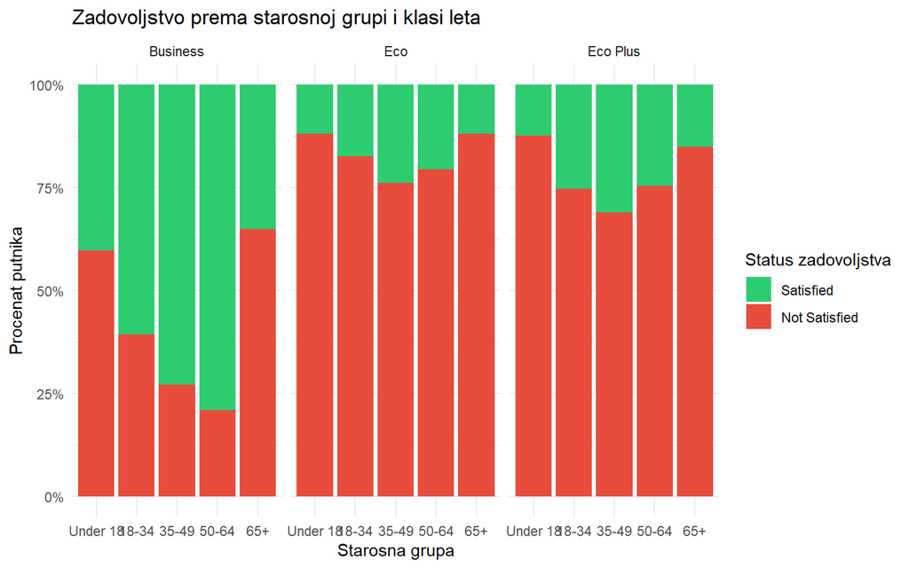

```r
ggplot(
  age_class_satisfaction,
  aes(
    x = Age_Group,
    y = Procenat,
    fill = Satisfaction
  )
) +
  geom_col(position = "fill") +
  facet_wrap(~ Class) +
  scale_y_continuous(labels = scales::percent_format()) +
  scale_fill_manual(
    values = c(
      "Satisfied" = "#2ecc71",
      "Not Satisfied" = "#e74c3c"
    )
  ) +
  theme_minimal() +
  labs(
    title = "Zadovoljstvo prema starosnoj grupi i klasi leta",
    x = "Starosna grupa",
    y = "Procenat putnika",
    fill = "Status zadovoljstva"
  )
```

```r
age_class_table <- table(
  data$Age_Group,
  data$Class,
  data$Satisfaction
)

age_class_chisq <- chisq.test(
  ftable(age_class_table),
  correct = FALSE
)

age_class_chisq
```

```
##
##  Pearson's Chi-squared test
##
## data:  ftable(age_class_table)
## X-squared = 36035, df = 14, p-value < 2.2e-16
```

Rezultati pokazuju da se zadovoljstvo putnika razlikuje prema kombinaciji starosne grupe i klase leta. U svim starosnim grupama poslovna klasa ima veći procenat zadovoljnih putnika u odnosu na Eco i Eco Plus klase.

Ovi rezultati ukazuju da se obrazac povezanosti starosti i zadovoljstva ne može posmatrati nezavisno od klase leta. Klasa leta je povezana sa nivoom zadovoljstva unutar svih starosnih grupa, dok se razlike između starosnih grupa menjaju u zavisnosti od klase.

Pearsonov hi-kvadrat test pokazuje statistički značajnu povezanost između kombinacije starosne grupe i klase leta i zadovoljstva putnika, χ²(14) = 36035, p < 0,001. Zbog toga odbacujemo nultu hipotezu o nezavisnosti.

Ipak, test ne dokazuje uzročno-posledičnu vezu niti samostalno potvrđuje formalnu interakciju između starosne grupe i klase. On pokazuje da se raspodela zadovoljstva značajno razlikuje između posmatranih kombinacija kategorija. Kombinacije ekstrema (poput mlađih od 18 i starijih od 65 godina u kombinaciji sa ređe zastupljenom klasom Eco Plus) obuhvataju mali broj opservacija u koloni Broj, zbog čega su procene unutar tih specifičnih grupa podložnije većoj varijabilnosti i manje pouzdane.

### Zadovoljstvo prema kombinaciji dužine leta i klase

U prethodnoj analizi uočeno je da se zadovoljstvo razlikuje između kategorija dužine leta, pri čemu su putnici na dugim letovima u proseku zadovoljniji. Takođe je utvrđeno da se zadovoljstvo značajno razlikuje između klasa leta.

Zbog toga ćemo proveriti da li se razlike u zadovoljstvu između kratkih, srednjih i dugih letova održavaju unutar svake klase. Na taj način možemo ispitati da li je uočeno veće zadovoljstvo na dugim letovima povezano sa samom dužinom leta ili je delimično posledica različite zastupljenosti klasa leta.

```r
distance_class_satisfaction <- data %>%
  count(Flight_Distance_Category, Class, Satisfaction, name = "Broj") %>%
  group_by(Flight_Distance_Category, Class) %>%
  mutate(Procenat = round(Broj / sum(Broj) * 100, 2)) %>%
  ungroup()

distance_class_satisfaction
```

```
## # A tibble: 18 × 5
##    Flight_Distance_Category Class    Satisfaction   Broj Procenat
##    <ord>                    <fct>    <fct>         <int>    <dbl>
##  1 Short                    Business Satisfied      7501     59.2
##  2 Short                    Business Not Satisfied  5161     40.8
##  3 Short                    Eco      Satisfied      4939     20.9
##  4 Short                    Eco      Not Satisfied 18708     79.1
##  5 Short                    Eco Plus Satisfied      1077     27.2
##  6 Short                    Eco Plus Not Satisfied  2890     72.8
##  7 Medium                   Business Satisfied     10661     64.3
##  8 Medium                   Business Not Satisfied  5929     35.7
##  9 Medium                   Eco      Satisfied      5198     17.8
## 10 Medium                   Eco      Not Satisfied 24008     82.2
## 11 Medium                   Eco Plus Satisfied      1063     23.9
## 12 Medium                   Eco Plus Not Satisfied  3393     76.1
## 13 Long                     Business Satisfied     25004     76.0
## 14 Long                     Business Not Satisfied  7904     24.0
## 15 Long                     Eco      Satisfied       806     14.8
## 16 Long                     Eco      Not Satisfied  4650     85.2
## 17 Long                     Eco Plus Satisfied       179     18.1
## 18 Long                     Eco Plus Not Satisfied   809     81.9
```

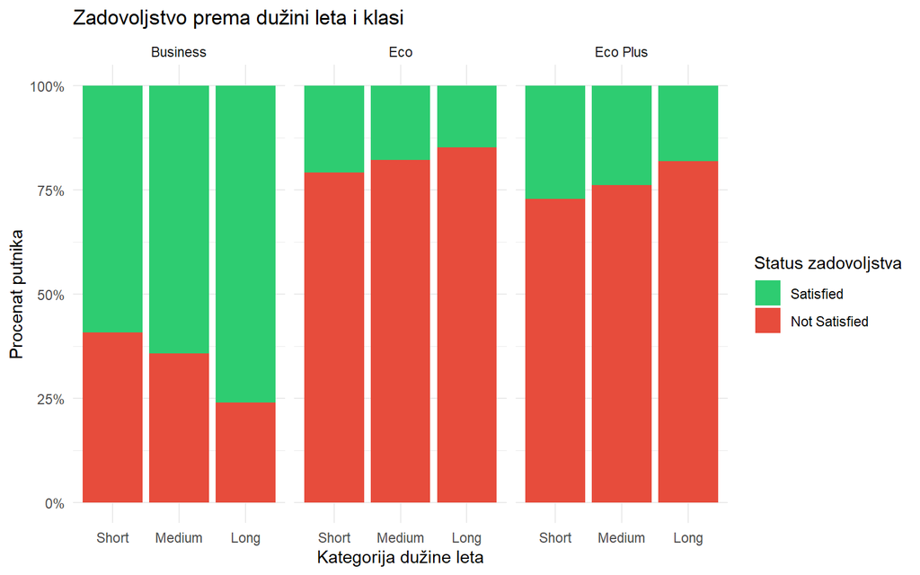

```r
ggplot(
  distance_class_satisfaction,
  aes(
    x = Flight_Distance_Category,
    y = Procenat,
    fill = Satisfaction
  )
) +
  geom_col(position = "fill") +
  facet_wrap(~ Class) +
  scale_y_continuous(labels = scales::percent_format()) +
  scale_fill_manual(
    values = c(
      "Satisfied" = "#2ecc71",
      "Not Satisfied" = "#e74c3c"
    )
  ) +
  theme_minimal() +
  labs(
    title = "Zadovoljstvo prema dužini leta i klasi",
    x = "Kategorija dužine leta",
    y = "Procenat putnika",
    fill = "Status zadovoljstva"
  )
```

```r
distance_class_table <- table(
  data$Flight_Distance_Category,
  data$Class,
  data$Satisfaction
)

distance_class_chisq <- chisq.test(
  ftable(distance_class_table),
  correct = FALSE
)

distance_class_chisq
```

```
##
##  Pearson's Chi-squared test
##
## data:  ftable(distance_class_table)
## X-squared = 34315, df = 8, p-value < 2.2e-16
```

Rezultati pokazuju da se odnos između dužine leta i zadovoljstva razlikuje u zavisnosti od klase leta. U poslovnoj klasi procenat zadovoljnih putnika raste sa dužinom leta: 59,2% kod kratkih, 64,3% kod srednjih i 76,0% kod dugih letova.

Kod ekonomske klase uočava se suprotan obrazac. Procenat zadovoljnih iznosi 20,9% kod kratkih, 17,8% kod srednjih i 14,8% kod dugih letova. Sličan obrazac postoji i u klasi Eco Plus, gde procenat zadovoljnih opada sa 27,2% kod kratkih na 18,1% kod dugih letova.

Ovi rezultati pokazuju da se veće zadovoljstvo kod dugih letova, uočeno u bivarijantnoj analizi, ne održava jednako u svim klasama. Ono je naročito izraženo u poslovnoj klasi, dok se u ekonomskim klasama procenat zadovoljnih putnika smanjuje sa dužinom leta. Zbog toga ukupna povezanost dužine leta sa zadovoljstvom može biti delimično posledica različite strukture putnika po klasama leta.

Pearsonov hi-kvadrat test pokazuje statistički značajnu povezanost između kombinacije kategorije dužine leta i klase i zadovoljstva putnika, χ²(8) = 34315, p < 0,001. Zbog toga odbacujemo nultu hipotezu o nezavisnosti.

Dobijeni rezultat ne dokazuje uzročno-posledičnu vezu niti samostalno potvrđuje formalnu interakciju između dužine leta i klase. Takođe treba imati u vidu da je klasa Eco Plus manje zastupljena, pa rezultate za ovu grupu treba tumačiti opreznije.

## Zaključak analize kategorijskih kombinacija

U ovoj analizi ispitano je da li se zadovoljstvo putnika razlikuje prema kombinacijama važnih kategorijskih promenljivih. Posmatrane su kombinacije klase i svrhe putovanja, tipa korisnika i svrhe putovanja, starosne grupe i klase, kao i kategorije dužine leta i klase.

Rezultati pokazuju da se zadovoljstvo ne može potpuno objasniti posmatranjem samo jedne promenljive. Klasa leta i svrha putovanja imaju posebno izražen značaj, ali se njihov odnos sa zadovoljstvom menja u zavisnosti od druge karakteristike putnika ili leta.

Kod poslovnih putovanja poslovna klasa ima najveći procenat zadovoljnih putnika, dok su kod ličnih putovanja procenti zadovoljnih niski u svim klasama. Lojalni korisnici su znatno zadovoljniji od dislojalnih kod poslovnih putovanja, dok je kod ličnih putovanja zadovoljstvo nisko kod obe grupe. Analiza starosnih grupa pokazuje da razlike između starosti nisu iste u svim klasama leta. Takođe, veće zadovoljstvo kod dugih letova uglavnom se održava u poslovnoj klasi, ali ne i u ekonomskim klasama.

Svi primenjeni hi-kvadrat testovi pokazali su statistički značajne povezanosti, uz nivo značajnosti p < 0,001. Međutim, zbog velikog broja opservacija statistička značajnost ne znači nužno veliku praktičnu važnost. Rezultati ukazuju na povezanost između posmatranih kombinacija kategorija i zadovoljstva, ali ne dokazuju uzročno-posledične veze.

Ovi nalazi predstavljaju osnovu za izbor promenljivih u daljoj multivarijantnoj analizi i izgradnji modela predikcije.

## Provera strukture ocena usluga (PCA)

Dosadašnje grupisanje 13 ocena u tri zbirne ocene (`Pre_Flight_Score`, `Comfort_Score`, `Service_Score`) predstavlja procenu autora. Da bismo proverili da li se ocene u podacima zaista grupišu na taj način, primenjujemo analizu glavnih komponenti (PCA). PCA pronalazi nove, međusobno nekorelisane promenljive (glavne komponente) koje redom objašnjavaju najveći deo varijanse polaznih promenljivih, dok koeficijenti (loadings) pokazuju koje se ocene zajedno kreću.

PCA ne dozvoljava nedostajuće vrednosti, a vrednost 0 označava neocenjenu uslugu. Zbog toga analizu sprovodimo nad putnicima koji su ocenili svih 13 usluga (`Not_Rated_Count == 0`), što čini 92,06% uzorka. Promenljive se pre analize standardizuju.

```r
pca_data <- data %>%
  filter(Not_Rated_Count == 0) %>%
  select(all_of(rating_columns))

nrow(pca_data)
```

```
## [1] 119567
```

```r
pca_result <- prcomp(pca_data, center = TRUE, scale. = TRUE)

# Udeo objašnjene varijanse (prvih 6 komponenti)
round(summary(pca_result)$importance[, 1:6], 3)
```

```
##                          PC1   PC2   PC3   PC4   PC5   PC6
## Standard deviation     1.918 1.570 1.332 1.003 0.964 0.814
## Proportion of Variance 0.283 0.190 0.136 0.077 0.072 0.051
## Cumulative Proportion  0.283 0.473 0.609 0.687 0.758 0.809
```

Analiza je sprovedena nad 119.567 putnika koji su ocenili svih 13 usluga. Prve tri glavne komponente zajedno objašnjavaju 60,9% ukupne varijanse (28,3%, 19,0% i 13,6%), a prvih šest komponenti 80,9%. Varijansa nije koncentrisana u jednoj komponenti, što pokazuje da ocene usluga ne mere jedan opšti utisak o usluzi, već nekoliko relativno odvojenih aspekata putovanja. Prema Kajzerovom kriterijumu (standardna devijacija veća od 1) zadržavaju se četiri komponente, pri čemu je četvrta tek na samoj granici (1,003).

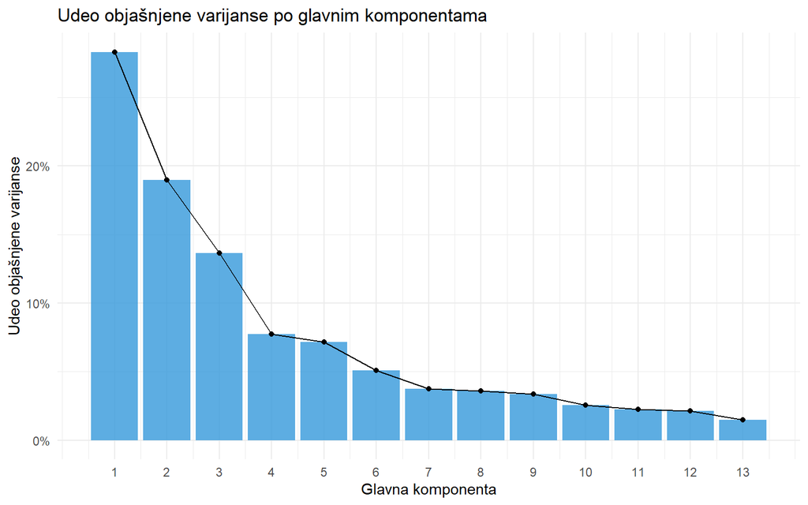

```r
# Scree plot
pca_var_df <- data.frame(
  Komponenta = seq_along(pca_result$sdev),
  Udeo = pca_result$sdev^2 / sum(pca_result$sdev^2)
)

ggplot(pca_var_df, aes(x = Komponenta, y = Udeo)) +
  geom_col(fill = "#3498db", alpha = 0.8) +
  geom_line() +
  geom_point() +
  scale_x_continuous(breaks = pca_var_df$Komponenta) +
  scale_y_continuous(labels = scales::percent_format()) +
  theme_minimal() +
  labs(
    title = "Udeo objašnjene varijanse po glavnim komponentama",
    x = "Glavna komponenta",
    y = "Udeo objašnjene varijanse"
  )
```

```r
# Koeficijenti (loadings) prvih četiri komponente
round(pca_result$rotation[, 1:4], 2)
```

```
##                                     PC1   PC2   PC3   PC4
## Inflight_wifi_service             -0.26  0.41  0.04  0.18
## Departure_Arrival_time_convenient -0.11  0.46 -0.02 -0.21
## Ease_of_Online_booking            -0.18  0.52  0.07  0.11
## Gate_location                     -0.09  0.46  0.08 -0.39
## Food_and_drink                    -0.34 -0.18  0.32 -0.22
## Online_boarding                   -0.32  0.08  0.09  0.61
## Seat_comfort                      -0.38 -0.18  0.25  0.03
## Inflight_entertainment            -0.43 -0.19 -0.01 -0.27
## On_board_service                  -0.24 -0.05 -0.49 -0.09
## Leg_room_service                  -0.20 -0.02 -0.42 -0.02
## Baggage_handling                  -0.22 -0.04 -0.52 -0.18
## Checkin_service                   -0.18 -0.03 -0.23  0.45
## Cleanliness                       -0.39 -0.19  0.26 -0.11
```

Predznak koeficijenata u PCA je proizvoljan, pa se tumače njihove apsolutne vrednosti i relativni odnos predznaka unutar iste komponente. Prva komponenta (28,3%) ima koeficijente istog predznaka kod svih ocena, što znači da opisuje opštu sklonost putnika da usluge ocenjuje više ili niže. Najveći doprinos imaju zabava na letu, čistoća, udobnost sedišta, hrana i piće i online ukrcavanje, dok je doprinos lokacije gejta i pogodnosti vremena polaska i dolaska najmanji.

Druga komponenta (19,0%) izdvaja ocene vezane za organizaciju putovanja: online rezervaciju (0,52), lokaciju gejta (0,46), pogodnost vremena polaska i dolaska (0,46) i WiFi (0,41). Uočava se da se WiFi grupiše sa rezervacijom, a ne sa ostalim uslugama tokom leta. Treća komponenta (13,6%) suprotstavlja uslugu osoblja, rukovanje prtljagom i prostor za noge (koeficijenti oko -0,4 do -0,5) sa hranom i pićem, udobnošću sedišta i čistoćom (koeficijenti oko 0,3). Četvrta komponenta (7,7%) izdvaja online ukrcavanje (0,61) i prijavu na let (0,45), odnosno digitalne korake pre leta.

### Rotirana struktura komponenti (varimax)

Koeficijenti glavnih komponenti često se teško tumače jer se jedna ocena pojavljuje u više komponenti. Varimax rotacija preraspoređuje koeficijente tako da svaka ocena što više pripada samo jednoj komponenti, što olakšava prepoznavanje grupa srodnih usluga. Rotaciju primenjujemo na prve četiri komponente, jer se na njima nalazi lom scree dijagrama.

```r
loadings_scaled <- pca_result$rotation[, 1:4] %*% diag(pca_result$sdev[1:4])
colnames(loadings_scaled) <- paste0("RC", 1:4)

rotated <- varimax(loadings_scaled)
round(unclass(rotated$loadings), 2)
```

```
##                                     RC1   RC2   RC3   RC4
## Inflight_wifi_service             -0.14  0.72 -0.07  0.40
## Departure_Arrival_time_convenient  0.05  0.77 -0.09 -0.06
## Ease_of_Online_booking             0.02  0.84  0.03  0.29
## Gate_location                     -0.02  0.81  0.01 -0.25
## Food_and_drink                    -0.85  0.03  0.03  0.00
## Online_boarding                   -0.33  0.19 -0.02  0.80
## Seat_comfort                      -0.81 -0.01 -0.04  0.26
## Inflight_entertainment            -0.80  0.03 -0.44  0.03
## On_board_service                  -0.10  0.02 -0.80  0.11
## Leg_room_service                  -0.05  0.04 -0.66  0.14
## Baggage_handling                  -0.06  0.04 -0.83  0.01
## Checkin_service                   -0.03 -0.06 -0.33  0.55
## Cleanliness                       -0.87  0.00 -0.06  0.13
```

Nakon varimax rotacije struktura je znatno jasnija: svaka ocena ima jedan dominantan koeficijent (u rasponu od 0,55 do 0,87 po apsolutnoj vrednosti), dok su ostali uglavnom mali. Negativan predznak kod prve i treće komponente je proizvoljan i ne utiče na tumačenje.

Prva komponenta (RC1) obuhvata čistoću (0,87), hranu i piće (0,85), udobnost sedišta (0,81) i zabavu na letu (0,80), odnosno doživljaj u kabini. Druga komponenta (RC2) obuhvata online rezervaciju (0,84), lokaciju gejta (0,81), pogodnost vremena polaska i dolaska (0,77) i WiFi (0,72), odnosno organizaciju i pristupačnost putovanja. Treća komponenta (RC3) obuhvata rukovanje prtljagom (0,83), uslugu osoblja (0,80) i prostor za noge (0,66), a četvrta (RC4) online ukrcavanje (0,80) i prijavu na let (0,55), odnosno digitalne korake pre leta. Pojedine ocene imaju i sekundarni koeficijent (npr. WiFi 0,40 na RC4 i zabava na letu 0,44 na RC3), pa granice između grupa nisu potpuno oštre.

U poređenju sa početnim grupisanjem, `Pre_Flight_Score` objedinjuje ocene koje se prema PCA nalaze u dve različite komponente (RC2 i RC4), `Comfort_Score` razdvaja udobnost sedišta i čistoću (RC1) od prostora za noge (RC3), a ocene u `Service_Score` raspoređene su na tri komponente. Početno grupisanje je, dakle, samo delimično potvrđeno.

### Zbirne ocene prema strukturi glavnih komponenti

Na osnovu rotirane strukture komponenti formiramo četiri nove zbirne ocene, koje zamenjuju prvobitno, intuitivno grupisanje iz dela o inženjeringu obeležja (`Pre_Flight_Score`, `Comfort_Score` i `Service_Score`). Od ovog trenutka u analizi koristimo nove ocene, a prvobitne ostaju u skupu podataka samo kao dokumentacija ranijeg koraka i ne koriste se zajedno sa novim ocenama.

Ocene grupišemo na sledeći način:

- **Cabin_Score** (doživljaj u kabini): čistoća, hrana i piće, udobnost sedišta, zabava na letu,
- **Booking_Score** (organizacija putovanja): online rezervacija, lokacija gejta, pogodnost vremena polaska i dolaska, WiFi,
- **Handling_Score** (osoblje i rukovanje): rukovanje prtljagom, usluga osoblja, prostor za noge,
- **Digital_Score** (digitalni koraci pre leta): online ukrcavanje, prijava na let.

Kao i ranije, vrednost 0 (neocenjena usluga) izostavljamo iz proseka. Grupe su određene na osnovu PCA, koja ukazuje na strukturu, ali ne dokazuje da su grupe jedine ispravne. Pojedine ocene imaju i sekundarna opterećenja, pa granice između grupa nisu potpuno oštre.

```r
cabin_cols    <- c("Cleanliness", "Food_and_drink", "Seat_comfort", "Inflight_entertainment")
booking_cols  <- c("Ease_of_Online_booking", "Gate_location",
                   "Departure_Arrival_time_convenient", "Inflight_wifi_service")
handling_cols <- c("Baggage_handling", "On_board_service", "Leg_room_service")
digital_cols  <- c("Online_boarding", "Checkin_service")

data <- data %>%
  mutate(
    Cabin_Score    = row_mean_rated(data, cabin_cols),
    Booking_Score  = row_mean_rated(data, booking_cols),
    Handling_Score = row_mean_rated(data, handling_cols),
    Digital_Score  = row_mean_rated(data, digital_cols)
  )

summary(data %>% select(Cabin_Score, Booking_Score, Handling_Score, Digital_Score))
```

```
##   Cabin_Score    Booking_Score   Handling_Score  Digital_Score
##  Min.   :1.000   Min.   :1.000   Min.   :1.000   Min.   :1.00
##  1st Qu.:2.500   1st Qu.:2.250   1st Qu.:2.667   1st Qu.:2.50
##  Median :3.500   Median :3.000   Median :3.667   Median :3.50
##  Mean   :3.324   Mean   :2.972   Mean   :3.460   Mean   :3.32
##  3rd Qu.:4.000   3rd Qu.:3.750   3rd Qu.:4.000   3rd Qu.:4.00
##  Max.   :5.000   Max.   :5.000   Max.   :5.000   Max.   :5.00
```

Da bismo ispitali da li se nove zbirne ocene razlikuju između zadovoljnih i nezadovoljnih putnika, prikazaćemo uporedne boxplot dijagrame, a zatim i prosečne ocene po grupama zadovoljstva.

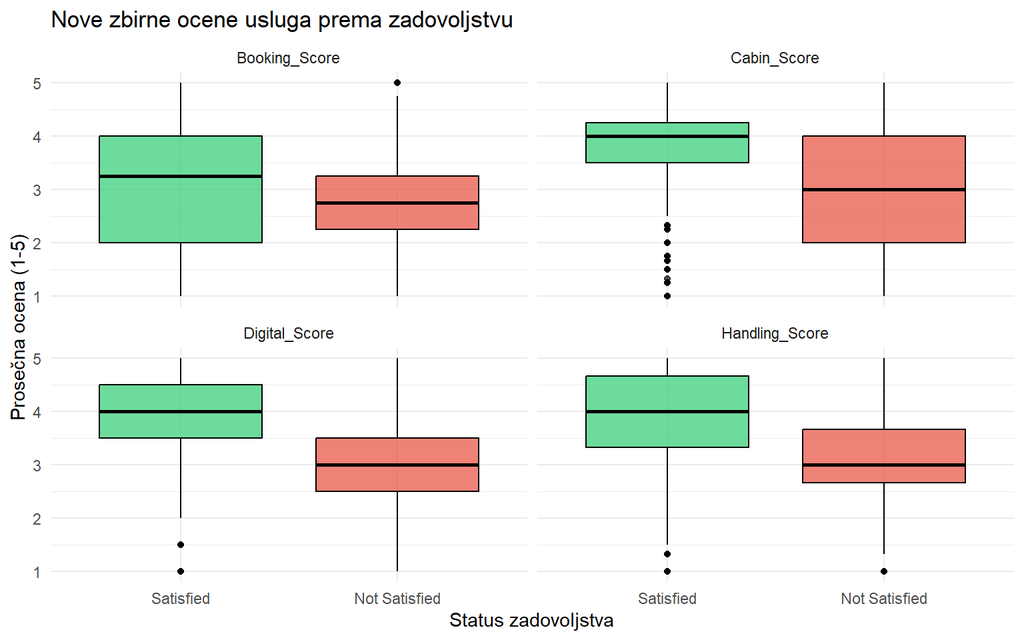

```r
data %>%
  select(Satisfaction, Cabin_Score, Booking_Score, Handling_Score, Digital_Score) %>%
  pivot_longer(-Satisfaction, names_to = "Grupa", values_to = "Ocena") %>%
  ggplot(aes(x = Satisfaction, y = Ocena, fill = Satisfaction)) +
  geom_boxplot(alpha = 0.7, color = "black") +
  facet_wrap(~ Grupa, ncol = 2) +
  scale_fill_manual(
    values = c("Satisfied" = "#2ecc71", "Not Satisfied" = "#e74c3c")
  ) +
  theme_minimal() +
  labs(
    title = "Nove zbirne ocene usluga prema zadovoljstvu",
    x = "Status zadovoljstva",
    y = "Prosečna ocena (1-5)"
  ) +
  theme(legend.position = "none")
```

```r
data %>%
  group_by(Satisfaction) %>%
  summarise(
    Cabin    = round(mean(Cabin_Score), 2),
    Booking  = round(mean(Booking_Score), 2),
    Handling = round(mean(Handling_Score), 2),
    Digital  = round(mean(Digital_Score), 2)
  )
```

```
## # A tibble: 2 × 5
##   Satisfaction  Cabin Booking Handling Digital
##   <fct>         <dbl>   <dbl>    <dbl>   <dbl>
## 1 Satisfied      3.8     3.18     3.88    3.89
## 2 Not Satisfied  2.96    2.81     3.13    2.88
```

Sve četiri zbirne ocene su u proseku više kod zadovoljnih nego kod nezadovoljnih putnika, ali se razlike među grupama jasno razlikuju. Najveća razlika uočava se kod digitalnih koraka pre leta (`Digital_Score`: 3,89 naspram 2,88, razlika 1,01), zatim kod doživljaja u kabini (`Cabin_Score`: 3,80 naspram 2,96, razlika 0,84) i osoblja i rukovanja (`Handling_Score`: 3,88 naspram 3,13, razlika 0,75). Kod ove tri grupe medijana zadovoljnih putnika iznosi oko 4, a nezadovoljnih oko 3. Kod organizacije putovanja (`Booking_Score`) razlika je najmanja (3,18 naspram 2,81, razlika 0,37), medijane su blizu (oko 3,25 i 2,75), a kutije se u velikoj meri preklapaju, pa ova grupa najslabije razdvaja dve kategorije putnika. Kod nezadovoljnih putnika `Cabin_Score` ima najširi interkvartilni opseg (od 2 do 4), dok je kod zadovoljnih sužen oko visokih ocena, uz pojedinačne niske vrednosti ispod kutije.

Ovi rezultati su u skladu sa ranijim nalazom da priprema pre leta slabije razdvaja zadovoljne od nezadovoljnih. Treba imati u vidu da `Digital_Score` čine samo dve ocene, pa je osetljiviji na pojedinačne vrednosti od ostalih grupa. Razlike u prosecima su povezanost, a ne dokaz uticaja, i mogu delimično biti posledica klase leta i svrhe putovanja, što proveravamo u narednom koraku.

### Zbirne ocene prema klasi i svrsi putovanja

U prethodnom koraku uočili smo da se zbirne ocene razlikuju između zadovoljnih i nezadovoljnih putnika. Međutim, klasa leta i svrha putovanja snažno su povezane sa zadovoljstvom (V = 0,503 i V = 0,450), pa je moguće da deo ove razlike potiče upravo od njih. Zbog toga prvo prikazujemo prosečne ocene za svaku kombinaciju klase i svrhe putovanja, a zatim proveravamo da li se razlika između zadovoljnih i nezadovoljnih putnika održava unutar svake kombinacije.

```r
data %>%
  group_by(Class, Type_of_Travel) %>%
  summarise(
    Broj     = n(),
    Cabin    = round(mean(Cabin_Score), 2),
    Booking  = round(mean(Booking_Score), 2),
    Handling = round(mean(Handling_Score), 2),
    Digital  = round(mean(Digital_Score), 2),
    .groups = "drop"
  )
```

```
## # A tibble: 6 × 7
##   Class    Type_of_Travel   Broj Cabin Booking Handling Digital
##   <fct>    <fct>           <int> <dbl>   <dbl>    <dbl>   <dbl>
## 1 Business Business Travel 59487  3.57    2.99     3.75    3.66
## 2 Business Personal Travel  2673  3.21    2.99     3.14    3.32
## 3 Eco      Business Travel 25304  3.12    2.93     3.08    2.9
## 4 Eco      Personal Travel 33005  3.1     2.97     3.33    3.13
## 5 Eco Plus Business Travel  4902  3.15    3        3       2.91
## 6 Eco Plus Personal Travel  4509  3.11    2.95     3.32    3.12
```

Prosečne ocene razlikuju se između segmenata uglavnom zbog jedne kombinacije: putnici u poslovnoj klasi na poslovnim putovanjima (59.487 putnika) daju najviše ocene za kabinu (3,57), osoblje i rukovanje (3,75) i digitalne korake (3,66). U ostalim segmentima te ocene su niže i međusobno slične (kabina oko 3,1 do 3,2). Poslovna klasa na ličnim putovanjima ima ocenu kabine (3,21) gotovo istu kao Eco klasa (3,10), što pokazuje da viša ocena kabine nije svojstvo poslovne klase same po sebi. Ocena organizacije putovanja (`Booking`) gotovo se ne menja između segmenata (od 2,93 do 3,00). U ekonomskim klasama putnici na ličnim putovanjima ocenjuju osoblje i rukovanje (3,32 do 3,33) i digitalne korake (oko 3,1) više nego na poslovnim (3,00 do 3,08 i oko 2,9).

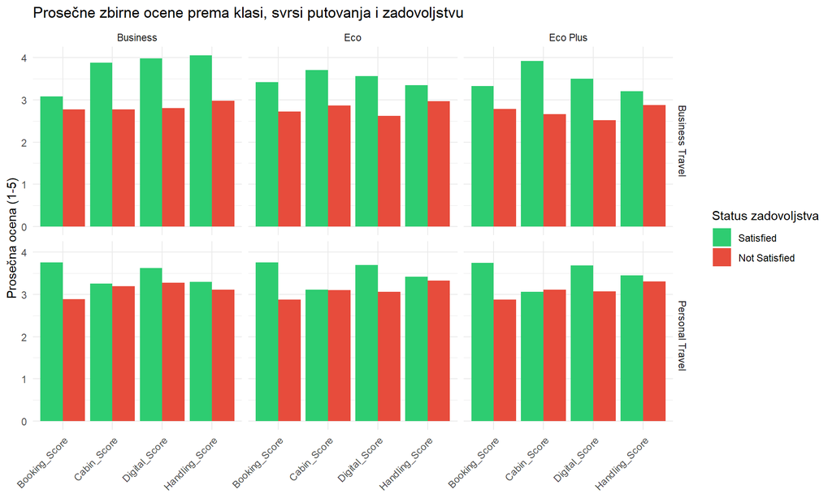

```r
data %>%
  select(Class, Type_of_Travel, Satisfaction,
         Cabin_Score, Booking_Score, Handling_Score, Digital_Score) %>%
  pivot_longer(ends_with("_Score"), names_to = "Grupa", values_to = "Ocena") %>%
  group_by(Class, Type_of_Travel, Satisfaction, Grupa) %>%
  summarise(Prosek = mean(Ocena), .groups = "drop") %>%
  ggplot(aes(x = Grupa, y = Prosek, fill = Satisfaction)) +
  geom_col(position = "dodge") +
  facet_grid(Type_of_Travel ~ Class) +
  scale_fill_manual(
    values = c("Satisfied" = "#2ecc71", "Not Satisfied" = "#e74c3c")
  ) +
  theme_minimal() +
  theme(axis.text.x = element_text(angle = 45, hjust = 1)) +
  labs(
    title = "Prosečne zbirne ocene prema klasi, svrsi putovanja i zadovoljstvu",
    x = NULL,
    y = "Prosečna ocena (1-5)",
    fill = "Status zadovoljstva"
  )
```

Na poslovnim putovanjima (gornji red) zadovoljni putnici u sve tri klase imaju više ocene u svim grupama. Razlike su najveće kod kabine, digitalnih koraka i osoblja i rukovanja (u poslovnoj klasi oko 0,8 do 1,2 poena), a najmanje kod organizacije putovanja. Na ličnim putovanjima (donji red) slika je drugačija: razlika kod kabine i osoblja i rukovanja gotovo nestaje (u klasi Eco Plus ocena kabine je čak neznatno viša kod nezadovoljnih), dok se razlika zadržava kod organizacije putovanja (oko 0,9 poena) i digitalnih koraka (oko 0,4 do 0,6 poena).

Prema tome, usluge povezane sa zadovoljstvom zavise od svrhe putovanja: kod poslovnih putnika to su kabina, digitalni koraci i osoblje, a kod putnika na ličnim putovanjima organizacija putovanja i digitalni koraci. To može objasniti zašto je organizacija putovanja u ukupnom poređenju najslabije razdvajala zadovoljne od nezadovoljnih, jer se njena veza sa zadovoljstvom u ukupnom prosečnom poređenju delimično gubi. Grupu poslovne klase na ličnim putovanjima čini samo 2.673 putnika, pa je treba tumačiti opreznije.

## Multikolinearnost: probni logistički model i VIF

Pre izgradnje konačnih modela proveravamo da li među kandidatima za ulazne promenljive postoji multikolinearnost, odnosno da li neke promenljive nose gotovo istu informaciju. Za to koristimo probni logistički model sa svim kandidatima i faktor povećanja varijanse (VIF). VIF pokazuje koliko je varijansa procene koeficijenta povećana zbog povezanosti date promenljive sa ostalim promenljivama. Prema uobičajenoj preporuci, vrednosti iznad 5 ukazuju na umerenu, a iznad 10 na ozbiljnu multikolinearnost. Kod kategorijskih promenljivih VIF se računa za svaku indikatorsku (dummy) kolonu posebno, pri čemu su kolone iste promenljive (npr. `ClassEco` i `ClassEco Plus`) po prirodi međusobno povezane, pa njihove umereno više vrednosti treba tumačiti oprezno.

U model ulaze starost i dužina leta u originalnom, numeričkom obliku (njihove kategorije su izvedene iz njih), kašnjenje pri polasku i kašnjenje pri dolasku, kao i četiri nove zbirne ocene. Promenljiva `Delay_Difference` ne ulazi u model jer je tačna linearna kombinacija dva kašnjenja, pa bi izazvala savršenu multikolinearnost. Prvobitne tri zbirne ocene takođe ne ulaze, jer se računaju iz istih ocena kao nove. Ciljna promenljiva se kodira kao 1 za zadovoljne putnike, da bi se pozitivan koeficijent tumačio kao veća šansa za zadovoljstvo.

```r
model_data <- data %>%
  mutate(Satisfied_Num = as.integer(Satisfaction == "Satisfied"))

full_model <- glm(
  Satisfied_Num ~ Gender + Customer_Type + Type_of_Travel + Class +
    Age + Flight_Distance +
    Departure_Delay_in_Minutes + Arrival_Delay_in_Minutes +
    Cabin_Score + Booking_Score + Handling_Score + Digital_Score,
  data = model_data,
  family = binomial
)

x_matrix <- model.matrix(full_model)[, -1]   # matrica prediktora bez konstantnog člana

vif_values <- diag(solve(cor(x_matrix)))
round(sort(vif_values, decreasing = TRUE), 2)
```

```
##      Arrival_Delay_in_Minutes    Departure_Delay_in_Minutes
##                         14.82                         14.82
##                      ClassEco Type_of_TravelPersonal Travel
##                          2.07                          1.85
##   Customer_TypeLoyal Customer               Flight_Distance
##                          1.47                          1.36
##                 Digital_Score                 ClassEco Plus
##                          1.32                          1.28
##                   Cabin_Score                Handling_Score
##                          1.19                          1.16
##                           Age                 Booking_Score
##                          1.12                          1.05
##                    GenderMale
##                          1.00
```

Rezultati pokazuju da je multikolinearnost prisutna samo kod dve promenljive: kašnjenje pri dolasku (VIF = 14,82) i kašnjenje pri polasku (VIF = 14,82) imaju vrednosti veće od 10, što potvrđuje da nose gotovo istu informaciju, u skladu sa ranije utvrđenom korelacijom od 0,966. Sve ostale promenljive imaju VIF ispod 2,1, pa među njima ne postoji problem multikolinearnosti. Četiri nove zbirne ocene imaju vrednosti od 1,05 do 1,32, što znači da su međusobno dovoljno nezavisne da se koriste zajedno u modelu. Nešto više vrednosti kod `ClassEco` (2,07) i `Type_of_TravelPersonal Travel` (1,85) u skladu su sa povezanošću klase i svrhe putovanja utvrđenom u prethodnom delu analize, ali su daleko ispod granice od 5.

### Rešavanje multikolinearnosti kašnjenja

Pošto kašnjenja pri polasku i dolasku ne smeju ući u model zajedno, poredimo tri načina da se informacija o kašnjenju predstavi: (1) kašnjenje pri polasku zajedno sa razlikom `Delay_Difference`, (2) samo kašnjenje pri polasku i (3) samo kašnjenje pri dolasku. Prvi način sadrži istu informaciju kao polazni model sa oba kašnjenja, jer je kašnjenje pri dolasku zbir kašnjenja pri polasku i razlike, ali bez multikolinearnosti. Modele poredimo Akaikeovim informacionim kriterijumom (AIC), kod koga je manja vrednost bolja, a razlika veća od oko 10 uobičajeno se smatra jasnom.

```r
model_dep_diff <- glm(
  Satisfied_Num ~ Gender + Customer_Type + Type_of_Travel + Class +
    Age + Flight_Distance +
    Departure_Delay_in_Minutes + Delay_Difference +
    Cabin_Score + Booking_Score + Handling_Score + Digital_Score,
  data = model_data,
  family = binomial
)

model_dep_only <- update(model_dep_diff, . ~ . - Delay_Difference)
model_arr_only <- update(full_model, . ~ . - Departure_Delay_in_Minutes)

# VIF za model sa kašnjenjem pri polasku i razlikom
x_matrix_2 <- model.matrix(model_dep_diff)[, -1]
round(sort(diag(solve(cor(x_matrix_2))), decreasing = TRUE), 2)
```

```
##                      ClassEco Type_of_TravelPersonal Travel
##                          2.07                          1.85
##   Customer_TypeLoyal Customer               Flight_Distance
##                          1.47                          1.36
##                 Digital_Score                 ClassEco Plus
##                          1.32                          1.28
##                   Cabin_Score                Handling_Score
##                          1.19                          1.16
##                           Age                 Booking_Score
##                          1.12                          1.05
##    Departure_Delay_in_Minutes              Delay_Difference
##                          1.01                          1.01
##                    GenderMale
##                          1.00
```

```r
# Poređenje modela
AIC(full_model, model_dep_diff, model_dep_only, model_arr_only)
```

```
##                df      AIC
## full_model     14 84057.03
## model_dep_diff 14 84057.03
## model_dep_only 13 84157.68
## model_arr_only 13 84072.83
```

Model sa kašnjenjem pri polasku i razlikom (Delay_Difference) ima isti AIC (84.057,03) kao model sa kašnjenjem pri polasku i dolasku. Model samo sa kašnjenjem pri polasku ima AIC 84.157,68, odnosno oko 100,65 više, dok model samo sa kašnjenjem pri dolasku ima AIC 84.072,83, odnosno oko 15,80 više. Zato model sa polaznim kašnjenjem i razlikom zadržava informaciju o oba kašnjenja bez njihove multikolinearnosti. Po AIC-u je bolji od modela koji koristi samo jedno kašnjenje.

U modelovanju koristimo kašnjenje pri polasku zajedno sa razlikom `Delay_Difference`, jer taj par čuva informacije oba kašnjenja bez multikolinearnosti. Kašnjenje pri dolasku ne koristimo istovremeno sa njima.

## Provera interakcije klase i svrhe putovanja

U prethodnom delu analize uočeno je da se razlika između klasa leta ne ponaša isto kod poslovnih i kod ličnih putovanja: kod poslovnih putovanja zadovoljstvo se jako razlikuje između klasa, dok je kod ličnih nisko u svim klasama. Hi-kvadrat test nad kombinovanom kategorijom pokazuje samo da su raspodele zadovoljstva različite između kombinacija, ali ne ispituje direktno da li se uticaj klase menja u zavisnosti od svrhe putovanja. Zbog toga poredimo dva logistička modela, jedan bez i jedan sa članom interakcije `Class × Type_of_Travel`, testom odnosa verodostojnosti (likelihood ratio test). Nulta hipoteza glasi da je uticaj klase na šansu za zadovoljstvo isti kod poslovnih i ličnih putovanja.

Test se sprovodi na dva načina: bez prilagođavanja (samo klasa i svrha putovanja) i uz prilagođavanje ostalim promenljivama.

```r
# 1. Bez prilagođavanja
m_main <- glm(Satisfied_Num ~ Class + Type_of_Travel,
              data = model_data, family = binomial)
m_int  <- glm(Satisfied_Num ~ Class * Type_of_Travel,
              data = model_data, family = binomial)

anova(m_main, m_int, test = "Chisq")
```

```
## Analysis of Deviance Table
##
## Model 1: Satisfied_Num ~ Class + Type_of_Travel
## Model 2: Satisfied_Num ~ Class * Type_of_Travel
##   Resid. Df Resid. Dev Df Deviance  Pr(>Chi)
## 1    129876     135157
## 2    129874     134309  2   848.26 < 2.2e-16 ***
## ---
## Signif. codes:  0 '***' 0.001 '**' 0.01 '*' 0.05 '.' 0.1 ' ' 1
```

```r
# 2. Uz prilagođavanje ostalim promenljivama
m_main_adj <- glm(
  Satisfied_Num ~ Class + Type_of_Travel + Gender + Customer_Type +
    Age + Flight_Distance + Departure_Delay_in_Minutes + Delay_Difference +
    Cabin_Score + Booking_Score + Handling_Score + Digital_Score,
  data = model_data, family = binomial
)
m_int_adj <- update(m_main_adj, . ~ . + Class:Type_of_Travel)

anova(m_main_adj, m_int_adj, test = "Chisq")
```

```
## Analysis of Deviance Table
##
## Model 1: Satisfied_Num ~ Class + Type_of_Travel + Gender + Customer_Type +
##     Age + Flight_Distance + Departure_Delay_in_Minutes + Delay_Difference +
##     Cabin_Score + Booking_Score + Handling_Score + Digital_Score
## Model 2: Satisfied_Num ~ Class + Type_of_Travel + Gender + Customer_Type +
##     Age + Flight_Distance + Departure_Delay_in_Minutes + Delay_Difference +
##     Cabin_Score + Booking_Score + Handling_Score + Digital_Score +
##     Class:Type_of_Travel
##   Resid. Df Resid. Dev Df Deviance  Pr(>Chi)
## 1    129866      84029
## 2    129864      83973  2   56.207 6.235e-13 ***
## ---
## Signif. codes:  0 '***' 0.001 '**' 0.01 '*' 0.05 '.' 0.1 ' ' 1
```

Zbog velikog broja opservacija test će gotovo sigurno biti značajan, pa je važnija veličina efekta. Zato računamo i šansu (odds) za zadovoljstvo u svakoj klasi u odnosu na Eco klasu, posebno za svaku svrhu putovanja.

```r
model_data %>%
  group_by(Type_of_Travel, Class) %>%
  summarise(p = mean(Satisfied_Num), .groups = "drop") %>%
  mutate(odds = p / (1 - p)) %>%
  group_by(Type_of_Travel) %>%
  mutate(
    Procenat_zadovoljnih = round(p * 100, 1),
    Sansa_naspram_Eco = round(odds / odds[Class == "Eco"], 2)
  ) %>%
  ungroup() %>%
  select(Type_of_Travel, Class, Procenat_zadovoljnih, Sansa_naspram_Eco)
```

```
## # A tibble: 6 × 4
##   Type_of_Travel  Class    Procenat_zadovoljnih Sansa_naspram_Eco
##   <fct>           <fct>                   <dbl>             <dbl>
## 1 Business Travel Business                 72                6.03
## 2 Business Travel Eco                      29.9              1
## 3 Business Travel Eco Plus                 39.3              1.51
## 4 Personal Travel Business                 11.7              1.17
## 5 Personal Travel Eco                      10.2              1
## 6 Personal Travel Eco Plus                  8.7              0.84
```

## Izbor promenljivih za modelovanje

Na osnovu rezultata multivarijantne analize definišemo skup promenljivih koji ulazi u modelovanje.

| Promenljiva | Odluka | Obrazloženje |
| --- | --- | --- |
| `Class` | Zadržava se (nominalna) | Jaka povezanost sa zadovoljstvom (V = 0,503). Uticaj zavisi od svrhe putovanja, pa se u logističkoj regresiji uključuje i interakcija sa `Type_of_Travel`. |
| `Type_of_Travel` | Zadržava se | Jaka povezanost sa zadovoljstvom (V = 0,450). VIF je nizak (1,85). |
| `Customer_Type` | Zadržava se | Umerena povezanost sa zadovoljstvom (V = 0,186), VIF 1,47. |
| `Gender` | Zadržava se za sada | Veoma slaba povezanost sa zadovoljstvom (V = 0,011), VIF 1,00. Važnost se proverava u modelu. |
| `Age`, `Flight_Distance` | Zadržavaju se u numeričkom obliku | Veza starosti sa zadovoljstvom ima oblik slova U, pa je za logističku regresiju moguće bolje koristiti `Age_Group`. O tome se odlučuje u fazi modelovanja. |
| `Departure_Delay_in_Minutes` i `Delay_Difference` | Zadržavaju se | Kašnjenja pri polasku i dolasku imaju VIF veći od 12. Par polazak + razlika sadrži istu informaciju bez multikolinearnosti i ima znatno niži AIC nego samo polazak. |
| `Arrival_Delay_in_Minutes` | Ne koristi se uz prethodne | Zbir kašnjenja pri polasku i razlike, pa izaziva multikolinearnost. |
| `Cabin_Score`, `Booking_Score`, `Handling_Score`, `Digital_Score` | Zadržavaju se | Određene na osnovu PCA, VIF od 1,05 do 1,32. Pri poređenju modela mogu se uporediti i sa 13 pojedinačnih ocena. |
| `Pre_Flight_Score`, `Comfort_Score`, `Service_Score` | Ne koriste se | Zamenjene novim ocenama iz PCA. |
| `Not_Rated_Count` | Kandidat | Veza sa zadovoljstvom nije linearna, pa se njena korisnost proverava u modelu. |
| Kategorije kašnjenja, `Age_Group`, `Flight_Distance_Category`, `Class_Ordered` | Ne koriste se zajedno sa originalnim oblikom | Izvedene su iz promenljivih koje su već u skupu i služe za interpretaciju. |

## Zaključak: ocene usluga, multikolinearnost i izbor promenljivih

Analiza glavnih komponenti pokazala je da se 13 ocena usluga grupiše u četiri komponente (zajedno objašnjavaju 68,7% varijanse), koje odgovaraju doživljaju u kabini, organizaciji putovanja, osoblju i rukovanju i digitalnim koracima pre leta. Prvobitno intuitivno grupisanje samo je delimično potvrđeno, pa su formirane četiri nove zbirne ocene. Digitalni koraci najviše razdvajaju zadovoljne od nezadovoljnih putnika (razlika prosečnih ocena 1,01), a organizacija putovanja najmanje (0,37). Poređenje po segmentima pokazalo je da se ova slika razlikuje prema svrsi putovanja: kod poslovnih putnika važne su kabina, digitalni koraci i osoblje, a kod putnika na ličnim putovanjima organizacija putovanja i digitalni koraci.

Provera multikolinearnosti pokazala je da je problem samo odnos kašnjenja pri polasku i dolasku (VIF veći od 12), koji se rešava korišćenjem kašnjenja pri polasku zajedno sa razlikom `Delay_Difference`. Interakcija klase i svrhe putovanja je značajna i bez i uz prilagođavanje ostalim promenljivama: klasa je jako povezana sa zadovoljstvom kod poslovnih putovanja (šansa 6,03 puta veća u poslovnoj klasi nego u Eco klasi), a kod ličnih putovanja gotovo nije (1,17). Svi rezultati opisuju povezanost u posmatranom skupu podataka i ne dokazuju uzročno-posledične veze. Izabrane promenljive koriste se u narednoj fazi, izgradnji i evaluaciji modela mašinskog učenja.

# Priprema za modelovanje

U prethodnim poglavljima ispitani su obrasci u podacima i definisan je skup promenljivih koje ulaze u modelovanje. U ovom poglavlju te promenljive objedinjujemo u jedan skup podataka, delimo ga na trening i test skup i pripremamo zajednički postupak evaluacije, kako bi svi modeli bili upoređeni pod istim uslovima.

## Skup promenljivih za modelovanje

Skup za modelovanje sadrži ciljnu promenljivu i sve promenljive koje su u multivarijantnoj analizi zadržane kao kandidati:

- karakteristike putnika i leta: `Gender`, `Customer_Type`, `Type_of_Travel`, `Class`, `Age`, `Flight_Distance`,
- kašnjenja: `Departure_Delay_in_Minutes` i `Delay_Difference` (par koji čuva informaciju o oba kašnjenja bez multikolinearnosti),
- 13 pojedinačnih ocena usluga,
- četiri zbirne ocene dobijene na osnovu PCA (`Cabin_Score`, `Booking_Score`, `Handling_Score`, `Digital_Score`),
- `Not_Rated_Count`.

Pojedinačne i zbirne ocene nose istu informaciju, pa nikada ne ulaze zajedno u isti model. Umesto da se jedna varijanta bira unapred, u skup su uključene obe, a svaki model koristi samo jednu od njih. Na taj način se rezultati modela sa pojedinačnim i modela sa zbirnim ocenama mogu direktno porediti. Ne koriste se `Arrival_Delay_in_Minutes` (izaziva multikolinearnost sa kašnjenjem pri polasku i razlikom), prvobitne tri zbirne ocene (zamenjene novim) i kategorije izvedene iz postojećih promenljivih (`Age_Group`, `Flight_Distance_Category`, `Class_Ordered`, kategorije kašnjenja).

Ciljna promenljiva ostaje faktor `Satisfaction`, uz numeričku verziju `Satisfied_Num` (1 = zadovoljan) za modele koji zahtevaju numerički ishod. Kod promenljive `Class` kao referentni nivo postavljamo `Eco`, kako bi se koeficijenti u logističkoj regresiji tumačili u odnosu na ekonomsku klasu.

```r
modeling_data <- data %>%
  transmute(
    Satisfaction,
    Satisfied_Num = as.integer(Satisfaction == "Satisfied"),
    Gender, Customer_Type, Type_of_Travel,
    Class = relevel(Class, ref = "Eco"),
    Age, Flight_Distance,
    Departure_Delay_in_Minutes, Delay_Difference,
    across(all_of(rating_columns)),
    Cabin_Score, Booking_Score, Handling_Score, Digital_Score,
    Not_Rated_Count
  )

dim(modeling_data)
```

```
## [1] 129880     28
```

```r
sum(is.na(modeling_data))
```

```
## [1] 0
```

```r
levels(modeling_data$Class)
```

```
## [1] "Eco"      "Business" "Eco Plus"
```

```r
levels(modeling_data$Satisfaction)
```

```
## [1] "Satisfied"     "Not Satisfied"
```

Skup za modelovanje sadrži 129.880 opservacija i 28 promenljivih (ciljnu promenljivu u dva oblika, šest karakteristika putnika i leta, dva kašnjenja, 13 pojedinačnih ocena, četiri zbirne ocene i `Not_Rated_Count`) i nema nedostajućih vrednosti. Referentni nivo promenljive `Class` je `Eco` (nivoi su redom `Eco`, `Business`, `Eco Plus`), a prvi nivo ciljne promenljive je `Satisfied`.

## Podela na trening i test skup

Skup delimo na trening skup (80%), na kome se modeli grade i podešavaju, i test skup (20%), koji se koristi samo za konačnu evaluaciju. Podela je stratifikovana prema ciljnoj promenljivoj, što znači da se udeo zadovoljnih putnika (oko 43%) zadržava u oba skupa. Pre podele se postavlja početna vrednost generatora slučajnih brojeva (`set.seed`), kako bi podela bila ponovljiva i ista za sve modele.

Test skup se ne koristi za izbor promenljivih, podešavanje parametara ni poređenje varijanti modela; za to služi unakrsna validacija na trening skupu. Svaki korak pripreme koji se računa iz podataka (npr. zamena nula medijanom ili standardizacija) računa se samo na trening skupu, a zatim se primenjuje na test skup, kako bi se sprečilo curenje podataka (data leakage).

```r
set.seed(123)

modeling_data <- modeling_data %>%
  mutate(row_id = row_number())

train_data <- modeling_data %>%
  group_by(Satisfaction) %>%
  slice_sample(prop = 0.8) %>%
  ungroup()

test_data <- modeling_data %>%
  anti_join(train_data, by = "row_id")

# Provera: nijedan putnik nije istovremeno u oba skupa
sum(train_data$row_id %in% test_data$row_id)
```

```
## [1] 0
```

```r
# Identifikator više nije potreban
modeling_data <- modeling_data %>% select(-row_id)
train_data    <- train_data %>% select(-row_id)
test_data     <- test_data %>% select(-row_id)

nrow(train_data)
```

```
## [1] 103903
```

```r
nrow(test_data)
```

```
## [1] 25977
```

```r
bind_rows(
  Trening = count(train_data, Satisfaction),
  Test    = count(test_data, Satisfaction),
  .id = "Skup"
) %>%
  group_by(Skup) %>%
  mutate(Procenat = round(n / sum(n) * 100, 2)) %>%
  ungroup()
```

```
## # A tibble: 4 × 4
##   Skup    Satisfaction      n Procenat
##   <chr>   <fct>         <int>    <dbl>
## 1 Trening Satisfied     45142     43.4
## 2 Trening Not Satisfied 58761     56.6
## 3 Test    Satisfied     11286     43.4
## 4 Test    Not Satisfied 14691     56.6
```

Trening skup sadrži 103.903 putnika, a test skup 25.977. Udeo zadovoljnih putnika iznosi 43,45% u oba skupa, pa stratifikovana podela čuva odnos klasa iz celog skupa. Zbog toga je i najjednostavniji mogući model, koji bi svim putnicima dodelio klasu `Not Satisfied`, tačan u 56,55% slučajeva, što je donja granica koju svaki model mora jasno da premaši.

## Postupak evaluacije modela

Svi modeli se vrednuju na test skupu istim postupkom. Pozitivna klasa je `Satisfied`, a svaki model daje predviđenu verovatnoću da je putnik zadovoljan. Na osnovu praga (podrazumevano 0,5) verovatnoća se pretvara u predviđenu klasu, a zatim se računaju sledeće mere:

- **matrica konfuzije**: broj ispravno i pogrešno klasifikovanih putnika po klasama,
- **tačnost (accuracy)**: udeo ispravno klasifikovanih putnika,
- **preciznost (precision)**: od putnika za koje je predviđeno da su zadovoljni, udeo onih koji zaista jesu,
- **odziv (recall)**: od putnika koji su zaista zadovoljni, udeo onih koje je model prepoznao,
- **F1**: harmonijska sredina preciznosti i odziva,
- **AUC**: verovatnoća da model zadovoljnom putniku dodeli višu verovatnoću nego nezadovoljnom, nezavisno od izabranog praga.

Pošto klase nisu potpuno uravnotežene (56,55% naspram 43,45%), tačnost se tumači zajedno sa ostalim merama. AUC se računa iz rangova predviđenih verovatnoća, bez dodatnih paketa.

```r
evaluate_model <- function(actual, prob_satisfied, threshold = 0.5, model_name = "Model") {
  actual_pos <- actual == "Satisfied"
  pred_pos   <- prob_satisfied >= threshold

  tp <- sum(pred_pos & actual_pos)
  fp <- sum(pred_pos & !actual_pos)
  fn <- sum(!pred_pos & actual_pos)
  tn <- sum(!pred_pos & !actual_pos)

  precision <- tp / (tp + fp)
  recall    <- tp / (tp + fn)

  n_pos <- sum(actual_pos)
  n_neg <- sum(!actual_pos)
  auc <- (sum(rank(prob_satisfied)[actual_pos]) - n_pos * (n_pos + 1) / 2) /
    (n_pos * n_neg)

  list(
    confusion = matrix(
      c(tp, fn, fp, tn), nrow = 2, byrow = TRUE,
      dimnames = list(
        Stvarno    = c("Satisfied", "Not Satisfied"),
        Predvideno = c("Satisfied", "Not Satisfied")
      )
    ),
    metrics = data.frame(
      Model     = model_name,
      Accuracy  = (tp + tn) / (tp + tn + fp + fn),
      Precision = precision,
      Recall    = recall,
      F1        = 2 * precision * recall / (precision + recall),
      AUC       = auc
    )
  )
}
```

Ispravnost funkcije proveravamo na dva ekstremna slučaja: savršen model, koji zna tačan ishod, i slučajan model, koji dodeljuje nasumične verovatnoće.

```r
set.seed(1)

savrsen  <- evaluate_model(
  test_data$Satisfaction,
  as.numeric(test_data$Satisfaction == "Satisfied"),
  model_name = "Savršen"
)
slucajan <- evaluate_model(
  test_data$Satisfaction,
  runif(nrow(test_data)),
  model_name = "Slučajan"
)

bind_rows(savrsen$metrics, slucajan$metrics) %>%
  mutate(across(where(is.numeric), ~ round(., 3)))
```

```
##      Model Accuracy Precision Recall    F1   AUC
## 1  Savršen    1.000      1.00  1.000 1.000 1.000
## 2 Slučajan    0.506      0.44  0.502 0.469 0.506
```

Savršen model, koji zna tačan ishod, ima sve mere jednake 1, dok slučajan model ima tačnost 0,506, preciznost 0,44 (približno udeo zadovoljnih putnika u test skupu), odziv 0,502 i AUC 0,506, odnosno vrednosti oko slučajnog nivoa. Time je potvrđeno da funkcija ispravno računa sve mere. Model je koristan samo ako ima AUC znatno iznad 0,5 i tačnost iznad 56,55%, koliko bi iznosila tačnost modela koji svim putnicima dodeljuje klasu `Not Satisfied`.

## Obrada ocena sa vrednošću 0

Vrednost 0 u ocenama usluga označava da usluga nije ocenjena, a ne najnižu ocenu. Modeli zasnovani na stablima odlučivanja mogu da koriste vrednost 0 kao posebnu vrednost, pa za njih ostavljamo originalne ocene. Linearni modeli, kao što je logistička regresija, tretiraju ocene kao brojeve na skali i vrednost 0 bi doživeli kao ocenu nižu od 1, što nije tačno. Zato za takve modele pravimo drugu verziju skupa u kojoj se vrednost 0 zamenjuje medijanom ocena te usluge, pri čemu se medijana računa samo na trening skupu, bez nula, a zatim primenjuje i na test skup. Promenljiva `Not_Rated_Count` ostaje u oba skupa i čuva informaciju o tome koliko je usluga bilo neocenjeno. Zbirne ocene već izostavljaju nule iz proseka, pa se ne menjaju.

```r
# Medijana ocene svake usluge na trening skupu, bez nula
rating_medians <- sapply(
  train_data[rating_columns],
  function(x) median(x[x != 0])
)

zero_table <- data.frame(
  Usluga           = rating_columns,
  Nula_trening     = colSums(train_data[rating_columns] == 0),
  Nula_test        = colSums(test_data[rating_columns] == 0),
  Medijana_trening = rating_medians
)
rownames(zero_table) <- NULL
zero_table
```

```
##                               Usluga Nula_trening Nula_test Medijana_trening
## 1              Inflight_wifi_service         3177       739                3
## 2  Departure_Arrival_time_convenient         5332      1349                3
## 3             Ease_of_Online_booking         4574      1108                3
## 4                      Gate_location            1         0                3
## 5                     Food_and_drink          110        22                3
## 6                    Online_boarding         2447       633                4
## 7                       Seat_comfort            1         0                4
## 8             Inflight_entertainment           16         2                4
## 9                   On_board_service            4         1                4
## 10                  Leg_room_service          495       103                4
## 11                  Baggage_handling            0         0                4
## 12                   Checkin_service            1         0                3
## 13                       Cleanliness           13         1                3
```

```r
replace_zeros <- function(df) {
  for (col in rating_columns) {
    df[[col]][df[[col]] == 0] <- rating_medians[[col]]
  }
  df
}

train_lr <- replace_zeros(train_data)
test_lr  <- replace_zeros(test_data)

# Provera: u verziji za linearne modele ne sme da ostane nijedna nula
sum(train_lr[rating_columns] == 0)
```

```
## [1] 0
```

```r
sum(test_lr[rating_columns] == 0)
```

```
## [1] 0
```

Vrednost 0 se u trening skupu najčešće javlja kod ocena pogodnosti vremena polaska i dolaska (5.332), online rezervacije (4.574), WiFi usluge (3.177) i online ukrcavanja (2.447), dok je kod ostalih usluga ima manje od 500, a kod rukovanja prtljagom nijednom. Zbir nula u trening i test skupu poklapa se sa brojevima iz eksplorativne analize (npr. 3.177 + 739 = 3.916 za WiFi), a nule su između skupova raspoređene približno srazmerno njihovoj veličini (oko 80% i 20%). Medijane ocena bez nula iznose 3 za WiFi, pogodnost vremena, online rezervaciju, lokaciju gejta, hranu i piće, prijavu na let i čistoću, a 4 za ostale usluge. Nakon zamene, u verziji skupa za linearne modele nijedna nula nije ostala ni u trening ni u test skupu.

## Pregled pripremljenih skupova

Za modelovanje su pripremljena dva para skupova:

| Objekat | Sadržaj | Namenjen modelima |
| --- | --- | --- |
| `train_data`, `test_data` | originalne ocene usluga (vrednost 0 = neocenjeno) | stabla odlučivanja, random forest, boosting |
| `train_lr`, `test_lr` | nule u ocenama zamenjene medijanom iz trening skupa | logistička regresija i drugi linearni modeli |

Svaki model koristi jednu od četiri varijante skupa promenljivih: pojedinačne ocene, zbirne ocene, bez ocena usluga i zbirne ocene bez promenljive Not_Rated_Count

```r
model_results <- data.frame()
```

## Skupovi promenljivih po varijantama

Pošto svi modeli koriste iste varijante skupa promenljivih, one se definišu na jednom mestu, kao spiskovi imena kolona. Tako se eventualna izmena (npr. izbacivanje jedne promenljive) sprovodi na jednom mestu i važi za sve modele.

```r
person_vars <- c(
  "Gender", "Customer_Type", "Type_of_Travel", "Class",
  "Age", "Flight_Distance",
  "Departure_Delay_in_Minutes", "Delay_Difference"
)

# Varijanta 1: pojedinačne ocene usluga + Not_Rated_Count
vars_individual <- c(
  person_vars,
  rating_columns,
  "Not_Rated_Count"
)

# Varijanta 2: zbirne ocene usluga + Not_Rated_Count
vars_scores <- c(
  person_vars,
  "Cabin_Score",
  "Booking_Score",
  "Handling_Score",
  "Digital_Score",
  "Not_Rated_Count"
)

# Varijanta 3: bez ocena usluga i bez Not_Rated_Count
vars_no_ratings <- person_vars

# Varijanta 4: zbirne ocene usluga bez Not_Rated_Count
vars_scores_no_nrc <- setdiff(vars_scores, "Not_Rated_Count")

# Provera: broj promenljivih po varijanti i prisustvo svih kolona u skupu


varijante_promenljivih <- list(
  "pojedinačne ocene" = vars_individual,
  "zbirne ocene" = vars_scores,
  "bez ocena usluga" = vars_no_ratings,
  "zbirne ocene bez Not_Rated_Count" = vars_scores_no_nrc
)

sapply(varijante_promenljivih, length)
```

```
##                pojedinačne ocene                     zbirne ocene
##                               22                               13
##                 bez ocena usluga zbirne ocene bez Not_Rated_Count
##                                8                               12
```

```r
all(unlist(varijante_promenljivih) %in% names(train_lr))
```

```
## [1] TRUE
```

Svaki model koristi jednu od ove četiri varijante skupa promenljivih, kako bi poređenje modela bilo fer i zasnovano na istim ulaznim podacima.

# Logistička regresija

Logistička regresija modeluje logaritam šanse (log-odds) da je putnik zadovoljan kao linearnu kombinaciju ulaznih promenljivih. Njeni koeficijenti se mogu tumačiti kao promena šanse za zadovoljstvo, što je čini pogodnom za objašnjenje faktora koji utiču na zadovoljstvo, pa je koristimo kao osnovni model. Model se gradi na trening skupu u verziji u kojoj su nule u ocenama zamenjene medijanom (`train_lr`), jer logistička regresija ocene tretira kao brojeve na skali.

## Osnovni model

Osnovni model koristi varijantu skupa sa zbirnim ocenama usluga (`vars_scores`) i ne sadrži interakcije ni nelinearne članove. Njegova svrha je da pokaže koje promenljive su povezane sa zadovoljstvom kada se sve posmatraju zajedno, i da posluži kao osnova za poređenje poboljšanih modela.

```r
formula_scores <- as.formula(
  paste("Satisfied_Num ~", paste(vars_scores, collapse = " + "))
)
formula_scores
```

```
## Satisfied_Num ~ Gender + Customer_Type + Type_of_Travel + Class +
##     Age + Flight_Distance + Departure_Delay_in_Minutes + Delay_Difference +
##     Cabin_Score + Booking_Score + Handling_Score + Digital_Score +
##     Not_Rated_Count
```

```r
lr_scores <- glm(formula_scores, data = train_lr, family = binomial)

round(coef(summary(lr_scores)), 4)
```

```
##                               Estimate Std. Error   z value Pr(>|z|)
## (Intercept)                   -11.4275     0.0847 -134.9239   0.0000
## GenderMale                      0.0493     0.0203    2.4298   0.0151
## Customer_TypeLoyal Customer     2.5681     0.0314   81.7616   0.0000
## Type_of_TravelPersonal Travel  -3.5809     0.0328 -109.1292   0.0000
## ClassBusiness                   0.5143     0.0263   19.5513   0.0000
## ClassEco Plus                  -0.1405     0.0410   -3.4256   0.0006
## Age                            -0.0048     0.0007   -6.5920   0.0000
## Flight_Distance                 0.0000     0.0000    2.2234   0.0262
## Departure_Delay_in_Minutes     -0.0049     0.0003  -17.7130   0.0000
## Delay_Difference               -0.0085     0.0010   -8.3241   0.0000
## Cabin_Score                     0.4379     0.0101   43.2838   0.0000
## Booking_Score                   0.4345     0.0102   42.4067   0.0000
## Handling_Score                  0.8601     0.0117   73.7108   0.0000
## Digital_Score                   1.1883     0.0128   92.6151   0.0000
## Not_Rated_Count                 1.0595     0.0184   57.6727   0.0000
```

```r
lr_scores$converged
```

```
## [1] TRUE
```

```r
AIC(lr_scores)
```

```
## [1] 63422.14
```

```r
# McFaddenov pseudo R2
1 - lr_scores$deviance / lr_scores$null.deviance
```

```
## [1] 0.5543607
```

Model je konvergirao (AIC = 63422,14), a McFaddenov pseudo R² iznosi 0,554, što je visoka vrednost (vrednosti od 0,2 do 0,4 se obično smatraju odličnim prilagođavanjem), pa promenljive zajedno dobro objašnjavaju zadovoljstvo putnika na trening skupu. Svi koeficijenti su statistički značajni na nivou 0,05, većina uz p < 0,001, a granično su značajni pol (p = 0,015) i dužina leta (p = 0,026), što je u skladu sa njihovom ranije utvrđenom slabom povezanošću sa zadovoljstvom.

Predznaci koeficijenata su logični. Veću šansu za zadovoljstvo imaju lojalni korisnici (2,57) i putnici u poslovnoj klasi u odnosu na Eco klasu (0,51), a sve četiri zbirne ocene imaju pozitivne koeficijente, najveći kod digitalnih koraka (1,19) i osoblja i rukovanja (0,86). Manju šansu imaju putnici na ličnim putovanjima (-3,58), putnici u klasi Eco Plus u odnosu na Eco (-0,14), stariji putnici i putnici sa dužim kašnjenjem. Efekat klase je znatno manji nego što je pokazivala bivarijantna analiza, pa se razlika između klasa može objasniti svrhom putovanja i ocenama usluga. Promenljiva `Not_Rated_Count` ima neočekivano veliki pozitivan koeficijent (1,06), što ćemo detaljnije proveriti, jer eksplorativna analiza pokazuje da se njena veza sa zadovoljstvom ne menja linearno. Koeficijenti su izraženi u jedinicama svojih promenljivih (npr. dužina leta je u miljama, pa je njen koeficijent na toj skali gotovo nula), zbog čega ih u narednom koraku pretvaramo u šanse za razumljive jedinice.

## Šanse (odds ratio)

Koeficijenti logističke regresije su promene logaritma šanse. Eksponencirani koeficijent (odds ratio, OR) pokazuje za koliko se puta menja šansa za zadovoljstvo kada se promenljiva poveća za jednu jedinicu, odnosno kada se sa referentne pređe na datu kategoriju, uz nepromenjene ostale promenljive. OR veći od 1 znači veću šansu za zadovoljstvo, a manji od 1 manju. Šansa nije isto što i verovatnoća: OR od 2 znači dvostruko veću šansu, a ne dvostruko veću verovatnoću. Referentne kategorije su žene, dislojalni korisnici, poslovna putovanja i Eco klasa. Jedinice numeričkih promenljivih izabrane su tako da budu razumljive (starost 10 godina, dužina leta 1000 milja, kašnjenja 10 minuta), a intervali poverenja od 95% računaju se na osnovu standardnih grešaka (Waldov interval).

```r
koef <- coef(lr_scores)
ci   <- confint.default(lr_scores)

# Jedinica za tumačenje svake promenljive
jedinica_broj <- rep(1, length(koef))
names(jedinica_broj) <- names(koef)
jedinica_broj["Age"] <- 10
jedinica_broj["Flight_Distance"] <- 1000
jedinica_broj["Departure_Delay_in_Minutes"] <- 10
jedinica_broj["Delay_Difference"] <- 10

or_table <- data.frame(
  Promenljiva = names(koef),
  OR          = exp(koef * jedinica_broj),
  Donja_95    = exp(ci[, 1] * jedinica_broj),
  Gornja_95   = exp(ci[, 2] * jedinica_broj),
  p_vrednost  = coef(summary(lr_scores))[, 4],
  row.names   = NULL
) %>%
  filter(Promenljiva != "(Intercept)") %>%
  mutate(
    Jedinica = case_when(
      Promenljiva == "Age" ~ "10 godina",
      Promenljiva == "Flight_Distance" ~ "1000 milja",
      Promenljiva %in% c("Departure_Delay_in_Minutes", "Delay_Difference") ~ "10 minuta",
      grepl("Score", Promenljiva) ~ "1 poen ocene",
      Promenljiva == "Not_Rated_Count" ~ "1 neocenjena usluga",
      TRUE ~ "u odnosu na referentnu kategoriju"
    ),
    across(c(OR, Donja_95, Gornja_95), ~ round(., 3)),
    p_vrednost = ifelse(p_vrednost < 0.001, "<0.001", as.character(round(p_vrednost, 3)))
  )

or_table
```

```
##                      Promenljiva     OR Donja_95 Gornja_95 p_vrednost
## 1                     GenderMale  1.051    1.010     1.093      0.015
## 2    Customer_TypeLoyal Customer 13.041   12.263    13.869     <0.001
## 3  Type_of_TravelPersonal Travel  0.028    0.026     0.030     <0.001
## 4                  ClassBusiness  1.672    1.588     1.761     <0.001
## 5                  ClassEco Plus  0.869    0.802     0.942     <0.001
## 6                            Age  0.953    0.940     0.967     <0.001
## 7                Flight_Distance  1.027    1.003     1.051      0.026
## 8     Departure_Delay_in_Minutes  0.952    0.947     0.957     <0.001
## 9               Delay_Difference  0.919    0.901     0.937     <0.001
## 10                   Cabin_Score  1.549    1.519     1.581     <0.001
## 11                 Booking_Score  1.544    1.513     1.575     <0.001
## 12                Handling_Score  2.363    2.310     2.418     <0.001
## 13                 Digital_Score  3.282    3.200     3.365     <0.001
## 14               Not_Rated_Count  2.885    2.783     2.991     <0.001
##                             Jedinica
## 1  u odnosu na referentnu kategoriju
## 2  u odnosu na referentnu kategoriju
## 3  u odnosu na referentnu kategoriju
## 4  u odnosu na referentnu kategoriju
## 5  u odnosu na referentnu kategoriju
## 6                          10 godina
## 7                         1000 milja
## 8                          10 minuta
## 9                          10 minuta
## 10                      1 poen ocene
## 11                      1 poen ocene
## 12                      1 poen ocene
## 13                      1 poen ocene
## 14               1 neocenjena usluga
```

Šanse za zadovoljstvo najviše povećavaju lojalnost korisnika i ocene usluga. Lojalni korisnici imaju 13,04 puta veću šansu od dislojalnih (95% interval od 12,26 do 13,87). Za svaki poen više u oceni digitalnih koraka šansa se množi sa 3,28, u oceni osoblja i rukovanja sa 2,36, a u oceni kabine i organizacije putovanja sa po oko 1,55. Putnici na ličnim putovanjima imaju oko 36 puta manju šansu (OR = 0,028) nego putnici na poslovnim putovanjima, uz iste ostale karakteristike. Putnici u poslovnoj klasi imaju 1,67 puta veću šansu nego u Eco klasi, a u klasi Eco Plus 0,87 puta (13% manju). Efekat klase je znatno manji nego što je pokazivala bivarijantna analiza, pa je veći deo te razlike delimično posledica svrhe putovanja, tipa korisnika i ocena usluga.

Starost, dužina leta i pol imaju male efekte. Na svakih 10 godina starosti šansa je za 4,7% manja (OR = 0,953), na svakih 1000 milja dužine leta za 2,7% veća (OR = 1,027, uz donju granicu intervala 1,003), a muškarci imaju 5,1% veću šansu od žena (interval od 1,010 do 1,093). Pošto model sadrži kašnjenje pri polasku i razliku između dolaska i polaska, njihovi odnosi šansi tumače se zajedno: za svakih dodatnih 10 minuta koje je let izgubio tokom puta šansa je 0,919 puta manja, a za kašnjenje koje se održava od polaska do dolaska (10 minuta kasnije i pri polasku i pri dolasku) 0,952 puta manja. Intervali poverenja su uski zbog velikog broja opservacija, pa statistička značajnost ne znači praktičnu važnost.

Svaka dodatna neocenjena usluga povezana je sa 2,89 puta većom šansom za zadovoljstvo, što je veliki efekat. Pošto se eksplorativnom analizom pokazalo da se veza ove promenljive sa zadovoljstvom ne menja linearno, ovu procenu treba tumačiti sa oprezom. Odnosi šansi opisuju povezanost u posmatranom skupu i ne dokazuju uzročno-posledične veze.

## Poboljšanja osnovnog modela

Osnovni model pretpostavlja da je veza svake promenljive sa logaritmom šanse linearna i da se efekti ne razlikuju između grupa putnika. Ranije analize ukazuju na četiri mesta gde ta pretpostavka možda ne važi: starost (veza oblika slova U), kašnjenje (izrazito asimetrična raspodela), broj neocenjenih usluga (nelinearna veza) i interakcije (klasa i svrha putovanja, kao i svrha putovanja i ocene usluga). Svaki kandidat dodajemo osnovnom modelu posebno i poredimo ga sa njim pomoću Akaikeovog informacionog kriterijuma (AIC), koji nagrađuje bolje prilagođavanje, a kažnjava dodatne parametre. Manji AIC je bolji, a razlika veća od oko 10 uobičajeno se smatra jasnom. Poređenje se vrši isključivo na trening skupu.

```r
f_base <- formula(lr_scores)
fit_lr <- function(f) glm(f, data = train_lr, family = binomial)

lr_age2   <- fit_lr(update(f_base, . ~ . + I(Age^2)))
lr_logdep <- fit_lr(update(f_base, . ~ . - Departure_Delay_in_Minutes +
                             log1p(Departure_Delay_in_Minutes)))
lr_nrc    <- fit_lr(update(f_base, . ~ . - Not_Rated_Count +
                             factor(Not_Rated_Count)))
lr_int    <- fit_lr(update(f_base, . ~ . + Class:Type_of_Travel))
lr_tscore <- fit_lr(update(f_base, . ~ . + Type_of_Travel:Cabin_Score +
                             Type_of_Travel:Booking_Score +
                             Type_of_Travel:Handling_Score +
                             Type_of_Travel:Digital_Score))

modeli <- list(
  "Osnovni model"                   = lr_scores,
  "+ kvadrat starosti"              = lr_age2,
  "log(1 + kašnjenje polaska)"      = lr_logdep,
  "Not_Rated_Count kao faktor"      = lr_nrc,
  "+ Class x Type_of_Travel"        = lr_int,
  "+ Type_of_Travel x zbirne ocene" = lr_tscore
)

poredjenje <- data.frame(
  Model      = names(modeli),
  Parametara = sapply(modeli, function(m) length(coef(m))),
  AIC        = sapply(modeli, AIC)
)
poredjenje$Razlika_AIC <- round(poredjenje$AIC - poredjenje$AIC[1], 1)
poredjenje$AIC <- round(poredjenje$AIC, 1)
rownames(poredjenje) <- NULL
poredjenje
```

```
##                             Model Parametara     AIC Razlika_AIC
## 1                   Osnovni model         15 63422.1         0.0
## 2              + kvadrat starosti         16 63329.2       -93.0
## 3      log(1 + kašnjenje polaska)         15 63111.4      -310.7
## 4      Not_Rated_Count kao faktor         18 62665.8      -756.3
## 5        + Class x Type_of_Travel         17 63393.3       -28.8
## 6 + Type_of_Travel x zbirne ocene         19 56696.5     -6725.6
```

Svaki od pet dodataka smanjuje AIC u odnosu na osnovni model (63422,1), pa su svi jasno opravdani. Daleko najveće poboljšanje daju interakcije svrhe putovanja sa zbirnim ocenama (razlika od -6725,6 uz četiri dodatna parametra), što potvrđuje nalaz iz dela o segmentima da se važnost usluga razlikuje između poslovnih i ličnih putovanja: ocene usluga ne utiču na zadovoljstvo na isti način kod obe vrste putnika. Slede broj neocenjenih usluga predstavljen kao faktor umesto kao brojčana promenljiva (-756,3), logaritamska transformacija kašnjenja pri polasku (-310,7) i kvadratni član starosti (-93,0), što potvrđuje da veze ovih promenljivih sa zadovoljstvom nisu linearne. Interakcija klase i svrhe putovanja daje najmanje poboljšanje (-28,8). Moguće je da deo njenog efekta prelazi na interakcije svrhe putovanja sa ocenama usluga, pa je u narednom koraku proveravamo u modelu u kome su svi dodaci zajedno.

## Kombinovani model

Dodatke koji su pojedinačno smanjili AIC spajamo u jedan model. Pošto se njihovi efekti mogu preklapati (na primer, interakcija klase i svrhe putovanja može postati nepotrebna kada se uvedu interakcije svrhe putovanja sa ocenama), iz kombinovanog modela zatim izbacujemo jedan po jedan dodatak i posmatramo promenu AIC-a. Ako se AIC bez dodatka poveća za više od oko 10, dodatak ostaje u modelu. Dodatno proveravamo i interakciju tipa korisnika i svrhe putovanja, jer se u kategorijskoj analizi pokazalo da lojalnost različito utiče na zadovoljstvo kod poslovnih i ličnih putovanja.

```r
f_comb <- update(
  f_base,
  . ~ . + I(Age^2)
    - Departure_Delay_in_Minutes + log1p(Departure_Delay_in_Minutes)
    - Not_Rated_Count + factor(Not_Rated_Count)
    + Class:Type_of_Travel
    + Type_of_Travel:Cabin_Score + Type_of_Travel:Booking_Score
    + Type_of_Travel:Handling_Score + Type_of_Travel:Digital_Score
)
lr_comb <- fit_lr(f_comb)
lr_comb$converged
```

```
## [1] TRUE
```

```r
provere <- list(
  "Kombinovani model" = lr_comb,
  "- kvadrat starosti" =
    fit_lr(update(f_comb, . ~ . - I(Age^2))),
  "- log kašnjenja (kašnjenje linearno)" =
    fit_lr(update(f_comb, . ~ . - log1p(Departure_Delay_in_Minutes) +
                    Departure_Delay_in_Minutes)),
  "- faktor Not_Rated_Count (linearan član)" =
    fit_lr(update(f_comb, . ~ . - factor(Not_Rated_Count) + Not_Rated_Count)),
  "- Class x Type_of_Travel" =
    fit_lr(update(f_comb, . ~ . - Class:Type_of_Travel)),
  "- Type_of_Travel x zbirne ocene" =
    fit_lr(update(f_comb, . ~ . - Type_of_Travel:Cabin_Score -
                    Type_of_Travel:Booking_Score - Type_of_Travel:Handling_Score -
                    Type_of_Travel:Digital_Score)),
  "+ Customer_Type x Type_of_Travel" =
    fit_lr(update(f_comb, . ~ . + Customer_Type:Type_of_Travel))
)

provere_tabela <- data.frame(
  Model      = names(provere),
  Parametara = sapply(provere, function(m) length(coef(m))),
  AIC        = sapply(provere, AIC)
)
provere_tabela$Razlika_AIC <- round(provere_tabela$AIC - provere_tabela$AIC[1], 1)
provere_tabela$AIC <- round(provere_tabela$AIC, 1)
rownames(provere_tabela) <- NULL
provere_tabela
```

```
##                                      Model Parametara     AIC Razlika_AIC
## 1                        Kombinovani model         25 55800.9         0.0
## 2                       - kvadrat starosti         24 55885.2        84.3
## 3     - log kašnjenja (kašnjenje linearno)         25 56075.7       274.8
## 4 - faktor Not_Rated_Count (linearan član)         22 56330.5       529.6
## 5                 - Class x Type_of_Travel         23 55815.1        14.2
## 6          - Type_of_Travel x zbirne ocene         21 62223.4      6422.5
## 7         + Customer_Type x Type_of_Travel         26 55703.3       -97.6
```

Kombinovani model sadrži sve dodatke koji su pojedinačno smanjili AIC (55800,9). Izbacivanjem svakog od njih AIC raste, pa su svi i dalje potrebni: kvadrat starosti za 84,3, logaritam kašnjenja za 274,8, faktor `Not_Rated_Count` za 529,6 i interakcije svrhe putovanja sa zbirnim ocenama za 6422,5. Interakcija klase i svrhe putovanja najmanje doprinosi (14,2, tek iznad granice od oko 10), jer se njen pojedinačni doprinos od 28,8 smanjio kada su uvedene interakcije svrhe putovanja sa ocenama usluga. Dodatna interakcija tipa korisnika i svrhe putovanja smanjuje AIC za 97,6, što potvrđuje nalaz iz kategorijske analize da lojalnost različito utiče na zadovoljstvo kod poslovnih i ličnih putovanja, pa je uključujemo u konačni model.

## Konačna specifikacija modela

Konačni model sadrži sve dodatke iz kombinovanog modela i interakciju tipa korisnika i svrhe putovanja. Pošto se uvođenjem nove interakcije može promeniti potreba za interakcijom klase i svrhe putovanja, to proveravamo ponovo.

```r
f_final  <- update(f_comb, . ~ . + Customer_Type:Type_of_Travel)
lr_final <- fit_lr(f_final)
lr_final$converged
```

```
## [1] TRUE
```

```r
lr_final_bez_klase <- fit_lr(update(f_final, . ~ . - Class:Type_of_Travel))

data.frame(
  Model       = c("Konačni model", "- Class x Type_of_Travel"),
  Parametara  = c(length(coef(lr_final)), length(coef(lr_final_bez_klase))),
  AIC         = round(c(AIC(lr_final), AIC(lr_final_bez_klase)), 1),
  McFadden_R2 = round(c(
    1 - lr_final$deviance / lr_final$null.deviance,
    1 - lr_final_bez_klase$deviance / lr_final_bez_klase$null.deviance
  ), 3)
)
```

```
##                      Model Parametara     AIC McFadden_R2
## 1            Konačni model         26 55703.3       0.609
## 2 - Class x Type_of_Travel         24 55717.3       0.609
```

Konačni model je uspešno konvergirao. Model koji uključuje interakciju klase i svrhe putovanja ima 26 parametara, AIC 55.703,3 i McFaddenov pseudo R² 0,609. Kada se ta interakcija ukloni, model ima 24 parametra, a AIC raste na 55.717,3, dok zaokruženi pseudo R² ostaje 0,609. Niži AIC podržava zadržavanje interakcije: ona poboljšava prilagođavanje modela dovoljno da opravda dodatna dva parametra. Rezultati opisuju povezanost u podacima, a ne dokazuju uzročni uticaj.

## Varijante skupa promenljivih

Konačna specifikacija primenjuje se na četiri varijante skupa promenljivih definisane ranije: sa zbirnim ocenama usluga, sa pojedinačnim ocenama, bez ocena usluga i sa zbirnim ocenama bez promenljive Not_Rated_Count. Zajednički deo svih varijanti čine karakteristike putnika i leta sa istim transformacijama: kvadrat starosti, logaritam kašnjenja pri polasku i interakcije klase i tipa korisnika sa svrhom putovanja. Kod varijante sa pojedinačnim ocenama interakcija sa svrhom putovanja dodaje se za svaku ocenu. Varijanta bez ocena usluga ne sadrži ni Not_Rated_Count, jer ta promenljiva potiče iz ocena usluga. Četvrta varijanta, sa zbirnim ocenama bez Not_Rated_Count, uvedena je da bi se proverilo koliko se model oslanja na ovu promenljivu.

```r
person_terms <- c(
  "Gender", "Customer_Type", "Type_of_Travel", "Class",
  "Age", "I(Age^2)", "Flight_Distance",
  "log1p(Departure_Delay_in_Minutes)", "Delay_Difference",
  "Class:Type_of_Travel", "Customer_Type:Type_of_Travel"
)

make_formula <- function(ratings, include_nrc = TRUE) {
  terms_vec <- person_terms
  if (length(ratings) > 0) {
    terms_vec <- c(terms_vec, ratings, paste0("Type_of_Travel:", ratings))
  }
  if (include_nrc) terms_vec <- c(terms_vec, "factor(Not_Rated_Count)")
  as.formula(paste("Satisfied_Num ~", paste(terms_vec, collapse = " + ")))
}

score_cols <- c("Cabin_Score", "Booking_Score", "Handling_Score", "Digital_Score")

formule <- list(
  "zbirne ocene"                     = make_formula(score_cols),
  "pojedinačne ocene"                = make_formula(rating_columns),
  "bez ocena usluga"                 = make_formula(character(0), include_nrc = FALSE),
  "zbirne ocene bez Not_Rated_Count" = make_formula(score_cols, include_nrc = FALSE)
)

lr_modeli <- lapply(formule, fit_lr)
sapply(lr_modeli, function(m) m$converged)
```

```
##                     zbirne ocene                pojedinačne ocene
##                             TRUE                             TRUE
##                 bez ocena usluga zbirne ocene bez Not_Rated_Count
##                             TRUE                             TRUE
```

```r
varijante_tabela <- data.frame(
  Varijanta   = names(lr_modeli),
  Parametara  = sapply(lr_modeli, function(m) length(coef(m))),
  AIC         = round(sapply(lr_modeli, AIC), 1),
  McFadden_R2 = round(sapply(lr_modeli, function(m) 1 - m$deviance / m$null.deviance), 3),
  row.names   = NULL
)
varijante_tabela
```

```
##                          Varijanta Parametara     AIC McFadden_R2
## 1                     zbirne ocene         26 55703.3       0.609
## 2                pojedinačne ocene         44 46323.3       0.675
## 3                 bez ocena usluga         14 99104.1       0.304
## 4 zbirne ocene bez Not_Rated_Count         22 60975.3       0.572
```

```r
# Provera: varijanta sa zbirnim ocenama mora imati isti AIC kao konačni model
round(c(AIC(lr_modeli[["zbirne ocene"]]), AIC(lr_final)), 1)
```

```
## [1] 55703.3 55703.3
```

Sva četiri logistička modela su konvergirala. Varijanta sa pojedinačnim ocenama ima najniži AIC (46.323,3) i najveći McFaddenov pseudo R² (0,675), što ukazuje na najbolje prilagođavanje trening podacima među ispitanim varijantama. Varijanta sa zbirnim ocenama postiže pseudo R² od 0,609, a izbacivanje promenljive Not_Rated_Count prati slabije prilagođavanje (AIC 60.975,3; pseudo R² 0,572). Model bez ocena usluga ima najslabije prilagođavanje (AIC 99.104,1; pseudo R² 0,304), što pokazuje koliko ocene doprinose objašnjavanju zadovoljstva. Ove vrednosti opisuju prilagođavanje na trening skupu; prediktivne performanse varijanti porede se zasebno na test skupu u narednom odeljku.

## Evaluacija na test skupu

Test skup se koristi tek sada, jednom, za sve četiri varijante. Specifikacija modela određena je isključivo na trening skupu, pa test skup služi samo za nepristrasnu procenu kvaliteta predviđanja. Prag za klasifikaciju je 0,5. Najjednostavniji model, koji bi svim putnicima dodelio klasu `Not Satisfied`, ima tačnost 56,55%.

```r
test_prob <- lapply(lr_modeli, predict, newdata = test_lr, type = "response")

lr_rezultati <- bind_rows(lapply(names(lr_modeli), function(nm) {
  evaluate_model(test_lr$Satisfaction, test_prob[[nm]],
                 model_name = paste("Logistička regresija -", nm))$metrics
}))

# Ako se chunk pokrene ponovo, stari redovi se zamenjuju novim
if (nrow(model_results) > 0) {
  model_results <- filter(model_results, !grepl("^Logistička regresija", Model))
}
model_results <- bind_rows(model_results, lr_rezultati)

lr_rezultati %>% mutate(across(where(is.numeric), ~ round(., 3)))
```

```
##                                                     Model Accuracy Precision
## 1                     Logistička regresija - zbirne ocene    0.889     0.888
## 2                Logistička regresija - pojedinačne ocene    0.908     0.898
## 3                 Logistička regresija - bez ocena usluga    0.788     0.752
## 4 Logistička regresija - zbirne ocene bez Not_Rated_Count    0.880     0.882
##   Recall    F1   AUC
## 1  0.852 0.870 0.955
## 2  0.890 0.894 0.969
## 3  0.765 0.759 0.849
## 4  0.836 0.858 0.947
```

Na test skupu najbolja je varijanta sa pojedinačnim ocenama: tačnost joj je 0,908, a AUC 0,969. Varijanta sa zbirnim ocenama postiže tačnost 0,889 i AUC 0,955, dok varijanta bez ocena usluga ima najniže rezultate (0,788 i 0,849). Zbirne ocene bez Not_Rated_Count postižu tačnost 0,880 i AUC 0,947. Sve varijante su bolje od slučajnog razvrstavanja prema AUC-u, ali rezultati pokazuju da su ocene usluga važne za predviđanje zadovoljstva.

```r
# Matrica konfuzije za varijantu sa zbirnim ocenama
evaluate_model(test_lr$Satisfaction, test_prob[["zbirne ocene"]])$confusion
```

```
##                Predvideno
## Stvarno         Satisfied Not Satisfied
##   Satisfied          9615          1671
##   Not Satisfied      1211         13480
```

Za logističku regresiju sa zbirnim ocenama, matrica konfuzije pokazuje da je model tačno prepoznao 9.615 zadovoljnih i 13.480 nezadovoljnih putnika. Pogrešno je označio 1.671 zadovoljnog putnika kao nezadovoljnog i 1.211 nezadovoljnih kao zadovoljne. Ukupna tačnost ove varijante na test skupu je 0,889, što se poklapa sa vrednošću u tabeli evaluacije.

## Tumačenje konačnog modela

Pošto konačni model sadrži interakcije sa svrhom putovanja, jedan odnos šansi ne važi za sve putnike. Zato šanse za zadovoljstvo prikazujemo posebno za poslovna i lična putovanja. Za lična putovanja koeficijent glavnog efekta sabira se sa koeficijentom interakcije, a interval poverenja od 95% računa se iz kovarijacione matrice koeficijenata. Efekat se odnosi na varijantu sa zbirnim ocenama, a za ocene je izražen po jednom poenu.

```r
b <- coef(lr_final)
V <- vcov(lr_final)

or_ci <- function(terms) {
  est <- sum(b[terms])
  se  <- sqrt(sum(V[terms, terms]))
  round(exp(c(OR = est, Donja_95 = est - 1.96 * se, Gornja_95 = est + 1.96 * se)), 2)
}

inter_name <- function(x) {
  nm <- grep(":", names(b), value = TRUE, fixed = TRUE)
  nm[grepl("Type_of_TravelPersonal Travel", nm, fixed = TRUE) & grepl(x, nm, fixed = TRUE)]
}

efekat <- function(main_term, opis) {
  inter <- inter_name(main_term)
  stopifnot(length(inter) == 1)
  rbind(
    data.frame(Promenljiva = opis, Putovanje = "Business Travel", t(or_ci(main_term))),
    data.frame(Promenljiva = opis, Putovanje = "Personal Travel", t(or_ci(c(main_term, inter))))
  )
}

or_po_putovanju <- bind_rows(
  efekat("Customer_TypeLoyal Customer", "Lojalni naspram dislojalnih korisnika"),
  efekat("ClassBusiness",               "Poslovna naspram Eco klase"),
  efekat("ClassEco Plus",               "Eco Plus naspram Eco klase"),
  efekat("Cabin_Score",                 "Cabin_Score (kabina)"),
  efekat("Booking_Score",               "Booking_Score (organizacija)"),
  efekat("Handling_Score",              "Handling_Score (osoblje i rukovanje)"),
  efekat("Digital_Score",               "Digital_Score (digitalni koraci)")
)
or_po_putovanju
```

```
##                              Promenljiva       Putovanje    OR Donja_95
## 1  Lojalni naspram dislojalnih korisnika Business Travel 17.49    16.31
## 2  Lojalni naspram dislojalnih korisnika Personal Travel  0.59     0.35
## 3             Poslovna naspram Eco klase Business Travel  1.64     1.54
## 4             Poslovna naspram Eco klase Personal Travel  1.12     0.94
## 5             Eco Plus naspram Eco klase Business Travel  0.91     0.82
## 6             Eco Plus naspram Eco klase Personal Travel  0.88     0.76
## 7                   Cabin_Score (kabina) Business Travel  1.87     1.82
## 8                   Cabin_Score (kabina) Personal Travel  0.97     0.94
## 9           Booking_Score (organizacija) Business Travel  1.39     1.36
## 10          Booking_Score (organizacija) Personal Travel 12.35    11.32
## 11  Handling_Score (osoblje i rukovanje) Business Travel  3.04     2.95
## 12  Handling_Score (osoblje i rukovanje) Personal Travel  0.83     0.79
## 13      Digital_Score (digitalni koraci) Business Travel  4.06     3.93
## 14      Digital_Score (digitalni koraci) Personal Travel  1.19     1.13
##    Gornja_95
## 1      18.77
## 2       1.00
## 3       1.74
## 4       1.32
## 5       1.02
## 6       1.02
## 7       1.92
## 8       1.01
## 9       1.42
## 10     13.49
## 11      3.12
## 12      0.88
## 13      4.19
## 14      1.26
```

Tabela pokazuje da su veze između karakteristika putnika i zadovoljstva različite za poslovna i lična putovanja. Kod poslovnih putnika, lojalni korisnici imaju 17,49 puta veće šanse za zadovoljstvo od dislojalnih, dok je kod ličnih putovanja procenjeni odnos šansi 0,59, uz interval poverenja koji se zaokružuje do 1,00, pa taj rezultat treba tumačiti oprezno. Efekti ocena takođe zavise od svrhe putovanja: povećanje Digital_Score za jedan poen povezano je sa 4,06 puta većim šansama za zadovoljstvo kod poslovnih putnika, ali sa 1,19 puta većim šansama kod putnika na ličnom putovanju. Kod Booking_Score odgovarajući odnosi su 1,39 i 12,35. Interval za poslovnu klasu u odnosu na Eco klasu kod poslovnih putovanja iznosi 1,54–1,74, dok kod ličnih putovanja interval 0,94–1,32 obuhvata 1, pa nema jasnog dokaza o razlici u tom segmentu. Ovo su prilagođene povezanosti iz modela, ne dokaz uzročnosti.

## Važnost promenljivih

Važnost svake grupe promenljivih procenjujemo tako što je (zajedno sa svim njenim interakcijama) izbacimo iz konačnog modela i posmatramo porast AIC-a. Što je porast veći, to je grupa važnija za objašnjenje zadovoljstva. Svrha putovanja se izbacuje zajedno sa svim interakcijama u kojima učestvuje, pa njen porast obuhvata i činjenicu da se uticaj ocena usluga razlikuje između poslovnih i ličnih putovanja.

```r
term_labels <- attr(terms(f_final), "term.labels")

grupe <- list(
  "Pol"                                  = "Gender",
  "Tip korisnika"                        = "Customer_Type",
  "Svrha putovanja"                      = "Type_of_Travel",
  "Klasa leta"                           = "Class",
  "Starost"                              = "Age",
  "Dužina leta"                          = "Flight_Distance",
  "Kašnjenje (polazak i razlika)"        = c("Departure_Delay_in_Minutes", "Delay_Difference"),
  "Cabin_Score (kabina)"                 = "Cabin_Score",
  "Booking_Score (organizacija)"         = "Booking_Score",
  "Handling_Score (osoblje i rukovanje)" = "Handling_Score",
  "Digital_Score (digitalni koraci)"     = "Digital_Score",
  "Broj neocenjenih usluga"              = "Not_Rated_Count"
)

vaznost <- cache_rds("../data/results/lr_vaznost.rds", {
  bind_rows(lapply(names(grupe), function(g) {
    uzorak <- paste(grupe[[g]], collapse = "|")
    ostalo <- term_labels[!grepl(uzorak, term_labels)]
    f_red  <- as.formula(paste("Satisfied_Num ~", paste(ostalo, collapse = " + ")))
    data.frame(Grupa = g, Porast_AIC = round(AIC(fit_lr(f_red)) - AIC(lr_final), 0))
  })) %>%
    arrange(desc(Porast_AIC))
})

vaznost
```

```
##                                   Grupa Porast_AIC
## 1                       Svrha putovanja      20910
## 2      Digital_Score (digitalni koraci)       9647
## 3                         Tip korisnika       7816
## 4  Handling_Score (osoblje i rukovanje)       7103
## 5               Broj neocenjenih usluga       5272
## 6          Booking_Score (organizacija)       5210
## 7                  Cabin_Score (kabina)       2455
## 8         Kašnjenje (polazak i razlika)        594
## 9                            Klasa leta        306
## 10                              Starost        112
## 11                                  Pol         -1
## 12                          Dužina leta         -2
```

Prema porastu AIC-a nakon izbacivanja grupe promenljivih, najveći doprinos prilagođavanju modela ima svrha putovanja (20.910), zatim Digital_Score (9.647), tip korisnika (7.816), Handling_Score (7.103) i broj neocenjenih usluga (5.272). To znači da se uklanjanjem tih promenljivih model najviše pogoršava, uz najveći doprinos svrhe putovanja koja obuhvata i njene interakcije sa drugim promenljivama. Za pol i dužinu leta vrednosti su −1 i −2; njihovo uklanjanje ne pogoršava model prema AIC-u, već ga blago poboljšava. Ove vrednosti mere doprinos modelu na trening skupu, a ne uzročni uticaj na zadovoljstvo.

### Zaključak poglavlja

Analiza sprovedena kroz logističku regresiju pokazala je da odabrane ulazne promenljive vrlo dobro objašnjavaju zadovoljstvo putnika, što potvrđuju visoke vrednosti McFaddenovog pseudo $R^2$ pokazatelja. Kroz iterativno poboljšanje osnovnog modela utvrđeno je da relacije sa zadovoljstvom nisu u potpunosti linearne, zbog čega su uspešno uvedeni nelinearni članovi (poput kvadratnog člana starosti i logaritamske transformacije kašnjenja), kao i tretman broja neocenjenih usluga (`Not_Rated_Count`) kao faktora.

Posebno značajnim su se pokazale interakcije između svrhe putovanja i zbirnih ocena usluga, kao i interakcije sa tipom korisnika, što ukazuje na to da faktori zadovoljstva nemaju istu težinu za sve segmente putnika (npr. poslovne u odnosu na lične putnike). Testiranjem četiri različite varijante skupa obeležja kreirana je čvrsta osnova za nepristrasno poređenje performansi sa stablima odlučivanja, random forestom i gradient boosting modelom na test skupu.

# Drvo odlučivanja i random forest

## Osnovno drvo odlučivanja

Drvo odlučivanja je klasifikacioni model koji sukcesivnim podelama podataka formira pravila za predviđanje ciljne promenljive. Svaka podela bira promenljivu i prag koji najbolje razdvajaju zadovoljne i nezadovoljne putnike.

U ovom koraku formiramo osnovno drvo odlučivanja. Model se trenira na trening skupu, dok će se njegova uspešnost proceniti tek na test skupu. Koristimo zbirne ocene usluga (`Cabin_Score`, `Booking_Score`, `Handling_Score` i `Digital_Score`) i `Not_Rated_Count`, zajedno sa osnovnim karakteristikama putnika i leta.

Radi fer poređenja pripremljene su četiri varijante skupa promenljivih. U nastavku će se posebno uporediti varijante sa i bez promenljive `Not_Rated_Count`, kako bi se procenio njen doprinos prediktivnoj moći stabla.

```r
tree_datasets <- list(
  "pojedinačne ocene" = list(
    train = train_data %>%
      select(Satisfaction, all_of(vars_individual)),
    test = test_data %>%
      select(Satisfaction, all_of(vars_individual))
  ),

  "zbirne ocene" = list(
    train = train_data %>%
      select(Satisfaction, all_of(vars_scores)),
    test = test_data %>%
      select(Satisfaction, all_of(vars_scores))
  ),

  "bez ocena usluga" = list(
    train = train_data %>%
      select(Satisfaction, all_of(vars_no_ratings)),
    test = test_data %>%
      select(Satisfaction, all_of(vars_no_ratings))
  ),

  "zbirne ocene bez Not_Rated_Count" = list(
    train = train_data %>%
      select(Satisfaction, all_of(vars_scores_no_nrc)),
    test = test_data %>%
      select(Satisfaction, all_of(vars_scores_no_nrc))
  )
)

sapply(tree_datasets, function(x) ncol(x$train))
```

```
##                pojedinačne ocene                     zbirne ocene
##                               23                               14
##                 bez ocena usluga zbirne ocene bez Not_Rated_Count
##                                9                               13
```

```r
tree_train <- tree_datasets[["zbirne ocene"]]$train
tree_test  <- tree_datasets[["zbirne ocene"]]$test

set.seed(123)

tree_models <- cache_rds("../data/results/tree_models.rds", {
  lapply(names(tree_datasets), function(varijanta) {
    set.seed(123)
    rpart(
      Satisfaction ~ .,
      data = tree_datasets[[varijanta]]$train,
      method = "class",
      control = rpart.control(
        cp = 0.01,
        minbucket = 20,
        xval = 5
      )
    )
  })
})

names(tree_models) <- names(tree_datasets)

tree_model <- tree_models[["zbirne ocene"]]
tree_train <- tree_datasets[["zbirne ocene"]]$train
tree_test  <- tree_datasets[["zbirne ocene"]]$test

tree_model
```

```
## n= 103903
##
## node), split, n, loss, yval, (yprob)
##       * denotes terminal node
##
##   1) root 103903 45142 Not Satisfied (0.43446291 0.56553709)
##     2) Class=Business 49747 15235 Satisfied (0.69375038 0.30624962)
##       4) Digital_Score>=3.25 34875  4926 Satisfied (0.85875269 0.14124731) *
##       5) Digital_Score< 3.25 14872  4563 Not Satisfied (0.30681818 0.69318182)
##        10) Handling_Score>=3.833333 5153  2141 Satisfied (0.58451388 0.41548612)
##          20) Customer_Type=Loyal Customer 3776   946 Satisfied (0.74947034 0.25052966) *
##          21) Customer_Type=Disloyal Customer 1377   182 Not Satisfied (0.13217139 0.86782861) *
##        11) Handling_Score< 3.833333 9719  1551 Not Satisfied (0.15958432 0.84041568) *
##     3) Class=Eco,Eco Plus 54156 10630 Not Satisfied (0.19628481 0.80371519)
##       6) Booking_Score>=3.875 7717  3324 Satisfied (0.56926267 0.43073733) *
##       7) Booking_Score< 3.875 46439  6237 Not Satisfied (0.13430522 0.86569478)
##        14) Not_Rated_Count>=2.5 888   139 Satisfied (0.84346847 0.15653153) *
##        15) Not_Rated_Count< 2.5 45551  5488 Not Satisfied (0.12048034 0.87951966)
##          30) Type_of_Travel=Business Travel 18951  4297 Not Satisfied (0.22674265 0.77325735)
##            60) Customer_Type=Loyal Customer 8938  3662 Not Satisfied (0.40971134 0.59028866)
##             120) Cabin_Score>=3.375 3302   650 Satisfied (0.80314961 0.19685039) *
##             121) Cabin_Score< 3.375 5636  1010 Not Satisfied (0.17920511 0.82079489) *
##            61) Customer_Type=Disloyal Customer 10013   635 Not Satisfied (0.06341756 0.93658244) *
##          31) Type_of_Travel=Personal Travel 26600  1191 Not Satisfied (0.04477444 0.95522556) *
```

```r
printcp(tree_model)
```

```
##
## Classification tree:
## rpart(formula = Satisfaction ~ ., data = tree_datasets[[varijanta]]$train,
##     method = "class", control = rpart.control(cp = 0.01, minbucket = 20,
##         xval = 5))
##
## Variables actually used in tree construction:
## [1] Booking_Score   Cabin_Score     Class           Customer_Type
## [5] Digital_Score   Handling_Score  Not_Rated_Count Type_of_Travel
##
## Root node error: 45142/103903 = 0.43446
##
## n= 103903
##
##         CP nsplit rel error  xerror      xstd
## 1 0.427030      0   1.00000 1.00000 0.0035395
## 2 0.127287      1   0.57297 0.57297 0.0030876
## 3 0.023681      2   0.44568 0.44568 0.0028216
## 4 0.020867      3   0.42200 0.42871 0.0027799
## 5 0.014465      5   0.38027 0.38027 0.0026518
## 6 0.010000      9   0.32240 0.32240 0.0024782
```

Osnovno stablo odlučivanja prvo deli putnike prema klasi leta. Putnici u poslovnoj klasi imaju veći udeo zadovoljnih putnika, dok su putnici u klasama `Eco` i `Eco Plus` uglavnom nezadovoljni. Kod poslovne klase sledeća važna promenljiva je `Digital_Score`, dok se kod ekonomskih klasa izdvajaju `Booking_Score`, `Not_Rated_Count`, `Type_of_Travel`, `Customer_Type` i `Cabin_Score`.

Unakrsna validacija pokazuje da se relativna greška smanjuje sa povećanjem složenosti stabla. Tabela se završava na cp = 0,01, jer je osnovno stablo na toj vrednosti zaustavljeno, pa se optimalna složenost određuje tek u narednom koraku, u kome se stablo gradi do cp = 0 i zatim obrezuje.

## Grafički prikaz osnovnog stabla

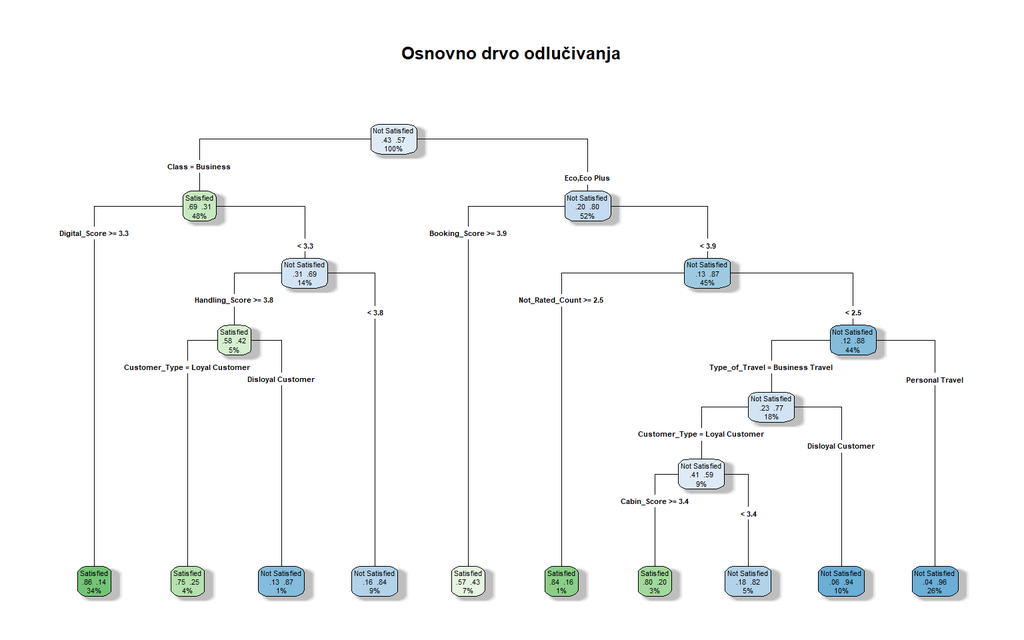

```r
rpart.plot(
  tree_model,
  type = 4,
  extra = 104,
  fallen.leaves = TRUE,
  box.palette = "GnBu",
  shadow.col = "gray",
  main = "Osnovno drvo odlučivanja"
)
```

## Evaluacija osnovnog stabla na test skupu

```r
tree_prob <- predict(
  tree_model,
  newdata = tree_test,
  type = "prob"
)[, "Satisfied"]

tree_evaluation <- evaluate_model(
  actual = tree_test$Satisfaction,
  prob_satisfied = tree_prob,
  model_name = "Drvo odlučivanja - osnovno"
)

tree_evaluation$metrics
```

```
##                        Model  Accuracy Precision    Recall        F1       AUC
## 1 Drvo odlučivanja - osnovno 0.8606845 0.8021121 0.9018253 0.8490511 0.9006914
```

```r
tree_evaluation$confusion
```

```
##                Predvideno
## Stvarno         Satisfied Not Satisfied
##   Satisfied         10178          1108
##   Not Satisfied      2511         12180
```

```r
tree_basic_evaluations <- lapply(names(tree_models), function(varijanta) {
  tree_prob <- predict(
    tree_models[[varijanta]],
    newdata = tree_datasets[[varijanta]]$test,
    type = "prob"
  )[, "Satisfied"]

  evaluate_model(
    actual = tree_datasets[[varijanta]]$test$Satisfaction,
    prob_satisfied = tree_prob,
    model_name = paste("Drvo odlučivanja - osnovno -", varijanta)
  )
})

tree_basic_metrics <- bind_rows(
  lapply(tree_basic_evaluations, `[[`, "metrics")
)

tree_basic_metrics
```

```
##                                                           Model  Accuracy
## 1                Drvo odlučivanja - osnovno - pojedinačne ocene 0.8853986
## 2                     Drvo odlučivanja - osnovno - zbirne ocene 0.8606845
## 3                 Drvo odlučivanja - osnovno - bez ocena usluga 0.7920083
## 4 Drvo odlučivanja - osnovno - zbirne ocene bez Not_Rated_Count 0.8367017
##   Precision    Recall        F1       AUC
## 1 0.8401703 0.9091795 0.8733138 0.9046591
## 2 0.8021121 0.9018253 0.8490511 0.9006914
## 3 0.7829726 0.7211590 0.7507956 0.7937575
## 4 0.8027334 0.8274854 0.8149215 0.8560006
```

```r
model_results <- model_results %>%
  filter(!grepl("^Drvo odlučivanja - osnovno", Model)) %>%
  bind_rows(tree_basic_metrics)

model_results
```

```
##                                                           Model  Accuracy
## 1                           Logistička regresija - zbirne ocene 0.8890557
## 2                      Logistička regresija - pojedinačne ocene 0.9084575
## 3                       Logistička regresija - bez ocena usluga 0.7883512
## 4       Logistička regresija - zbirne ocene bez Not_Rated_Count 0.8802402
## 5                Drvo odlučivanja - osnovno - pojedinačne ocene 0.8853986
## 6                     Drvo odlučivanja - osnovno - zbirne ocene 0.8606845
## 7                 Drvo odlučivanja - osnovno - bez ocena usluga 0.7920083
## 8 Drvo odlučivanja - osnovno - zbirne ocene bez Not_Rated_Count 0.8367017
##   Precision    Recall        F1       AUC
## 1 0.8881397 0.8519405 0.8696635 0.9545019
## 2 0.8981051 0.8903066 0.8941888 0.9693011
## 3 0.7519150 0.7653730 0.7585844 0.8489052
## 4 0.8821165 0.8360801 0.8584816 0.9466083
## 5 0.8401703 0.9091795 0.8733138 0.9046591
## 6 0.8021121 0.9018253 0.8490511 0.9006914
## 7 0.7829726 0.7211590 0.7507956 0.7937575
## 8 0.8027334 0.8274854 0.8149215 0.8560006
```

Za varijantu sa zbirnim ocenama i promenljivom `Not_Rated_Count`, osnovno stablo odlučivanja ostvarilo je tačnost od 86,07% na test skupu. Precision iznosi 80,21%, što znači da je među putnicima koje je model označio kao zadovoljne približno 80% zaista zadovoljno. Recall iznosi 90,18%, što pokazuje da model uspešno prepoznaje većinu zadovoljnih putnika. F1 mera iznosi 84,91%, dok AUC od 0,901 ukazuje na veoma dobru sposobnost modela da razlikuje zadovoljne od nezadovoljnih putnika.

Matrica konfuzije pokazuje da je model pravilno klasifikovao 10.178 zadovoljnih i 12.180 nezadovoljnih putnika. Pogrešno je klasifikovao 1.108 zadovoljnih putnika kao nezadovoljno i 2.511 nezadovoljnih putnika kao zadovoljno.

Najvažnija početna podela u stablu zasnovana je na promenljivoj `Class`. Kod putnika u poslovnoj klasi važnu ulogu imaju `Digital_Score` i `Handling_Score`, dok se kod putnika u klasama `Eco` i `Eco Plus` izdvajaju `Booking_Score`, `Not_Rated_Count`, `Type_of_Travel`, `Customer_Type` i `Cabin_Score`. Ovo pokazuje da se faktori povezani sa zadovoljstvom razlikuju između različitih grupa putnika.

Poređenje četiri varijante pokazuje da osnovno stablo najbolje rezultate ostvaruje sa pojedinačnim ocenama, za koje AUC iznosi 0,905. Zbirne ocene sa promenljivom `Not_Rated_Count` ostvaruju AUC od 0,901. Kada se koriste samo karakteristike putnika i leta, bez ocena usluga, AUC opada na 0,794. Izbacivanjem promenljive `Not_Rated_Count` iz varijante sa zbirnim ocenama AUC se smanjuje na 0,856. To potvrđuje da ocene usluga, kao i broj neocenjenih usluga, doprinose prediktivnoj moći stabla.

## Podešavanje stabla pomoću unakrsne validacije

Osnovno stablo je formirano sa početnom vrednošću parametra složenosti `cp = 0,01`. U ovom koraku ispitujemo više nivoa složenosti stabla pomoću petostruke unakrsne validacije. Cilj je da pronađemo model koji daje najmanju procenjenu grešku, bez nepotrebnog povećavanja složenosti.

```r
set.seed(123)

tree_cv_models <- cache_rds("../data/results/tree_cv_models.rds", {
  lapply(names(tree_datasets), function(varijanta) {
    set.seed(123)
    rpart(
      Satisfaction ~ .,
      data = tree_datasets[[varijanta]]$train,
      method = "class",
      control = rpart.control(
        cp = 0,
        minbucket = 20,
        xval = 5
      )
    )
  })
})

names(tree_cv_models) <- names(tree_datasets)

best_cps <- sapply(tree_cv_models, function(model) {
  cp_table <- as.data.frame(model$cptable)
  cp_table$CP[which.min(cp_table$xerror)]
})

best_cps
```

```
##                pojedinačne ocene                     zbirne ocene
##                     8.860928e-05                     7.753312e-05
##                 bez ocena usluga zbirne ocene bez Not_Rated_Count
##                     1.993709e-04                     8.122517e-05
```

```r
tuned_tree_models <- lapply(names(tree_cv_models), function(varijanta) {
  prune(
    tree_cv_models[[varijanta]],
    cp = best_cps[[varijanta]]
  )
})

names(tuned_tree_models) <- names(tree_cv_models)

# Glavno podešeno stablo ostaje varijanta:
# zbirne ocene + Not_Rated_Count
tuned_tree <- tuned_tree_models[["zbirne ocene"]]

tuned_tree
```

```
## n= 103903
##
## node), split, n, loss, yval, (yprob)
##       * denotes terminal node
##
##      1) root 103903 45142 Not Satisfied (0.434462913 0.565537087)
##        2) Class=Business 49747 15235 Satisfied (0.693750377 0.306249623)
##          4) Digital_Score>=3.25 34875  4926 Satisfied (0.858752688 0.141247312)
##            8) Cabin_Score>=3.125 29197  2248 Satisfied (0.923005788 0.076994212)
##             16) Type_of_Travel=Business Travel 28419  1593 Satisfied (0.943945952 0.056054048)
##               32) Customer_Type=Loyal Customer 26472   780 Satisfied (0.970534905 0.029465095)
##                 64) Handling_Score>=3.166667 22790   269 Satisfied (0.988196577 0.011803423) *
##                 65) Handling_Score< 3.166667 3682   511 Satisfied (0.861216730 0.138783270)
##                  130) Digital_Score>=4.25 1434     0 Satisfied (1.000000000 0.000000000) *
##                  131) Digital_Score< 4.25 2248   511 Satisfied (0.772686833 0.227313167)
##                    262) Cabin_Score>=3.375 1808   300 Satisfied (0.834070796 0.165929204)
##                      524) Cabin_Score>=4.125 390    14 Satisfied (0.964102564 0.035897436) *
##                      525) Cabin_Score< 4.125 1418   286 Satisfied (0.798307475 0.201692525)
##                       1050) Booking_Score>=4.875 177     0 Satisfied (1.000000000 0.000000000) *
##                       1051) Booking_Score< 4.875 1241   286 Satisfied (0.769540693 0.230459307)
##                         2102) Booking_Score< 4.125 1158   238 Satisfied (0.794473230 0.205526770)
##                           4204) Booking_Score< 1.125 178     2 Satisfied (0.988764045 0.011235955) *
##                           4205) Booking_Score>=1.125 980   236 Satisfied (0.759183673 0.240816327)
##                             8410) Booking_Score>=1.875 905   187 Satisfied (0.793370166 0.206629834)
##                              16820) Digital_Score>=3.75 542    76 Satisfied (0.859778598 0.140221402) *
##                              16821) Digital_Score< 3.75 363   111 Satisfied (0.694214876 0.305785124)
##                                33642) Age< 60.5 341    95 Satisfied (0.721407625 0.278592375) *
##                                33643) Age>=60.5 22     6 Not Satisfied (0.272727273 0.727272727) *
##                             8411) Booking_Score< 1.875 75    26 Not Satisfied (0.346666667 0.653333333) *
##                         2103) Booking_Score>=4.125 83    35 Not Satisfied (0.421686747 0.578313253)
##                           4206) Age>=34.5 56    23 Satisfied (0.589285714 0.410714286) *
##                           4207) Age< 34.5 27     2 Not Satisfied (0.074074074 0.925925926) *
##                    263) Cabin_Score< 3.375 440   211 Satisfied (0.520454545 0.479545455)
##                      526) Not_Rated_Count>=0.5 53     3 Satisfied (0.943396226 0.056603774) *
##                      527) Not_Rated_Count< 0.5 387   179 Not Satisfied (0.462532300 0.537467700)
##                       1054) Booking_Score>=4.875 29     0 Satisfied (1.000000000 0.000000000) *
##                       1055) Booking_Score< 4.875 358   150 Not Satisfied (0.418994413 0.581005587)
##                         2110) Digital_Score>=3.75 171    73 Satisfied (0.573099415 0.426900585)
##                           4220) Booking_Score< 1.125 20     0 Satisfied (1.000000000 0.000000000) *
##                           4221) Booking_Score>=1.125 151    73 Satisfied (0.516556291 0.483443709)
```

[output cut: 345 more lines]

```
##                    487) Digital_Score< 3.75 4547   396 Not Satisfied (0.087090389 0.912909611) *
##               61) Customer_Type=Disloyal Customer 10013   635 Not Satisfied (0.063417557 0.936582443)
##                122) Booking_Score>=3.291667 1543   390 Not Satisfied (0.252754375 0.747245625)
##                  244) Age< 24.5 780   300 Not Satisfied (0.384615385 0.615384615)
##                    488) Digital_Score>=4.25 136    39 Satisfied (0.713235294 0.286764706) *
##                    489) Digital_Score< 4.25 644   203 Not Satisfied (0.315217391 0.684782609)
##                      978) Not_Rated_Count>=0.5 158    75 Not Satisfied (0.474683544 0.525316456)
##                       1956) Digital_Score>=3.75 57    23 Satisfied (0.596491228 0.403508772) *
##                       1957) Digital_Score< 3.75 101    41 Not Satisfied (0.405940594 0.594059406)
##                         3914) Departure_Delay_in_Minutes>=11 24     9 Satisfied (0.625000000 0.375000000) *
##                         3915) Departure_Delay_in_Minutes< 11 77    26 Not Satisfied (0.337662338 0.662337662) *
##                      979) Not_Rated_Count< 0.5 486   128 Not Satisfied (0.263374486 0.736625514) *
##                  245) Age>=24.5 763    90 Not Satisfied (0.117955439 0.882044561) *
##                123) Booking_Score< 3.291667 8470   245 Not Satisfied (0.028925620 0.971074380) *
##             31) Type_of_Travel=Personal Travel 26600  1191 Not Satisfied (0.044774436 0.955225564) *
```

```r
variant_labels <- c(
  "pojedinačne ocene",
  "zbirne ocene",
  "bez ocena usluga",
  "zbirne ocene bez Not_Rated_Count"
)

tuned_tree_evaluations <- setNames(
  lapply(seq_along(tuned_tree_models), function(i) {
    varijanta <- names(tuned_tree_models)[i]

    tuned_tree_prob <- predict(
      tuned_tree_models[[varijanta]],
      newdata = tree_datasets[[varijanta]]$test,
      type = "prob"
    )[, "Satisfied"]

    evaluate_model(
      actual = tree_datasets[[varijanta]]$test$Satisfaction,
      prob_satisfied = tuned_tree_prob,
      model_name = paste(
        "Drvo odlučivanja - podešeno -",
        variant_labels[i]
      )
    )
  }),
  names(tuned_tree_models)
)

tuned_tree_metrics <- bind_rows(
  lapply(tuned_tree_evaluations, `[[`, "metrics")
)

tuned_tree_evaluation <- tuned_tree_evaluations[["zbirne ocene"]]

tuned_tree_evaluation$metrics
```

```
##                                        Model  Accuracy Precision    Recall
## 1 Drvo odlučivanja - podešeno - zbirne ocene 0.9221619 0.9304833 0.8871168
##          F1       AUC
## 1 0.9082827 0.9589752
```

```r
tuned_tree_evaluation$confusion
```

```
##                Predvideno
## Stvarno         Satisfied Not Satisfied
##   Satisfied         10012          1274
##   Not Satisfied       748         13943
```

```r
tuned_tree_metrics
```

```
##                                                            Model  Accuracy
## 1                Drvo odlučivanja - podešeno - pojedinačne ocene 0.9521115
## 2                     Drvo odlučivanja - podešeno - zbirne ocene 0.9221619
## 3                 Drvo odlučivanja - podešeno - bez ocena usluga 0.8031720
## 4 Drvo odlučivanja - podešeno - zbirne ocene bez Not_Rated_Count 0.9140393
##   Precision    Recall        F1       AUC
## 1 0.9610652 0.9273436 0.9439033 0.9890151
## 2 0.9304833 0.8871168 0.9082827 0.9589752
## 3 0.7703425 0.7792841 0.7747875 0.8552777
## 4 0.9210306 0.8773702 0.8986704 0.9502768
```

```r
model_results <- model_results %>%
  filter(!grepl("podeseno", Model)) %>%
  bind_rows(tuned_tree_metrics)

model_results %>%
  filter(grepl("Drvo", Model))
```

```
##                                                            Model  Accuracy
## 1                 Drvo odlučivanja - osnovno - pojedinačne ocene 0.8853986
## 2                      Drvo odlučivanja - osnovno - zbirne ocene 0.8606845
## 3                  Drvo odlučivanja - osnovno - bez ocena usluga 0.7920083
## 4  Drvo odlučivanja - osnovno - zbirne ocene bez Not_Rated_Count 0.8367017
## 5                Drvo odlučivanja - podešeno - pojedinačne ocene 0.9521115
## 6                     Drvo odlučivanja - podešeno - zbirne ocene 0.9221619
## 7                 Drvo odlučivanja - podešeno - bez ocena usluga 0.8031720
## 8 Drvo odlučivanja - podešeno - zbirne ocene bez Not_Rated_Count 0.9140393
##   Precision    Recall        F1       AUC
## 1 0.8401703 0.9091795 0.8733138 0.9046591
## 2 0.8021121 0.9018253 0.8490511 0.9006914
## 3 0.7829726 0.7211590 0.7507956 0.7937575
## 4 0.8027334 0.8274854 0.8149215 0.8560006
## 5 0.9610652 0.9273436 0.9439033 0.9890151
## 6 0.9304833 0.8871168 0.9082827 0.9589752
## 7 0.7703425 0.7792841 0.7747875 0.8552777
## 8 0.9210306 0.8773702 0.8986704 0.9502768
```

```r
tree_size <- data.frame(
  Varijanta = names(tuned_tree_models),
  Broj_listova = sapply(
    tuned_tree_models,
    function(model) sum(model$frame$var == "<leaf>")
  ),
  Broj_podela = sapply(
    tuned_tree_models,
    function(model) sum(model$frame$var != "<leaf>")
  )
)

tree_size
```

```
##                                                         Varijanta Broj_listova
## pojedinačne ocene                               pojedinačne ocene          177
## zbirne ocene                                         zbirne ocene          198
## bez ocena usluga                                 bez ocena usluga           47
## zbirne ocene bez Not_Rated_Count zbirne ocene bez Not_Rated_Count          211
##                                  Broj_podela
## pojedinačne ocene                        176
## zbirne ocene                             197
## bez ocena usluga                          46
## zbirne ocene bez Not_Rated_Count         210
```

```r
tuned_tree_metrics %>%
  mutate(across(where(is.numeric), ~ round(., 4)))
```

```
##                                                            Model Accuracy
## 1                Drvo odlučivanja - podešeno - pojedinačne ocene   0.9521
## 2                     Drvo odlučivanja - podešeno - zbirne ocene   0.9222
## 3                 Drvo odlučivanja - podešeno - bez ocena usluga   0.8032
## 4 Drvo odlučivanja - podešeno - zbirne ocene bez Not_Rated_Count   0.9140
##   Precision Recall     F1    AUC
## 1    0.9611 0.9273 0.9439 0.9890
## 2    0.9305 0.8871 0.9083 0.9590
## 3    0.7703 0.7793 0.7748 0.8553
## 4    0.9210 0.8774 0.8987 0.9503
```

Za varijantu sa zbirnim ocenama i promenljivom `Not_Rated_Count`, podešeno stablo ostvarilo je tačnost od 92,22% na test skupu. Precision iznosi 93,05%, recall 88,71%, F1 mera 90,83%, a AUC 0,959. U odnosu na osnovno stablo iste varijante, čija je tačnost iznosila 86,07%, podešeno stablo ostvaruje značajno bolje rezultate.

Matrica konfuzije pokazuje da je model pravilno klasifikovao 10.012 zadovoljnih i 13.943 nezadovoljna putnika. Pogrešno je klasifikovao 1.274 zadovoljna putnika kao nezadovoljna i 748 nezadovoljnih putnika kao zadovoljno.

Unakrsna validacija je za varijantu sa zbirnim ocenama i promenljivom `Not_Rated_Count` odabrala vrednost parametra složenosti `cp = 0,00007753`. Podešeno stablo je odabrano isključivo na osnovu unakrsne validacije na trening skupu, dok je test skup korišćen samo za konačnu procenu kvaliteta modela.

Poređenje četiri podešena stabla pokazuje da najbolje rezultate ostvaruje varijanta sa pojedinačnim ocenama: tačnost je 95,21%, F1 mera 94,39%, a AUC 0,989. Zbirne ocene sa `Not_Rated_Count` ostvaruju tačnost 92,22%, F1 meru 90,83% i AUC 0,959. Kod varijante bez ocena usluga AUC opada na 0,855, dok varijanta sa zbirnim ocenama bez `Not_Rated_Count` ostvaruje AUC 0,950. To pokazuje da ocene usluga imaju veliki značaj, a da izbacivanje `Not_Rated_Count` smanjuje performanse u odnosu na varijantu koja ga uključuje.

Tabela prikazuje broj listova i podela u svakom podešenom stablu. Stablo sa pojedinačnim ocenama ima 177 listova i 176 podela, dok stablo sa zbirnim ocenama ima 198 listova i 197 podela. Varijanta bez ocena usluga je znatno jednostavnija i ima 47 listova i 46 podela. Najveći broj listova ima stablo sa zbirnim ocenama bez promenljive Not_Rated_Count, sa 211 listova i 210 podela.

Pošto svaka interna podela stabla, uz početni čvor, daje jednu dodatnu završnu granu, broj podela je za jedan manji od broja listova. Male optimalne vrednosti parametra cp omogućile su složenija stabla, ali njihovu opravdanost treba procenjivati zajedno sa rezultatima na test skupu, a ne samo na osnovu broja listova.

## Važnost promenljivih u podešenom stablu

```r
tree_importance <- data.frame(
  Promenljiva = names(tuned_tree$variable.importance),
  Vaznost = as.numeric(tuned_tree$variable.importance)
) %>%
  arrange(desc(Vaznost)) %>%
  mutate(
    Relativna_vaznost = round(Vaznost / max(Vaznost) * 100, 2)
  )

tree_importance
```

```
##                   Promenljiva     Vaznost Relativna_vaznost
## 1                       Class 13038.76298            100.00
## 2               Digital_Score 11496.89046             88.17
## 3              Type_of_Travel  8520.01413             65.34
## 4                 Cabin_Score  8115.66557             62.24
## 5              Handling_Score  6757.82141             51.83
## 6             Flight_Distance  5793.55062             44.43
## 7               Booking_Score  4903.82171             37.61
## 8               Customer_Type  3434.53905             26.34
## 9             Not_Rated_Count  1833.19252             14.06
## 10                        Age  1421.96835             10.91
## 11 Departure_Delay_in_Minutes   108.17900              0.83
## 12           Delay_Difference    85.52596              0.66
## 13                     Gender    81.20092              0.62
```

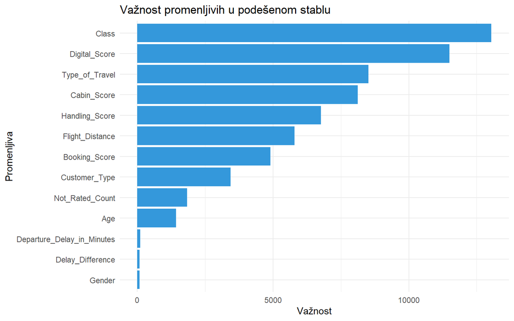

```r
ggplot(tree_importance, aes(
  x = reorder(Promenljiva, Vaznost),
  y = Vaznost
)) +
  geom_col(fill = "#3498db") +
  coord_flip() +
  theme_minimal() +
  labs(
    title = "Važnost promenljivih u podešenom stablu",
    x = "Promenljiva",
    y = "Važnost"
  )
```

Ovi rezultati ukazuju da klasa leta i kvalitet digitalnih usluga imaju najveći doprinos u razdvajanju zadovoljnih i nezadovoljnih putnika. Važni su i svrha putovanja, doživljaj kabine i osoblje tokom leta.

`Gender`, `Departure_Delay_in_Minutes` i `Delay_Difference` imaju veoma malu relativnu važnost, manju od 1%. To znači da u ovom modelu ove promenljive imaju mali doprinos predviđanju zadovoljstva u poređenju sa klasom leta i ocenama usluga.

Važnost promenljivih predstavlja doprinos smanjenju nečistoće u stablu i ne treba je tumačiti kao uzročni uticaj. Takođe, kod promenljivih koje su međusobno povezane, važnost može biti raspodeljena između više karakteristika.

# Random forest

Random forest je ansambl metoda koja kombinuje veliki broj stabala odlučivanja. Svako stablo se trenira na slučajnom uzorku podataka i koristi slučajan podskup promenljivih pri svakoj podeli. Kombinovanjem predikcija više stabala smanjuje se preprilagođavanje podacima i dobija se stabilniji model od pojedinačnog stabla.

## Osnovni random forest model

Za početni model koristićemo 100 stabala odlučivanja. Broj promenljivih koje se razmatraju pri svakoj podeli (`mtry`) ostavićemo na podrazumevanoj vrednosti, koju paket `randomForest` određuje za klasifikaciju. Koristićemo iste trening i test podatke kao kod podešenog stabla, kako bi poređenje modela bilo objektivno.

```r
rf_datasets <- tree_datasets

rf_models <- cache_rds("../data/results/rf_models.rds", {
  lapply(names(rf_datasets), function(varijanta) {
    set.seed(123)

    randomForest(
      Satisfaction ~ .,
      data = rf_datasets[[varijanta]]$train,
      ntree = 100,
      importance = TRUE
    )
  })
})

names(rf_models) <- names(rf_datasets)

rf_model <- rf_models[["zbirne ocene"]]

rf_train <- rf_datasets[["zbirne ocene"]]$train
rf_test  <- rf_datasets[["zbirne ocene"]]$test

rf_model
```

```
##
## Call:
##  randomForest(formula = Satisfaction ~ ., data = rf_datasets[[varijanta]]$train,      ntree = 100, importance = TRUE)
##                Type of random forest: classification
##                      Number of trees: 100
## No. of variables tried at each split: 3
##
##         OOB estimate of  error rate: 7.37%
## Confusion matrix:
##               Satisfied Not Satisfied class.error
## Satisfied         40628          4514  0.09999557
## Not Satisfied      3141         55620  0.05345382
```

## Evaluacija osnovnog random forest modela

```r
rf_variant_labels <- c(
  "pojedinačne ocene",
  "zbirne ocene",
  "bez ocena usluga",
  "zbirne ocene bez Not_Rated_Count"
)

rf_evaluations <- setNames(
  lapply(seq_along(rf_models), function(i) {
    varijanta <- names(rf_models)[i]

    rf_prob <- predict(
      rf_models[[varijanta]],
      newdata = rf_datasets[[varijanta]]$test,
      type = "prob"
    )[, "Satisfied"]

    evaluate_model(
      actual = rf_datasets[[varijanta]]$test$Satisfaction,
      prob_satisfied = rf_prob,
      model_name = paste(
        "Random forest - osnovni -",
        rf_variant_labels[i]
      )
    )
  }),
  names(rf_models)
)

rf_metrics <- bind_rows(
  lapply(rf_evaluations, `[[`, "metrics")
)

rf_evaluation <- rf_evaluations[["zbirne ocene"]]

rf_evaluation$metrics
```

```
##                                    Model  Accuracy Precision    Recall
## 1 Random forest - osnovni - zbirne ocene 0.9287062 0.9306976 0.9031544
##          F1       AUC
## 1 0.9167191 0.9755175
```

```r
rf_evaluation$confusion
```

```
##                Predvideno
## Stvarno         Satisfied Not Satisfied
##   Satisfied         10193          1093
##   Not Satisfied       759         13932
```

```r
rf_metrics
```

```
##                                                        Model  Accuracy
## 1                Random forest - osnovni - pojedinačne ocene 0.9612349
## 2                     Random forest - osnovni - zbirne ocene 0.9287062
## 3                 Random forest - osnovni - bez ocena usluga 0.8024406
## 4 Random forest - osnovni - zbirne ocene bez Not_Rated_Count 0.9183893
##   Precision    Recall        F1       AUC
## 1 0.9712111 0.9385965 0.9546253 0.9936000
## 2 0.9306976 0.9031544 0.9167191 0.9755175
## 3 0.7624979 0.7919546 0.7769471 0.8520514
## 4 0.9264843 0.8821549 0.9037763 0.9683980
```

```r
model_results <- model_results %>%
  filter(!grepl("^Random forest - osnovni", Model)) %>%
  bind_rows(rf_metrics)

model_results %>%
  filter(grepl("^Random forest - osnovni", Model))
```

```
##                                                        Model  Accuracy
## 1                Random forest - osnovni - pojedinačne ocene 0.9612349
## 2                     Random forest - osnovni - zbirne ocene 0.9287062
## 3                 Random forest - osnovni - bez ocena usluga 0.8024406
## 4 Random forest - osnovni - zbirne ocene bez Not_Rated_Count 0.9183893
##   Precision    Recall        F1       AUC
## 1 0.9712111 0.9385965 0.9546253 0.9936000
## 2 0.9306976 0.9031544 0.9167191 0.9755175
## 3 0.7624979 0.7919546 0.7769471 0.8520514
## 4 0.9264843 0.8821549 0.9037763 0.9683980
```

Osnovni random forest ostvario je tačnost od 92,87% na test skupu. Precision iznosi 93,07%, recall 90,32%, F1 mera 91,67%, a AUC 0,976. Ove vrednosti ukazuju na veoma dobru sposobnost modela da razlikuje zadovoljne od nezadovoljnih putnika.

Model je pravilno klasifikovao 10.193 zadovoljna i 13.932 nezadovoljna putnika. Pogrešno je klasifikovao 1.093 zadovoljna putnika kao nezadovoljna i 759 nezadovoljnih putnika kao zadovoljne.

OOB greška od 7,37% predstavlja internu procenu greške tokom treniranja random forest modela. Konačne metrike modela procenjuju se na test skupu, koji nije korišćen za treniranje modela.

U poređenju sa podešenim stablom odlučivanja, osnovni random forest ostvaruje veću tačnost (92,87% prema 92,22%), F1 meru (91,67% prema 90,83%) i AUC (0,976 prema 0,959). To pokazuje da kombinovanje većeg broja stabala daje bolje i stabilnije predikcije od jednog stabla odlučivanja.

## Važnost promenljivih u random forest modelu

```r
rf_importance <- data.frame(
  Promenljiva = rownames(importance(rf_model)),
  Vaznost = importance(rf_model)[, "MeanDecreaseAccuracy"]
) %>%
  arrange(desc(Vaznost)) %>%
  mutate(
    Relativna_vaznost = round(Vaznost / max(Vaznost) * 100, 2)
  )

rf_importance
```

```
##                                           Promenljiva   Vaznost
## Not_Rated_Count                       Not_Rated_Count 105.95215
## Handling_Score                         Handling_Score  99.47766
## Type_of_Travel                         Type_of_Travel  98.84779
## Digital_Score                           Digital_Score  95.58883
## Booking_Score                           Booking_Score  93.10365
## Customer_Type                           Customer_Type  92.89971
## Cabin_Score                               Cabin_Score  66.45735
## Age                                               Age  46.95750
## Class                                           Class  36.09436
## Departure_Delay_in_Minutes Departure_Delay_in_Minutes  30.02539
## Flight_Distance                       Flight_Distance  23.82590
## Delay_Difference                     Delay_Difference  22.94717
## Gender                                         Gender  19.59735
##                            Relativna_vaznost
## Not_Rated_Count                       100.00
## Handling_Score                         93.89
## Type_of_Travel                         93.29
## Digital_Score                          90.22
## Booking_Score                          87.87
## Customer_Type                          87.68
## Cabin_Score                            62.72
## Age                                    44.32
## Class                                  34.07
## Departure_Delay_in_Minutes             28.34
## Flight_Distance                        22.49
## Delay_Difference                       21.66
## Gender                                 18.50
```

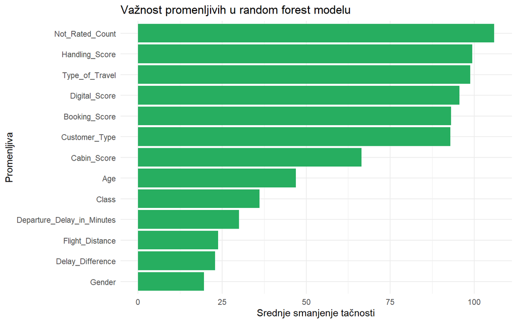

```r
ggplot(rf_importance, aes(
  x = reorder(Promenljiva, Vaznost),
  y = Vaznost
)) +
  geom_col(fill = "#27ae60") +
  coord_flip() +
  theme_minimal() +  labs(
    title = "Važnost promenljivih u random forest modelu",
    x = "Promenljiva",
    y = "Srednje smanjenje tačnosti"
  )
```

Ovi rezultati pokazuju da svrha putovanja, broj neocenjenih usluga i ocene osoblja i digitalnih usluga imaju najveći doprinos predviđanju zadovoljstva. `Gender` ima najmanju važnost, dok `Delay_Difference` i `Flight_Distance` imaju manji doprinos u poređenju sa navedenim promenljivama.

Rang važnosti se razlikuje od rangiranja kod pojedinačnog stabla. To je očekivano, jer random forest koristi veliki broj stabala i slučajne podskupove promenljivih. Važnost promenljive predstavlja prediktivni doprinos modelu, a ne dokaz da promenljiva uzročno utiče na zadovoljstvo.

## Podešavanje random forest modela

U ovom koraku za svaku od četiri varijante promenljivih ispitujemo različite vrednosti parametra `mtry`. Ovaj parametar određuje koliko se promenljivih razmatra pri svakoj podeli stabla. Najbolja vrednost bira se na osnovu najmanje OOB greške, koristeći isključivo trening skup. Test skup se ne koristi za izbor parametra.

```r
rf_tuning <- cache_rds("../data/results/rf_tuning.rds", {
  bind_rows(
    lapply(seq_along(rf_datasets), function(i) {
      rf_train_sub <- rf_datasets[[i]]$train
      mtry_values <- seq_len(ncol(rf_train_sub) - 1)

      set.seed(123)

      bind_rows(
        lapply(mtry_values, function(m) {
          model <- randomForest(
            Satisfaction ~ .,
            data = rf_train_sub,
            ntree = 100,
            mtry = m
          )

          data.frame(
            Varijanta = paste0("varijanta_", i),
            mtry = m,
            OOB_Error = model$err.rate[100, "OOB"]
          )
        })
      )
    })
  )
})

rf_tuning
```

```
##            Varijanta mtry  OOB_Error
## OOB...1  varijanta_1    1 0.06863132
## OOB...2  varijanta_1    2 0.04614881
## OOB...3  varijanta_1    3 0.04166386
## OOB...4  varijanta_1    4 0.04062443
## OOB...5  varijanta_1    5 0.04010471
## OOB...6  varijanta_1    6 0.03960425
## OOB...7  varijanta_1    7 0.03969087
## OOB...8  varijanta_1    8 0.03962349
## OOB...9  varijanta_1    9 0.03958500
## OOB...10 varijanta_1   10 0.03955612
## OOB...11 varijanta_1   11 0.03923852
## OOB...12 varijanta_1   12 0.03968124
## OOB...13 varijanta_1   13 0.03965237
## OOB...14 varijanta_1   14 0.03954650
## OOB...15 varijanta_1   15 0.03996997
## OOB...16 varijanta_1   16 0.03962349
## OOB...17 varijanta_1   17 0.03997960
## OOB...18 varijanta_1   18 0.04033570
## OOB...19 varijanta_1   19 0.04074955
## OOB...20 varijanta_1   20 0.04071105
## OOB...21 varijanta_1   21 0.04158686
## OOB...22 varijanta_1   22 0.04211620
## OOB...23 varijanta_2    1 0.10554074
## OOB...24 varijanta_2    2 0.07694677
## OOB...25 varijanta_2    3 0.07391509
## OOB...26 varijanta_2    4 0.07364561
## OOB...27 varijanta_2    5 0.07317402
## OOB...28 varijanta_2    6 0.07329913
## OOB...29 varijanta_2    7 0.07310665
## OOB...30 varijanta_2    8 0.07285641
## OOB...31 varijanta_2    9 0.07254843
## OOB...32 varijanta_2   10 0.07359749
## OOB...33 varijanta_2   11 0.07385735
## OOB...34 varijanta_2   12 0.07399209
## OOB...35 varijanta_2   13 0.07537800
## OOB...36 varijanta_3    1 0.21323735
## OOB...37 varijanta_3    2 0.19840621
## OOB...38 varijanta_3    3 0.19829071
## OOB...39 varijanta_3    4 0.20609607
## OOB...40 varijanta_3    5 0.21452701
## OOB...41 varijanta_3    6 0.22316006
## OOB...42 varijanta_3    7 0.22563352
## OOB...43 varijanta_3    8 0.22823210
## OOB...44 varijanta_4    1 0.11581956
## OOB...45 varijanta_4    2 0.08664812
## OOB...46 varijanta_4    3 0.08387631
## OOB...47 varijanta_4    4 0.08301012
## OOB...48 varijanta_4    5 0.08275988
## OOB...49 varijanta_4    6 0.08261552
## OOB...50 varijanta_4    7 0.08325072
## OOB...51 varijanta_4    8 0.08289462
## OOB...52 varijanta_4    9 0.08344321
## OOB...53 varijanta_4   10 0.08381856
## OOB...54 varijanta_4   11 0.08417466
## OOB...55 varijanta_4   12 0.08542583
```

```r
best_mtry <- sapply(
  split(rf_tuning, rf_tuning$Varijanta),
  function(rezultati) {
    rezultati$mtry[which.min(rezultati$OOB_Error)]
  }
)

best_mtry
```

```
## varijanta_1 varijanta_2 varijanta_3 varijanta_4
##          11           9           3           6
```

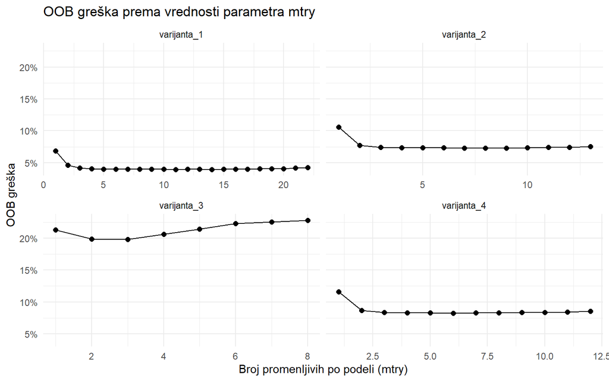

```r
ggplot(rf_tuning, aes(x = mtry, y = OOB_Error)) +
  geom_line() +
  geom_point(size = 2) +
  facet_wrap(~ Varijanta, scales = "free_x") +
  scale_y_continuous(labels = scales::percent_format()) +
  theme_minimal() +
  labs(
    title = "OOB greška prema vrednosti parametra mtry",
    x = "Broj promenljivih po podeli (mtry)",
    y = "OOB greška"
  )
```

Najmanja OOB greška za pojedinačne ocene ostvarena je pri mtry = 11 i iznosi 3,92%. Za zbirne ocene najbolja vrednost je mtry = 9, uz OOB grešku od 7,25%. Kod varijante bez ocena usluga najbolji rezultat daje mtry = 3, sa OOB greškom od 19,83%, dok je za zbirne ocene bez Not_Rated_Count najbolja vrednost mtry = 6, uz OOB grešku od 8,26%.

Optimalna vrednost parametra mtry zavisi od varijante skupa promenljivih. Varijanta sa pojedinačnim ocenama ostvaruje najmanju OOB grešku, dok varijanta bez ocena usluga ima najveću grešku. Uklanjanje promenljive Not_Rated_Count iz skupa zbirnih ocena povećava OOB grešku sa 7,25% na 8,26%.

## Završni podešeni random forest model

```r
tuned_rf_models <- cache_rds("../data/results/tuned_rf_models.rds", {
  setNames(
    lapply(seq_along(rf_datasets), function(i) {
      set.seed(123)

      randomForest(
        Satisfaction ~ .,
        data = rf_datasets[[i]]$train,
        ntree = 100,
        mtry = unname(best_mtry[i]),
        importance = TRUE
      )
    }),
    names(rf_datasets)
  )
})

tuned_rf_model <- tuned_rf_models[["zbirne ocene"]]

tuned_rf_models
```

```
## $`pojedinačne ocene`
##
## Call:
##  randomForest(formula = Satisfaction ~ ., data = rf_datasets[[i]]$train,      ntree = 100, mtry = unname(best_mtry[i]), importance = TRUE)
##                Type of random forest: classification
##                      Number of trees: 100
## No. of variables tried at each split: 11
##
##         OOB estimate of  error rate: 3.99%
## Confusion matrix:
##               Satisfied Not Satisfied class.error
## Satisfied         42414          2728  0.06043153
## Not Satisfied      1422         57339  0.02419972
##
## $`zbirne ocene`
##
## Call:
##  randomForest(formula = Satisfaction ~ ., data = rf_datasets[[i]]$train,      ntree = 100, mtry = unname(best_mtry[i]), importance = TRUE)
##                Type of random forest: classification
##                      Number of trees: 100
## No. of variables tried at each split: 9
##
##         OOB estimate of  error rate: 7.3%
## Confusion matrix:
##               Satisfied Not Satisfied class.error
## Satisfied         40547          4595  0.10178991
## Not Satisfied      2989         55772  0.05086707
##
## $`bez ocena usluga`
##
## Call:
##  randomForest(formula = Satisfaction ~ ., data = rf_datasets[[i]]$train,      ntree = 100, mtry = unname(best_mtry[i]), importance = TRUE)
##                Type of random forest: classification
##                      Number of trees: 100
## No. of variables tried at each split: 3
##
##         OOB estimate of  error rate: 19.87%
## Confusion matrix:
##               Satisfied Not Satisfied class.error
## Satisfied         35720          9422   0.2087192
## Not Satisfied     11226         47535   0.1910451
##
## $`zbirne ocene bez Not_Rated_Count`
##
## Call:
##  randomForest(formula = Satisfaction ~ ., data = rf_datasets[[i]]$train,      ntree = 100, mtry = unname(best_mtry[i]), importance = TRUE)
##                Type of random forest: classification
##                      Number of trees: 100
## No. of variables tried at each split: 6
##
##         OOB estimate of  error rate: 8.24%
## Confusion matrix:
##               Satisfied Not Satisfied class.error
## Satisfied         39743          5399  0.11960037
## Not Satisfied      3159         55602  0.05376015
```

```r
tuned_rf_evaluations <- setNames(
  lapply(seq_along(tuned_rf_models), function(i) {
    varijanta <- names(tuned_rf_models)[i]

    tuned_rf_prob <- predict(
      tuned_rf_models[[i]],
      newdata = rf_datasets[[varijanta]]$test,
      type = "prob"
    )[, "Satisfied"]

    evaluate_model(
      actual = rf_datasets[[varijanta]]$test$Satisfaction,
      prob_satisfied = tuned_rf_prob,
      model_name = paste(
        "Random forest - podešeni -",
        rf_variant_labels[i]
      )
    )
  }),
  names(tuned_rf_models)
)

tuned_rf_metrics <- bind_rows(
  lapply(tuned_rf_evaluations, `[[`, "metrics")
)

tuned_rf_evaluation <- tuned_rf_evaluations[["zbirne ocene"]]

tuned_rf_evaluation$metrics
```

```
##                                     Model  Accuracy Precision    Recall
## 1 Random forest - podešeni - zbirne ocene 0.9285522 0.9319348 0.9013822
##          F1       AUC
## 1 0.9164039 0.9762529
```

```r
tuned_rf_evaluation$confusion
```

```
##                Predvideno
## Stvarno         Satisfied Not Satisfied
##   Satisfied         10173          1113
##   Not Satisfied       743         13948
```

```r
tuned_rf_metrics
```

```
##                                                         Model  Accuracy
## 1                Random forest - podešeni - pojedinačne ocene 0.9620433
## 2                     Random forest - podešeni - zbirne ocene 0.9285522
## 3                 Random forest - podešeni - bez ocena usluga 0.8022096
## 4 Random forest - podešeni - zbirne ocene bez Not_Rated_Count 0.9193132
##   Precision    Recall        F1       AUC
## 1 0.9725638 0.9391281 0.9555536 0.9943746
## 2 0.9319348 0.9013822 0.9164039 0.9762529
## 3 0.7623762 0.7914230 0.7766281 0.8529409
## 4 0.9275214 0.8833068 0.9048743 0.9689688
```

```r
model_results <- model_results %>%
  filter(!grepl("^(Drvo|Random forest)", Model)) %>%
  bind_rows(
    tree_basic_metrics,
    tuned_tree_metrics,
    rf_metrics,
    tuned_rf_metrics
  )

model_results
```

```
##                                                             Model  Accuracy
## 1                             Logistička regresija - zbirne ocene 0.8890557
## 2                        Logistička regresija - pojedinačne ocene 0.9084575
## 3                         Logistička regresija - bez ocena usluga 0.7883512
## 4         Logistička regresija - zbirne ocene bez Not_Rated_Count 0.8802402
## 5                  Drvo odlučivanja - osnovno - pojedinačne ocene 0.8853986
## 6                       Drvo odlučivanja - osnovno - zbirne ocene 0.8606845
## 7                   Drvo odlučivanja - osnovno - bez ocena usluga 0.7920083
## 8   Drvo odlučivanja - osnovno - zbirne ocene bez Not_Rated_Count 0.8367017
## 9                 Drvo odlučivanja - podešeno - pojedinačne ocene 0.9521115
## 10                     Drvo odlučivanja - podešeno - zbirne ocene 0.9221619
## 11                 Drvo odlučivanja - podešeno - bez ocena usluga 0.8031720
## 12 Drvo odlučivanja - podešeno - zbirne ocene bez Not_Rated_Count 0.9140393
## 13                    Random forest - osnovni - pojedinačne ocene 0.9612349
## 14                         Random forest - osnovni - zbirne ocene 0.9287062
```

[output cut: 27 more lines]

Podešeni random forest modeli ostvarili su veoma dobre rezultate na test skupu. Najbolje performanse ima varijanta sa pojedinačnim ocenama, sa tačnošću od 96,20%, F1 merom od 95,56% i AUC vrednošću 0,994. Varijanta sa zbirnim ocenama ostvarila je tačnost od 92,86%, F1 meru od 91,64% i AUC od 0,976.

## Važnost promenljivih u podešenom random forest modelu

```r
tuned_rf_importance <- data.frame(
  Promenljiva = rownames(importance(tuned_rf_model)),
  Vaznost = importance(tuned_rf_model)[, "MeanDecreaseAccuracy"]
) %>%
  arrange(desc(Vaznost)) %>%
  mutate(
    Relativna_vaznost = round(Vaznost / max(Vaznost) * 100, 2)
  )

tuned_rf_importance
```

```
##                                           Promenljiva   Vaznost
## Type_of_Travel                         Type_of_Travel 231.27879
## Booking_Score                           Booking_Score 207.32964
## Digital_Score                           Digital_Score 181.55506
## Not_Rated_Count                       Not_Rated_Count 178.83709
## Handling_Score                         Handling_Score 174.04815
## Customer_Type                           Customer_Type 172.32784
## Cabin_Score                               Cabin_Score 113.60695
## Age                                               Age  66.65450
## Class                                           Class  55.90548
## Flight_Distance                       Flight_Distance  42.82686
## Departure_Delay_in_Minutes Departure_Delay_in_Minutes  28.88844
## Delay_Difference                     Delay_Difference  25.02163
## Gender                                         Gender  23.22664
##                            Relativna_vaznost
## Type_of_Travel                        100.00
## Booking_Score                          89.64
## Digital_Score                          78.50
## Not_Rated_Count                        77.33
## Handling_Score                         75.25
## Customer_Type                          74.51
## Cabin_Score                            49.12
## Age                                    28.82
## Class                                  24.17
## Flight_Distance                        18.52
## Departure_Delay_in_Minutes             12.49
## Delay_Difference                       10.82
## Gender                                 10.04
```

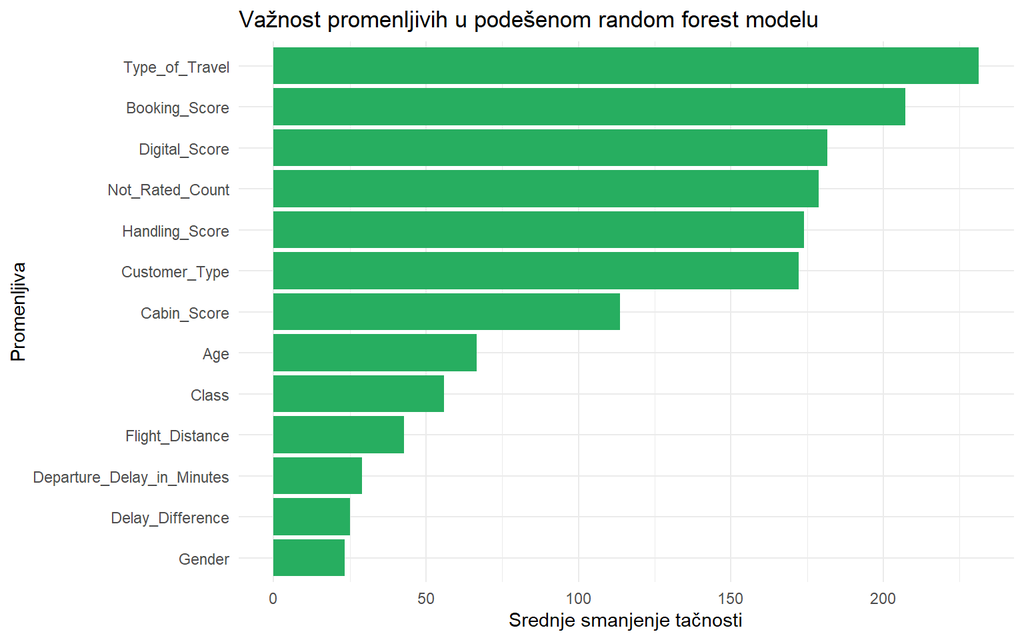

```r
ggplot(tuned_rf_importance, aes(
  x = reorder(Promenljiva, Vaznost),
  y = Vaznost
)) +
  geom_col(fill = "#27ae60") +
  coord_flip() +
  theme_minimal() +
  labs(
    title = "Važnost promenljivih u podešenom random forest modelu",
    x = "Promenljiva",
    y = "Srednje smanjenje tačnosti"
  )
```

U podešenom random forest modelu najvažnija promenljiva je Type_of_Travel, sa relativnom važnošću od 100%. Slede Booking_Score (89,64%), Digital_Score (78,50%), Not_Rated_Count (77,33%), Handling_Score (75,25%) i Customer_Type (74,51%).

Najmanju relativnu važnost imaju Gender (10,04%), Delay_Difference (10,82%) i Departure_Delay_in_Minutes (12,49%). Cabin_Score, Age, Class i Flight_Distance imaju umeren doprinos predviđanju zadovoljstva putnika.

Rezultati pokazuju da svrha putovanja, ocene rezervacije, digitalnih usluga i rukovanja, kao i broj neocenjenih usluga, imaju najveći prediktivni značaj u ovom modelu. Važnost promenljivih predstavlja njihov doprinos prediktivnoj tačnosti modela i ne dokazuje uzročno-posledični uticaj na zadovoljstvo putnika.

# Gradient Boosting

Gradient boosting je iterativna ansambl metoda koja sekvencijalno gradi stabla odlučivanja, pri čemu svako novo stablo uči na greškama (rezidualima) prethodnih stabala. Ova tehnika obično obezbeđuje visoku prediktivnu tačnost kombinovanjem većeg broja slabijih modela.

Za izgradnju modela koristićemo paket `gbm` (Generalized Boosted Regression Models). Kao ciljnu promenljivu u modelu primenjujemo numeričku verziju `Satisfied_Num` (1 = zadovoljan, 0 = nezadovoljan) uz binomnu raspodelu (`distribution = "bernoulli"`).

## Osnovni Gradient Boosting model

U ovom koraku treniramo osnovni model sa 300 stabala, dubinom interakcije (maksimalnim brojem čvorova po stablu) 4, i brzinom učenja (shrinkage) 0,05. Treniranje se vrši nad zajedničkim skupovima `train_data` i varijantom sa zbirnim ocenama `vars_scores`.

```r
set.seed(123)

gbm_train <- train_data %>%
  select(Satisfied_Num, all_of(vars_scores))

gbm_test <- test_data %>%
  select(Satisfied_Num, all_of(vars_scores))

gbm_model <- cache_rds("../data/results/gbm_base_model.rds", {
  set.seed(123)
  gbm(
    Satisfied_Num ~ .,
    data = gbm_train,
    distribution = "bernoulli",
    n.trees = 300,
    interaction.depth = 4,
    shrinkage = 0.05,
    bag.fraction = 0.8,
    train.fraction = 1.0,
    verbose = FALSE
  )
})

gbm_model
```

```
## gbm(formula = Satisfied_Num ~ ., distribution = "bernoulli",
##     data = gbm_train, n.trees = 300, interaction.depth = 4, shrinkage = 0.05,
##     bag.fraction = 0.8, train.fraction = 1, verbose = FALSE)
## A gradient boosted model with bernoulli loss function.
## 300 iterations were performed.
## There were 13 predictors of which 12 had non-zero influence.
```

## Evaluacija osnovnog Gradient Boosting modela

Predviđene verovatnoće dobijamo funkcijom `predict` uz navođenje broja stabala (`n.trees = 300`) i opcije `type = "response"`. Nakon toga, model evaluiramo na `test_data` skupu pomoću standardne funkcije `evaluate_model` i dodajemo rezultate u zajedničku tabelu `model_results`.

```r
gbm_prob <- predict(
  gbm_model,
  newdata = gbm_test,
  n.trees = 300,
  type = "response"
)

gbm_evaluation <- evaluate_model(
  actual = test_data$Satisfaction,
  prob_satisfied = gbm_prob,
  model_name = "Gradient boosting - osnovni - zbirne ocene"
)

# Prikaz metrika i matrice konfuzije
gbm_evaluation$metrics
```

```
##                                        Model Accuracy Precision   Recall
## 1 Gradient boosting - osnovni - zbirne ocene 0.917273 0.9250163 0.881003
##          F1       AUC
## 1 0.9024733 0.9707058
```

```r
gbm_evaluation$confusion
```

```
##                Predvideno
## Stvarno         Satisfied Not Satisfied
##   Satisfied          9943          1343
##   Not Satisfied       806         13885
```

```r
# Upis rezultata u zajedničku tabelu svih modela
if (nrow(model_results) > 0) {
  model_results <- filter(model_results, !grepl("^Gradient boosting", Model))
}
model_results <- bind_rows(model_results, gbm_evaluation$metrics)
```

Osnovni gradient boosting model ostvario je tačnost od 91,73%, F1 meru od 90,25% i AUC od 0,971 na test skupu. Model je pravilno klasifikovao 9.943 zadovoljna i 13.885 nezadovoljnih putnika. Pogrešno je klasifikovao 1.343 zadovoljna putnika kao nezadovoljna i 806 nezadovoljnih putnika kao zadovoljne.

Rezultati pokazuju veoma dobru sposobnost modela da razlikuje zadovoljne od nezadovoljnih putnika. U poređenju sa podešenim random forest modelom, osnovni gradient boosting ima nešto slabiju tačnost, F1 meru i AUC, ali i dalje ostvaruje visoke performanse.

## Podešavanje Gradient Boosting modela unakrsnom validacijom

```r
gbm_tuning <- expand.grid(
  interaction.depth = 2:6,
  shrinkage = c(0.05, 0.1)
)

gbm_tuning_results <- cache_rds("../data/results/gbm_tuning_results.rds", {
  res_list <- lapply(seq_len(nrow(gbm_tuning)), function(i) {
    params <- gbm_tuning[i, ]

    set.seed(123)

    model <- gbm(
      Satisfied_Num ~ .,
      data = gbm_train,
      distribution = "bernoulli",
      n.trees = 3000,
      interaction.depth = params$interaction.depth,
      shrinkage = params$shrinkage,
      bag.fraction = 0.8,
      train.fraction = 1.0,
      cv.folds = 5,
      verbose = FALSE
    )

    best_trees <- gbm.perf(
      model,
      method = "cv",
      plot.it = FALSE
    )

    data.frame(
      interaction.depth = params$interaction.depth,
      shrinkage = params$shrinkage,
      best_trees = best_trees,
      cv_error = min(model$cv.error)
    )
  })

  bind_rows(res_list)
})

gbm_tuning_results
```

```
##    interaction.depth shrinkage best_trees  cv_error
## 1                  2      0.05       3000 0.3963700
## 2                  3      0.05       3000 0.3716472
## 3                  4      0.05       3000 0.3628182
## 4                  5      0.05       3000 0.3582643
## 5                  6      0.05       3000 0.3553005
## 6                  2      0.10        585 0.4214274
## 7                  3      0.10       3000 0.3633486
## 8                  4      0.10       2999 0.3577038
## 9                  5      0.10       2881 0.3554572
## 10                 6      0.10       1211 0.3592280
```

```r
best_gbm <- gbm_tuning_results %>%
  arrange(cv_error) %>%
  slice(1)

best_gbm
```

```
##   interaction.depth shrinkage best_trees  cv_error
## 1                 6      0.05       3000 0.3553005
```

Najbolja kombinacija u sprovedenoj pretrazi ima dubinu interakcije 6 i shrinkage 0,05, uz najmanju procenjenu grešku 0,3553. Pošto je optimalan broj stabala dostigao gornju granicu pretrage od 3000, rezultat treba tumačiti oprezno.

## Završni podešeni Gradient Boosting model

Na osnovu unakrsne validacije za konačni model biramo dubinu interakcije 6, `shrinkage = 0,05` i 3000 stabala.

```r
best_depth <- best_gbm$interaction.depth[[1]]
best_shrinkage <- best_gbm$shrinkage[[1]]
best_n_trees <- best_gbm$best_trees[[1]]

tuned_gbm_model <- cache_rds("../data/results/tuned_gbm_model.rds", {
  set.seed(123)
  gbm(
    Satisfied_Num ~ .,
    data = gbm_train,
    distribution = "bernoulli",
    n.trees = best_n_trees,
    interaction.depth = best_depth,
    shrinkage = best_shrinkage,
    bag.fraction = 0.8,
    train.fraction = 1.0,
    verbose = FALSE
  )
})

tuned_gbm_prob <- predict(
  tuned_gbm_model,
  newdata = gbm_test,
  n.trees = best_n_trees,
  type = "response"
)

tuned_gbm_evaluation <- evaluate_model(
  actual = test_data$Satisfaction,
  prob_satisfied = tuned_gbm_prob,
  model_name = "Gradient boosting - podešeni - zbirne ocene"
)

tuned_gbm_evaluation$metrics
```

```
##                                         Model  Accuracy Precision    Recall
## 1 Gradient boosting - podešeni - zbirne ocene 0.9290526 0.9360857 0.8980152
##          F1      AUC
## 1 0.9166554 0.978566
```

```r
tuned_gbm_evaluation$confusion
```

```
##                Predvideno
## Stvarno         Satisfied Not Satisfied
##   Satisfied         10135          1151
##   Not Satisfied       692         13999
```

```r
model_results <- model_results %>%
  filter(!grepl("^Gradient boosting - podešeni", Model)) %>%
  bind_rows(tuned_gbm_evaluation$metrics)

model_results
```

```
##                                                             Model  Accuracy
## 1                             Logistička regresija - zbirne ocene 0.8890557
## 2                        Logistička regresija - pojedinačne ocene 0.9084575
## 3                         Logistička regresija - bez ocena usluga 0.7883512
## 4         Logistička regresija - zbirne ocene bez Not_Rated_Count 0.8802402
## 5                  Drvo odlučivanja - osnovno - pojedinačne ocene 0.8853986
## 6                       Drvo odlučivanja - osnovno - zbirne ocene 0.8606845
## 7                   Drvo odlučivanja - osnovno - bez ocena usluga 0.7920083
## 8   Drvo odlučivanja - osnovno - zbirne ocene bez Not_Rated_Count 0.8367017
## 9                 Drvo odlučivanja - podešeno - pojedinačne ocene 0.9521115
## 10                     Drvo odlučivanja - podešeno - zbirne ocene 0.9221619
## 11                 Drvo odlučivanja - podešeno - bez ocena usluga 0.8031720
## 12 Drvo odlučivanja - podešeno - zbirne ocene bez Not_Rated_Count 0.9140393
## 13                    Random forest - osnovni - pojedinačne ocene 0.9612349
## 14                         Random forest - osnovni - zbirne ocene 0.9287062
```

[output cut: 31 more lines]

Podešeni gradient boosting model ostvario je tačnost od 92,91%, precision 93,61%, recall 89,80%, F1 meru 91,67% i AUC 0,979. Model je pravilno klasifikovao 10.135 zadovoljnih i 13.999 nezadovoljnih putnika. Pogrešno je klasifikovao 1.151 zadovoljnih putnika kao nezadovoljne i 692 nezadovoljna putnika kao zadovoljne. U odnosu na osnovni gradient boosting model, podešavanje je poboljšalo sve glavne metrike.

## Podešeni GBM za ostale varijante promenljivih

```r
gbm_datasets <- list(
  "pojedinačne ocene" = list(
    train = train_data %>%
      select(Satisfied_Num, all_of(vars_individual)),
    test = test_data %>%
      select(Satisfied_Num, all_of(vars_individual))
  ),
  "bez ocena usluga" = list(
    train = train_data %>%
      select(Satisfied_Num, all_of(vars_no_ratings)),
    test = test_data %>%
      select(Satisfied_Num, all_of(vars_no_ratings))
  ),
  "zbirne ocene bez Not_Rated_Count" = list(
    train = train_data %>%
      select(Satisfied_Num, all_of(vars_scores_no_nrc)),
    test = test_data %>%
      select(Satisfied_Num, all_of(vars_scores_no_nrc))
  )
)

tuned_gbm_variants <- cache_rds("../data/results/tuned_gbm_variants.rds", {
  var_list <- lapply(names(gbm_datasets), function(varijanta) {
    set.seed(123)

    model <- gbm(
      Satisfied_Num ~ .,
      data = gbm_datasets[[varijanta]]$train,
      distribution = "bernoulli",
      n.trees = best_n_trees,
      interaction.depth = best_depth,
      shrinkage = best_shrinkage,
      bag.fraction = 0.8,
      train.fraction = 1.0,
      verbose = FALSE
    )

    prob <- predict(
      model,
      newdata = gbm_datasets[[varijanta]]$test,
      n.trees = best_n_trees,
      type = "response"
    )

    evaluate_model(
      actual = test_data$Satisfaction,
      prob_satisfied = prob,
      model_name = paste("Gradient boosting - podešeni -", varijanta)
    )
  })

  names(var_list) <- names(gbm_datasets)
  var_list
})

tuned_gbm_variant_metrics <- bind_rows(
  lapply(tuned_gbm_variants, `[[`, "metrics")
)

tuned_gbm_variant_metrics
```

```
##                                                             Model  Accuracy
## 1                Gradient boosting - podešeni - pojedinacne ocene 0.9621588
## 2                 Gradient boosting - podešeni - bez ocena usluga 0.8044424
## 3 Gradient boosting - podešeni - zbirne ocene bez Not_Rated_Count 0.9203911
##   Precision    Recall        F1       AUC
## 1 0.9709297 0.9410774 0.9557705 0.9945832
## 2 0.7675000 0.7888534 0.7780302 0.8695567
## 3 0.9302651 0.8829523 0.9059915 0.9724486
```

Podešeni GBM modeli pokazuju najbolje rezultate kada se koriste pojedinačne ocene usluga. Tačnost iznosi 96,22%, F1 mera 95,58%, a AUC 0,995.

Varijanta sa zbirnim ocenama ostvaruje tačnost od 92,91%, F1 meru 91,67% i AUC 0,979, dok varijanta sa zbirnim ocenama bez Not_Rated_Count ima nešto slabije rezultate: tačnost 92,04%, F1 meru 90,60% i AUC 0,972.

Najslabije rezultate ostvaruje model bez ocena usluga, sa tačnošću 80,44%, F1 merom 77,80% i AUC vrednošću 0,870. Rezultati potvrđuju da ocene usluga nose najveći deo prediktivne informacije, dok Not_Rated_Count dodatno poboljšava rezultate kod zbirnih ocena.

```r
model_results <- model_results %>%
  filter(!grepl("^(Drvo|Random forest|Gradient boosting)", Model)) %>%
  bind_rows(
    tree_basic_metrics,
    tuned_tree_metrics,
    rf_metrics,
    tuned_rf_metrics,
    gbm_evaluation$metrics,
    tuned_gbm_evaluation$metrics,
    tuned_gbm_variant_metrics
  )

model_results_sorted <- model_results %>%
  arrange(desc(AUC)) %>%
  mutate(across(where(is.numeric), ~ round(., 4)))

model_results_sorted
```

```
##                                                              Model Accuracy
## 1                 Gradient boosting - podešeni - pojedinacne ocene   0.9622
## 2                     Random forest - podešeni - pojedinačne ocene   0.9620
## 3                      Random forest - osnovni - pojedinačne ocene   0.9612
## 4                  Drvo odlučivanja - podešeno - pojedinačne ocene   0.9521
## 5                      Gradient boosting - podešeni - zbirne ocene   0.9291
## 6                          Random forest - podešeni - zbirne ocene   0.9286
## 7                           Random forest - osnovni - zbirne ocene   0.9287
## 8  Gradient boosting - podešeni - zbirne ocene bez Not_Rated_Count   0.9204
## 9                       Gradient boosting - osnovni - zbirne ocene   0.9173
## 10                        Logistička regresija - pojedinačne ocene   0.9085
## 11     Random forest - podešeni - zbirne ocene bez Not_Rated_Count   0.9193
## 12      Random forest - osnovni - zbirne ocene bez Not_Rated_Count   0.9184
## 13                      Drvo odlučivanja - podešeno - zbirne ocene   0.9222
## 14                             Logistička regresija - zbirne ocene   0.8891
```

[output cut: 37 more lines]

## Važnost promenljivih u Gradient Boosting modelu

Funkcija `summary.gbm` računa relativni uticaj (relative influence) svake promenljive na osnovu smanjenja devijacije pri podelama u stablima.

```r
gbm_importance <- summary(
  tuned_gbm_model,
  n.trees = best_n_trees,
  plotit = FALSE
)

gbm_importance <- gbm_importance %>%
  rename(Promenljiva = var, Vaznost = rel.inf) %>%
  mutate(Relativna_vaznost = round(Vaznost, 2))

head(gbm_importance, 10)
```

```
##                     Promenljiva    Vaznost Relativna_vaznost
## Digital_Score     Digital_Score 24.5915536             24.59
## Type_of_Travel   Type_of_Travel 18.1589699             18.16
## Class                     Class 15.3161184             15.32
## Booking_Score     Booking_Score 11.1443203             11.14
## Cabin_Score         Cabin_Score  8.0962008              8.10
## Customer_Type     Customer_Type  7.8277764              7.83
## Handling_Score   Handling_Score  7.7744884              7.77
## Not_Rated_Count Not_Rated_Count  4.3572182              4.36
## Age                         Age  1.0714246              1.07
## Flight_Distance Flight_Distance  0.8113309              0.81
```

Da bismo jasnije sagledali doprinos svake promenljive, prikazaćemo grafikon relativnog uticaja.

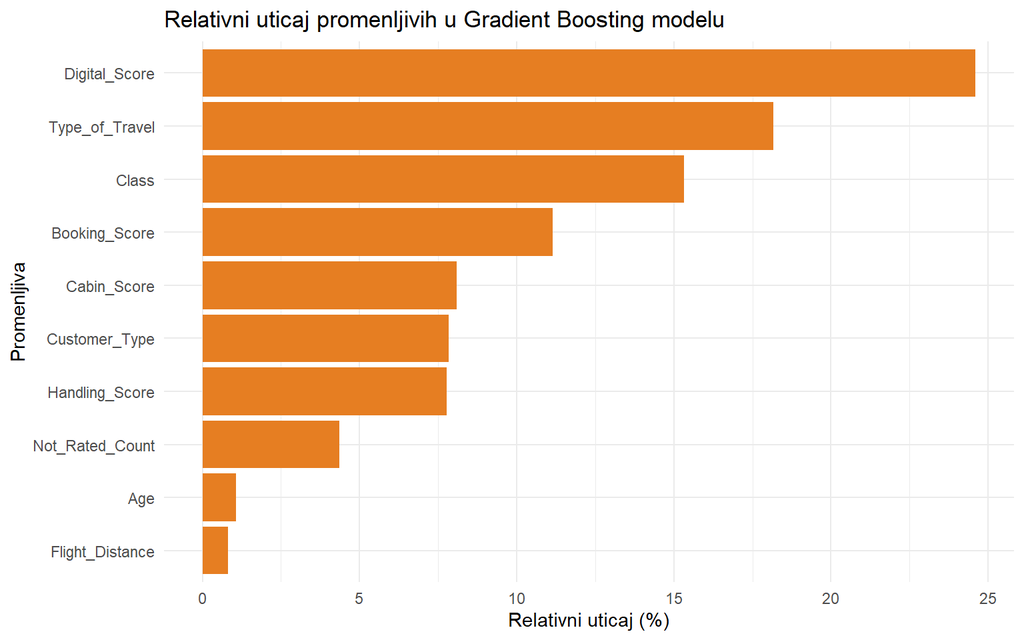

```r
ggplot(head(gbm_importance, 10), aes(
  x = reorder(Promenljiva, Vaznost),
  y = Vaznost
)) +
  geom_col(fill = "#e67e22") +
  coord_flip() +
  theme_minimal() +
  labs(
    title = "Relativni uticaj promenljivih u Gradient Boosting modelu",
    x = "Promenljiva",
    y = "Relativni uticaj (%)"
  )
```

Prema relativnom uticaju, najvažnija promenljiva u podešenom gradient boosting modelu je Digital_Score, sa relativnim uticajem od 24,59%. Slede Type_of_Travel sa 18,16%, Class sa 15,32% i Booking_Score sa 11,14%. Značajan doprinos imaju i Cabin_Score, Customer_Type i Handling_Score, dok Not_Rated_Count ima manji, ali primetan uticaj od 4,36%.

Ovi rezultati pokazuju da digitalne usluge, svrha i klasa putovanja, kao i ocene organizacije i kabine, nose najveći deo prediktivne informacije. Relativna važnost opisuje doprinos predviđanju u ovom modelu i ne predstavlja dokaz uzročno-posledične veze.

```r
importance_table <- bind_rows(
  tree_importance %>%
    transmute(
      Model = "Podešeno stablo",
      Promenljiva,
      Vaznost = Relativna_vaznost
    ),
  tuned_rf_importance %>%
    transmute(
      Model = "Podešeni random forest",
      Promenljiva,
      Vaznost = Relativna_vaznost
    ),
  gbm_importance %>%
    transmute(
      Model = "Podešeni GBM",
      Promenljiva,
      Vaznost = Relativna_vaznost
    ),
  vaznost %>%
    transmute(
      Model = "Logistička regresija",
      Promenljiva = Grupa,
      Vaznost = Porast_AIC
    )
) %>%
  arrange(Model, desc(Vaznost))

importance_table
```

```
##                                                  Model
## ...1                              Logistička regresija
## ...2                              Logistička regresija
## ...3                              Logistička regresija
## ...4                              Logistička regresija
## ...5                              Logistička regresija
## ...6                              Logistička regresija
## ...7                              Logistička regresija
## ...8                              Logistička regresija
## ...9                              Logistička regresija
## ...10                             Logistička regresija
## ...11                             Logistička regresija
## ...12                             Logistička regresija
## Digital_Score...13                        Podešeni GBM
## Type_of_Travel...14                       Podešeni GBM
## Class...15                                Podešeni GBM
## Booking_Score...16                        Podešeni GBM
## Cabin_Score...17                          Podešeni GBM
## Customer_Type...18                        Podešeni GBM
## Handling_Score...19                       Podešeni GBM
## Not_Rated_Count...20                      Podešeni GBM
## Age...21                                  Podešeni GBM
## Flight_Distance...22                      Podešeni GBM
## Departure_Delay_in_Minutes...23           Podešeni GBM
## Delay_Difference...24                     Podešeni GBM
## Gender...25                               Podešeni GBM
## Type_of_Travel...26             Podešeni random forest
## Booking_Score...27              Podešeni random forest
## Digital_Score...28              Podešeni random forest
## Not_Rated_Count...29            Podešeni random forest
## Handling_Score...30             Podešeni random forest
## Customer_Type...31              Podešeni random forest
## Cabin_Score...32                Podešeni random forest
## Age...33                        Podešeni random forest
## Class...34                      Podešeni random forest
## Flight_Distance...35            Podešeni random forest
## Departure_Delay_in_Minutes...36 Podešeni random forest
## Delay_Difference...37           Podešeni random forest
## Gender...38                     Podešeni random forest
## ...39                                  Podešeno stablo
```

[output cut: 49 more lines]

```
## Delay_Difference...37                               Delay_Difference    10.82
## Gender...38                                                   Gender    10.04
## ...39                                                          Class   100.00
## ...40                                                  Digital_Score    88.17
## ...41                                                 Type_of_Travel    65.34
## ...42                                                    Cabin_Score    62.24
## ...43                                                 Handling_Score    51.83
## ...44                                                Flight_Distance    44.43
## ...45                                                  Booking_Score    37.61
## ...46                                                  Customer_Type    26.34
## ...47                                                Not_Rated_Count    14.06
## ...48                                                            Age    10.91
## ...49                                     Departure_Delay_in_Minutes     0.83
## ...50                                               Delay_Difference     0.66
## ...51                                                         Gender     0.62
```

Objedinjena tabela prikazuje važnost promenljivih prema četiri različita kriterijuma. Kod podešenog stabla, random foresta i GBM-a važnost predstavlja relativni doprinos promenljive predikciji, dok je kod logističke regresije prikazan porast AIC-a nakon izbacivanja odgovarajuće grupe promenljivih. Zbog različitih skala, vrednosti se ne porede direktno između modela, već se analiziraju rangovi promenljivih unutar svakog modela.

Digital_Score, Type_of_Travel, Class, Booking_Score i Handling_Score pojavljuju se među važnijim promenljivama u više modela. To pokazuje da digitalne usluge, svrha i klasa putovanja, kao i kvalitet usluga, imaju stabilan prediktivni značaj. Not_Rated_Count je posebno važan u random forestu i logističkoj regresiji, dok je njegov doprinos u GBM-u i podešenom stablu manji.

Negativan porast AIC-a kod promenljivih Gender i Flight_Distance u logističkoj regresiji znači da njihovo izbacivanje nije pogoršalo AIC u konačnom modelu. Važnost promenljivih predstavlja prediktivni ili modelni doprinos, a ne dokazuje uzročno-posledični uticaj.

# Poređenje modela

U cilju sveobuhvatne evaluacije, sve verzije izgrađenih modela (logistička regresija, stabla odlučivanja, random forest i gradient boosting) upoređene su na istom test skupu. U nastavku je prikazana objedinjena tabela modela sortirana po vrednosti AUC metrike, kao i vizuelni poređenje tačnosti i AUC-a po modelima i varijantama skupa promenljivih.

```r
# Prikaz objedinjene tabele rezultata sortirane po AUC opadajuće
model_results_sorted <- model_results %>%
  arrange(desc(AUC)) %>%
  mutate(across(where(is.numeric), ~ round(., 4)))

model_results_sorted
```

```
##                                                              Model Accuracy
## 1                 Gradient boosting - podešeni - pojedinacne ocene   0.9622
## 2                     Random forest - podešeni - pojedinačne ocene   0.9620
## 3                      Random forest - osnovni - pojedinačne ocene   0.9612
## 4                  Drvo odlučivanja - podešeno - pojedinačne ocene   0.9521
## 5                      Gradient boosting - podešeni - zbirne ocene   0.9291
## 6                          Random forest - podešeni - zbirne ocene   0.9286
## 7                           Random forest - osnovni - zbirne ocene   0.9287
## 8  Gradient boosting - podešeni - zbirne ocene bez Not_Rated_Count   0.9204
## 9                       Gradient boosting - osnovni - zbirne ocene   0.9173
## 10                        Logistička regresija - pojedinačne ocene   0.9085
## 11     Random forest - podešeni - zbirne ocene bez Not_Rated_Count   0.9193
## 12      Random forest - osnovni - zbirne ocene bez Not_Rated_Count   0.9184
## 13                      Drvo odlučivanja - podešeno - zbirne ocene   0.9222
## 14                             Logistička regresija - zbirne ocene   0.8891
```

[output cut: 37 more lines]

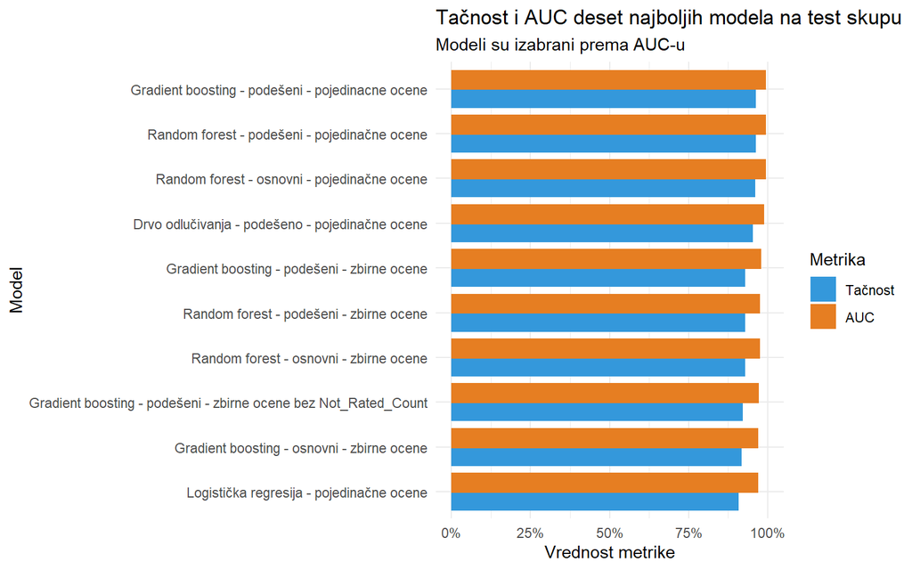

```r
# Vizuelno poređenje modela prema AUC metrici
top_models <- model_results %>%
  arrange(desc(AUC)) %>%
  slice_head(n = 10) %>%
  mutate(Model = forcats::fct_reorder(Model, AUC)) %>%
  select(Model, Accuracy, AUC) %>%
  pivot_longer(
    cols = c(Accuracy, AUC),
    names_to = "Metrika",
    values_to = "Vrednost"
  )

ggplot(top_models, aes(x = Model, y = Vrednost, fill = Metrika)) +
  geom_col(position = position_dodge(width = 0.8)) +
  coord_flip() +
  scale_y_continuous(
    limits = c(0, 1),
    labels = scales::percent_format()
  ) +
  scale_fill_manual(
    values = c("Accuracy" = "#3498db", "AUC" = "#e67e22"),
    labels = c("Accuracy" = "Tačnost", "AUC" = "AUC")
  ) +
  theme_minimal() +
  labs(
    title = "Tačnost i AUC deset najboljih modela na test skupu",
    subtitle = "Modeli su izabrani prema AUC-u",
    x = "Model",
    y = "Vrednost metrike",
    fill = "Metrika"
  )
```

Najbolje rezultate na test skupu ostvaruju modeli sa pojedinačnim ocenama usluga. Podešeni gradient boosting postiže tačnost 0,9622 i AUC 0,9946; podešeni random forest je vrlo blizu, sa tačnošću 0,9620 i AUC-om 0,9944, a osnovni random forest postiže 0,9612 i 0,9936. Razlike između prva tri modela su male.

Kod varijante sa zbirnim ocenama najbolji je podešeni gradient boosting (tačnost 0,9291; AUC 0,9786), dok su podešeni i osnovni random forest takođe slični (tačnost 0,9286 i 0,9287; AUC 0,9763 i 0,9755). U svim porodicama modela varijante sa ocenama nadmašuju one bez ocena. Uklanjanje Not_Rated_Count iz varijante sa zbirnim ocenama uglavnom snižava AUC: na primer, kod podešenog GBM-a sa 0,9786 na 0,9724.

Modeli bez ocena usluga imaju slabije rezultate. Najbolji je podešeni gradient boosting, sa tačnošću 0,8044 i AUC-om 0,8696. Ovi rezultati pokazuju da su ocene usluga veoma informativne za predviđanje zadovoljstva u ovom skupu, ali ne dokazuju uzročno-posledičnu vezu.

# Model za produkciju

U ovom poglavlju izabrani model pretvaramo u alat koji se može koristiti na novim putnicima. Najbolje rezultate imao je podešeni gradient boosting sa pojedinačnim ocenama usluga (AUC 0,995), pa ga koristimo kao produkcioni model. Postupak ima tri dela: funkcija koja iz sirovih podataka jednog putnika pravi iste promenljive na kojima je model treniran, finalni model sačuvan u fajlu i funkcija koja za novog putnika vraća verovatnoću zadovoljstva.

## Priprema podataka za novog putnika

Funkcija `prepare_passenger()` prima podatke u istom obliku kao originalni skup (imena kolona sa donjim crtama, ocene od 0 do 5, kašnjenje u minutima) i obavlja iste korake kao čišćenje podataka i feature engineering: postavlja nivoe kategorijskih promenljivih, računa razliku kašnjenja (`Delay_Difference`) i broj neocenjenih usluga (`Not_Rated_Count`). Ako kašnjenje pri dolasku nije uneto, koristi se kašnjenje pri polasku, isto kao kod nedostajućih vrednosti u analizi.

```r
rating_cols <- c("Inflight_wifi_service", "Departure_Arrival_time_convenient",
                 "Ease_of_Online_booking", "Gate_location", "Food_and_drink",
                 "Online_boarding", "Seat_comfort", "Inflight_entertainment",
                 "On_board_service", "Leg_room_service", "Baggage_handling",
                 "Checkin_service", "Cleanliness")

raw_cols <- c("Gender", "Customer_Type", "Age", "Type_of_Travel", "Class",
              "Flight_Distance", rating_cols, "Departure_Delay_in_Minutes")

prepare_passenger <- function(x) {
  x <- as.data.frame(x)

  fali <- setdiff(raw_cols, names(x))
  if (length(fali) > 0) stop("Nedostaju kolone: ", paste(fali, collapse = ", "))

  # Ocene moraju biti 0-5 (0 = usluga nije ocenjena)
  if (any(!as.matrix(x[, rating_cols]) %in% 0:5))
    stop("Ocene usluga moraju biti celi brojevi od 0 do 5.")

  # Kašnjenje pri dolasku je opcionalno; ako fali, zamenjuje se
  # kašnjenjem pri polasku
  if (!"Arrival_Delay_in_Minutes" %in% names(x)) x$Arrival_Delay_in_Minutes <- NA_real_
  arrival <- ifelse(is.na(x$Arrival_Delay_in_Minutes),
                    x$Departure_Delay_in_Minutes,
                    x$Arrival_Delay_in_Minutes)

  out <- data.frame(
    Gender         = factor(x$Gender, levels = c("Female", "Male")),
    Customer_Type  = factor(x$Customer_Type, levels = c("Disloyal Customer", "Loyal Customer")),
    Type_of_Travel = factor(x$Type_of_Travel, levels = c("Business Travel", "Personal Travel")),
    Class          = factor(x$Class, levels = c("Eco", "Business", "Eco Plus")),
    Age                        = as.integer(x$Age),
    Flight_Distance            = as.integer(x$Flight_Distance),
    Departure_Delay_in_Minutes = as.integer(x$Departure_Delay_in_Minutes),
    Delay_Difference           = arrival - x$Departure_Delay_in_Minutes
  )

  # Ocene i broj neocenjenih usluga
  for (kol in rating_cols) out[[kol]] <- as.integer(x[[kol]])
  out$Not_Rated_Count <- as.numeric(rowSums(x[, rating_cols] == 0))

  # Upozorenje za putnike sa neocenjenim uslugama
  if (any(out$Not_Rated_Count > 0))
    warning("Neki putnici imaju neocenjene usluge (ocena 0). Model je veoma osetljiv na takve slučajeve, pa rezultat tumačiti oprezno.")

  # Nepoznata kategorija postala bi NA, pa ne dozvoljavamo da prođe nezapaženo
  if (anyNA(out[, c("Gender", "Customer_Type", "Type_of_Travel", "Class")]))
    stop("Nepoznata vrednost u Gender / Customer_Type / Type_of_Travel / Class.")

  out
}
```

Funkciju proveravamo tako što iz prvih 2000 redova trening skupa rekonstruišemo sirove podatke, propustimo ih kroz funkciju i uporedimo sa originalnim promenljivama.

```r
ulaz <- as.data.frame(train_data[1:2000, ])
ulaz$Arrival_Delay_in_Minutes <- ulaz$Departure_Delay_in_Minutes + ulaz$Delay_Difference
ulaz <- ulaz[, c(raw_cols, "Arrival_Delay_in_Minutes")]   # samo sirove kolone

izlaz <- suppressWarnings(prepare_passenger(ulaz))

ocekivano <- as.data.frame(train_data[1:2000, names(izlaz)])
all.equal(izlaz, ocekivano)
```

```
## [1] TRUE
```

Provera na 2000 redova iz trening skupa pokazuje da se rekonstruisani podaci potpuno poklapaju sa originalnim, pa se novi putnici pripremaju na isti način kao podaci na kojima je model treniran.

## Finalni model

Za produkciju koristimo gradient boosting sa pojedinačnim ocenama usluga i parametrima izabranim unakrsnom validacijom (3000 stabala, dubina 6, shrinkage 0,05). Model se trenira na trening skupu i čuva u fajlu, pa se u daljem radu učitava bez ponovnog treniranja.

```r
set.seed(123)
dir.create("../model", showWarnings = FALSE)
putanja_modela <- "../model/gbm_produkcija.rds"

prod_train <- as.data.frame(gbm_datasets[["pojedinačne ocene"]]$train)
prod_test  <- as.data.frame(gbm_datasets[["pojedinačne ocene"]]$test)

# Ako je model već sačuvan, učitava se; inače se trenira (traje nekoliko minuta) i čuva
if (file.exists(putanja_modela)) {
  prod_model <- readRDS(putanja_modela)
} else {
  prod_model <- gbm(
    Satisfied_Num ~ .,
    distribution      = "bernoulli",
    data              = prod_train,
    n.trees           = 3000,
    interaction.depth = 6,
    shrinkage         = 0.05,
    bag.fraction      = 0.8,
    train.fraction    = 1,
    keep.data         = FALSE,
    verbose           = FALSE
  )
  saveRDS(prod_model, putanja_modela)
}

# Provera na test skupu
prob <- predict(prod_model, newdata = prod_test, n.trees = 3000, type = "response")
y    <- prod_test$Satisfied_Num

tacnost <- mean((prob > 0.5) == (y == 1))

r  <- rank(prob)
n1 <- sum(y == 1)
n0 <- sum(y == 0)
auc <- (sum(r[y == 1]) - n1 * (n1 + 1) / 2) / (n1 * n0)

round(c(Accuracy = tacnost, AUC = auc), 4)
```

```
## Accuracy      AUC
##   0.9622   0.9946
```

Na test skupu finalni model postiže tačnost 0,962 i AUC 0,995, što se poklapa sa rezultatom iz poglavlja Poređenje modela. Model je treniran samo na trening skupu, jer bi dodavanje test podataka onemogućilo proveru ovakvih rezultata.

Treba imati u vidu da su ocene usluga i zadovoljstvo prikupljeni u istoj anketi. Zato model procenjuje zadovoljstvo putnika na osnovu već popunjene ankete, a ne predviđa ga unapred.

## Predviđanje za nove putnike

Funkcija `predict_satisfaction()` prima sirove podatke putnika, priprema ih funkcijom `prepare_passenger()` i vraća verovatnoću zadovoljstva i klasu (prag je 0,5). Ispod je primer sa tri izmišljena putnika i provera da funkcija prijavljuje pogrešan unos.

```r
predict_satisfaction <- function(x, model = NULL, prag = 0.5) {
  if (is.null(model)) model <- readRDS("../model/gbm_produkcija.rds")

  podaci <- prepare_passenger(x)
  prob   <- predict(model, newdata = podaci, n.trees = model$n.trees, type = "response")

  data.frame(
    Verovatnoca_zadovoljstva = round(prob, 3),
    Predikcija = factor(ifelse(prob > prag, "Satisfied", "Not Satisfied"),
                        levels = c("Satisfied", "Not Satisfied"))
  )
}

novi_putnici <- data.frame(
  Gender                            = c("Female", "Male", "Male"),
  Customer_Type                     = c("Loyal Customer", "Disloyal Customer", "Loyal Customer"),
  Age                               = c(45, 22, 60),
  Type_of_Travel                    = c("Business Travel", "Personal Travel", "Business Travel"),
  Class                             = c("Business", "Eco", "Eco Plus"),
  Flight_Distance                   = c(1800, 400, 900),
  Inflight_wifi_service             = c(4, 2, 0),
  Departure_Arrival_time_convenient = c(4, 3, 3),
  Ease_of_Online_booking            = c(4, 2, 0),
  Gate_location                     = c(3, 3, 3),
  Food_and_drink                    = c(5, 2, 3),
  Online_boarding                   = c(5, 1, 3),
  Seat_comfort                      = c(5, 2, 3),
  Inflight_entertainment            = c(5, 2, 3),
  On_board_service                  = c(5, 2, 3),
  Leg_room_service                  = c(4, 2, 3),
  Baggage_handling                  = c(5, 3, 3),
  Checkin_service                   = c(4, 2, 3),
  Cleanliness                       = c(5, 2, 3),
  Departure_Delay_in_Minutes        = c(0, 60, 10)
)

cbind(novi_putnici[, c("Customer_Type", "Type_of_Travel", "Class")],
      predict_satisfaction(novi_putnici, model = prod_model))
```

```
##       Customer_Type  Type_of_Travel    Class Verovatnoca_zadovoljstva
## 1    Loyal Customer Business Travel Business                    0.997
## 2 Disloyal Customer Personal Travel      Eco                    0.000
## 3    Loyal Customer Business Travel Eco Plus                    1.000
##      Predikcija
## 1     Satisfied
## 2 Not Satisfied
## 3     Satisfied
```

```r
# Provera da funkcija prijavljuje pogrešan unos
neispravan <- novi_putnici[1, ]
neispravan$Class <- "Premium"
try(predict_satisfaction(neispravan, model = prod_model))
```

```
## Error in prepare_passenger(x) :
##   Nepoznata vrednost u Gender / Customer_Type / Type_of_Travel / Class.
```

Na tri izmišljena putnika model daje očekivane predikcije. Putnik na poslovnom putovanju sa visokim ocenama dobija verovatnoću zadovoljstva 0,997, a putnik na ličnom putovanju sa niskim ocenama i kašnjenjem od sat vremena oko 0. Funkcija takođe prijavljuje grešku kada se unese nepoznata vrednost kategorijske promenljive, na primer nepostojeća klasa putovanja.

Treći putnik ima dve neocenjene usluge. Da bismo videli koliko to utiče na predviđanje, upoređujemo istog putnika sa nulama i sa nulama zamenjenim neutralnom ocenom 3.

```r
p3 <- novi_putnici[3, ]
p3_ocenjen <- p3
p3_ocenjen[, rating_cols][p3_ocenjen[, rating_cols] == 0] <- 3

rbind(
  "sa dve neocenjene usluge" = suppressWarnings(predict_satisfaction(p3, model = prod_model)),
  "sve usluge ocenjene (3)"  = predict_satisfaction(p3_ocenjen, model = prod_model)
)
```

```
##                          Verovatnoca_zadovoljstva    Predikcija
## sa dve neocenjene usluge                     1.00     Satisfied
## sve usluge ocenjene (3)                      0.05 Not Satisfied
```

Provera na trećem putniku pokazuje da na predviđanje presudno utiče broj neocenjenih usluga. Isti putnik sa dve neocenjene usluge (ocena 0) dobija verovatnoću zadovoljstva oko 1, a kada se nule zamene neutralnom ocenom 3, verovatnoća pada na oko 0,05. Model je ovaj obrazac naučio iz podataka, gde je nedostatak ocene povezan sa zadovoljstvom, ali to ne znači da neocenjena usluga uzrokuje zadovoljstvo. U praksi nulu treba unositi samo kada putnik stvarno nije ocenio uslugu, a predikcije za takve putnike treba tumačiti oprezno.

## Procena pre ankete: model bez ocena usluga

Pored glavnog modela, pripremamo i model koji ne koristi ocene usluga, nego samo podatke o putniku i letu (pol, tip korisnika, svrha putovanja, klasa, starost, dužina leta i kašnjenje). Ovakav model može da se koristi i pre nego što putnik popuni anketu, ali je znatno slabiji, pa njegove procene treba tumačiti kao grubu orijentaciju. Trenira se na isti način i sa istim parametrima kao glavni model.

```r
set.seed(123)
putanja_modela_bez <- "../model/gbm_produkcija_bez_ocena.rds"

bez_train <- as.data.frame(gbm_datasets[["bez ocena usluga"]]$train)
bez_test  <- as.data.frame(gbm_datasets[["bez ocena usluga"]]$test)

if (file.exists(putanja_modela_bez)) {
  prod_model_bez <- readRDS(putanja_modela_bez)
} else {
  prod_model_bez <- gbm(
    Satisfied_Num ~ .,
    distribution      = "bernoulli",
    data              = bez_train,
    n.trees           = 3000,
    interaction.depth = 6,
    shrinkage         = 0.05,
    bag.fraction      = 0.8,
    train.fraction    = 1,
    keep.data         = FALSE,
    verbose           = FALSE
  )
  saveRDS(prod_model_bez, putanja_modela_bez)
}

# Provera na test skupu
prob_bez <- predict(prod_model_bez, newdata = bez_test, n.trees = 3000, type = "response")
y_bez    <- bez_test$Satisfied_Num

tacnost_bez <- mean((prob_bez > 0.5) == (y_bez == 1))

r_bez  <- rank(prob_bez)
n1_bez <- sum(y_bez == 1)
n0_bez <- sum(y_bez == 0)
auc_bez <- (sum(r_bez[y_bez == 1]) - n1_bez * (n1_bez + 1) / 2) / (n1_bez * n0_bez)

round(c(Accuracy = tacnost_bez, AUC = auc_bez), 4)
```

```
## Accuracy      AUC
##   0.8044   0.8696
```

Model bez ocena usluga postiže tačnost 0,804 i AUC 0,870, što se poklapa sa rezultatom iz poglavlja Poređenje modela. Ovo je znatno slabije nego kod modela sa pojedinačnim ocenama (tačnost 0,962), što je očekivano, jer su ocene usluga najinformativniji deo podataka. Zato ovaj model treba koristiti kao grubu procenu pre ankete, a ne kao zamenu za glavni model. Za ovaj model ocene nisu potrebne, pa funkcija za predviđanje ocene ne traži. Ako ih korisnik ipak unese, ignorišu se.

```r
predict_satisfaction_bez_ocena <- function(x, model = NULL, prag = 0.5) {
  if (is.null(model)) model <- readRDS("../model/gbm_produkcija_bez_ocena.rds")

  x <- as.data.frame(x)
  # prepare_passenger() traži ocene; za ovaj model se ne koriste, pa ih popunjavamo
  # neutralnom vrednošću, a zatim zadržavamo samo promenljive koje model koristi
  for (kol in rating_cols) if (!kol %in% names(x)) x[[kol]] <- 3
  podaci <- suppressWarnings(prepare_passenger(x))[, model$var.names]

  prob <- predict(model, newdata = podaci, n.trees = model$n.trees, type = "response")

  data.frame(
    Verovatnoca_zadovoljstva = round(prob, 3),
    Predikcija = factor(ifelse(prob > prag, "Satisfied", "Not Satisfied"),
                        levels = c("Satisfied", "Not Satisfied"))
  )
}

# Isti putnici kao ranije, ali bez ocena usluga
putnici_bez_ocena <- novi_putnici[, c("Gender", "Customer_Type", "Age", "Type_of_Travel",
                                      "Class", "Flight_Distance", "Departure_Delay_in_Minutes")]

cbind(putnici_bez_ocena[, c("Customer_Type", "Type_of_Travel", "Class")],
      predict_satisfaction_bez_ocena(putnici_bez_ocena, model = prod_model_bez))
```

```
##       Customer_Type  Type_of_Travel    Class Verovatnoca_zadovoljstva
## 1    Loyal Customer Business Travel Business                    0.882
## 2 Disloyal Customer Personal Travel      Eco                    0.083
## 3    Loyal Customer Business Travel Eco Plus                    0.348
##      Predikcija
## 1     Satisfied
## 2 Not Satisfied
## 3 Not Satisfied
```

Za iste tri izmišljene putnike model bez ocena daje manje izražene verovatnoće nego glavni model. Putnik na poslovnom putovanju u biznis klasi dobija 0,882, a putnik na ličnom putovanju u ekonomskoj klasi 0,083. Putnik sa poslovnim putovanjem u Eco Plus klasi dobija 0,348 i klasifikuje se kao nezadovoljan, iako ga je glavni model, na osnovu ocena, svrstao u zadovoljne. To pokazuje da podaci o putniku i letu sami po sebi ne određuju zadovoljstvo i da se rezultat ovog modela mora tumačiti oprezno.

## Korišćenje modela i ograničenja

Za produkcionu upotrebu sačuvana su dva trenirana `gbm` modela u direktorijumu `model/`: glavni model `gbm_produkcija.rds` (sa pojedinačnim ocenama usluga) i pomoćni model `gbm_produkcija_bez_ocena.rds` (samo sa podacima o putniku i letu, za procenu pre ankete). Modeli se mogu koristiti samostalno bez pokretanja celog `.Rmd` izveštaja preko skripte `produkcija.R`, u kojoj se podaci pripremaju funkcijom `prepare_passenger()`, a predikcije dobijaju pozivom funkcija `predict_satisfaction()` i `predict_satisfaction_bez_ocena()`. Ulazni podaci se prosleđuju kao `data.frame` sa nazivima kolona razdvojenim donjim crtama, ocenama usluga kao celim brojevima od `0` do `5` (gde `0` označava da usluga nije ocenjena) i kašnjenjem u minutima, pri čemu su obavezne kolone `Gender`, `Customer_Type`, `Age`, `Type_of_Travel`, `Class`, `Flight_Distance`, `Departure_Delay_in_Minutes` i svih 13 kolona ocena usluga, dok je `Arrival_Delay_in_Minutes` opcionalna i zamenjuje se kašnjenjem pri polasku ako nedostaje. Pošto su ocene usluga i zadovoljstvo prikupljeni u istoj anketi, glavni model procenjuje zadovoljstvo na osnovu već popunjene ankete, dok model bez ocena služi samo za grubu orijentaciju pre ankete. Dodatno, glavni model je veoma osetljiv na vrednost `0` (`Not_Rated_Count`), pa nulu treba unositi samo kada usluga zaista nije ocenjena i takve predikcije tumačiti uz oprez.

## Zaključak projekta

Analizom skupa od 129.880 putnika ispitani su demografski podaci, karakteristike letova i ocene usluga povezane sa zadovoljstvom. Nedostajuće vrednosti kašnjenja pri dolasku popunjene su kašnjenjem pri polasku, a feature engineering-om su izvedeni broj neocenjenih usluga, razlika kašnjenja i zbirne ocene usluga. Analize ukazuju na povezanost zadovoljstva sa svrhom i klasom putovanja, lojalnošću korisnika i ocenama usluga, ali same po sebi ne dokazuju uzročno-posledične veze.

Najbolje rezultate na test skupu ostvarili su modeli sa pojedinačnim ocenama usluga: podešeni GBM je postigao tačnost 0,9622 i AUC 0,9946, a podešeni random forest tačnost 0,9620 i AUC 0,9944. Model bez ocena usluga bio je znatno slabiji, što pokazuje da su ocene važne za predviđanje u ovom skupu, ali ograničava korišćenje glavnog modela pre popunjavanja ankete.

Rezultate treba tumačiti uz nekoliko ograničenja. Ocene usluga i zadovoljstvo prikupljeni su u istoj anketi, pa glavni model procenjuje zadovoljstvo na osnovu već datih ocena. Broj neocenjenih usluga takođe je povezan sa predikcijom; ocena 0 označava neocenjenu uslugu, a ne najnižu ocenu. Pored toga, EDA i PCA sprovedeni su pre podele na trening i test skup, pa je test skup mogao uticati na istraživački izbor obeležja i zbirnih ocena. Zato rezultate treba posmatrati kao početnu procenu, a u nastavku PCA i izbor obeležja sprovesti samo na trening podacima, pa potvrditi performanse na nezavisnim podacima.